# Paper-plots

# 40 Fig 5D GR-ChiP DEA

```r
df <- readRDS("objects/GR_ChIP_DEA.DF.rds")
GR_ChIP.df <- df
```

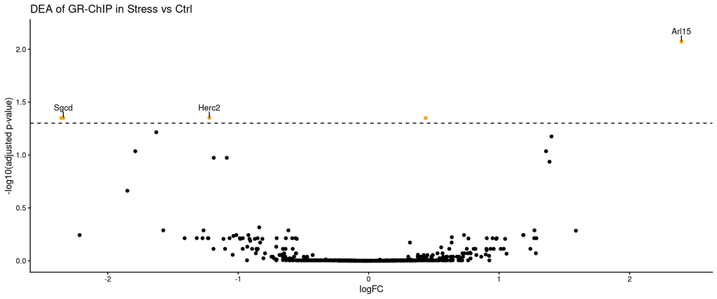

```r
library(scales)


xlim <- c(-7, 7)
ylim <- c(0,6)

# Function to generate volcano plots
generate_volcano_plot <- function(df, title) {
  df$highlight <- df$FDR < 0.05
  # df$extreme[df$logFC > xlim[2] | df$logFC < xlim[1] | -log10(df$FDR) > ylim[2] | -log10(df$FDR) < ylim[1]] <- "extreme"
  df$highlight[df$extreme == "extreme"] <- "extreme"
  top_genes <- df[df$FDR < 0.05,]
  ggplot(df, aes(x=logFC, y=-log10(FDR))) +
    geom_point(aes(color = highlight)) +
    scale_color_manual(values = c("TRUE" = "orange", "FALSE" = "black")) +
    geom_text_repel(data = subset(top_genes, highlight == TRUE ), aes(label=GeneAnno), size=3.5, min.segment.length = 0, max.overlaps = Inf, nudge_y = 0.1) +
    geom_hline(yintercept=-log10(0.05), linetype="dashed")+
    xlab("logFC") +
    ylab("-log10(adjusted p-value)") +
    theme_classic() +
    theme(legend.position="none") +
    ggtitle(title)
}

# Apply the function to each dataframe in the list
generate_volcano_plot(df, "DEA of GR-ChIP in Stress vs Ctrl")
```

```r
ggsave("plots/Fig5D_DEAs_GRChIP_volcano.svg")
ggsave("plots/Fig5D_DEAs_GRChIP_volcano.pdf")
ggsave("plots/Fig5D_DEAs_GRChIP_volcano.png")
```

# 41 Fig 5E Sgcd tracks

load necessary data

```r
 ensdb <- ah[["AH89457"]]
```

```r
bw <- list.files(path = "intern_data/ChIP/",pattern = "*.bw$",full.names = T)
names(bw) <- basename(bw)
```

```r
bw_groups <- list(Stress = bw[c(7:10)], Ctrl = bw[c(1:4)], Input = bw[c(5:6)])
```

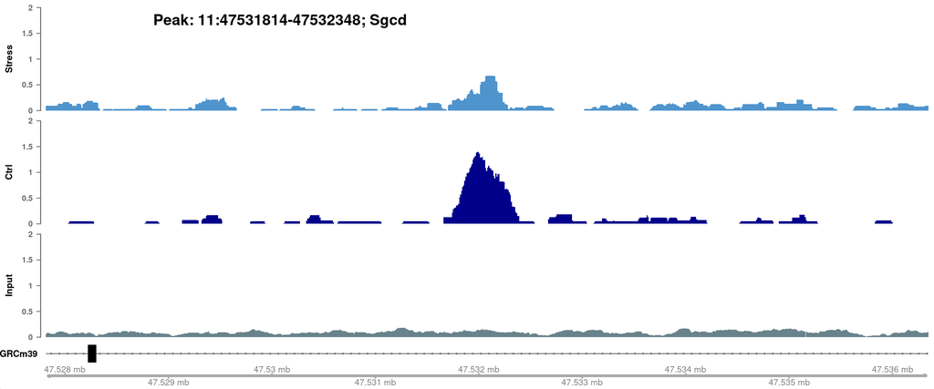

```r
plotSignalTracks(files = bw_groups,overlay.alpha = 75,region = "11:47531814-47532348",aggregation = "mean",colors = c("steelblue3","blue4","lightblue4"),genomeAxis = T,ensdb = ensdb,extend = c(4000,4000),ylim= c(0,2), fontface.main = 1,cex.main = 1,cex.id=0.9,cex.title = 0.7) # , rotation.title = 0
grid.text(paste0("Peak: 11:47531814-47532348","; ","Sgcd"), x = 0.3, y = 0.95, gp = gpar(fontsize = 14, fontface = "bold"))
```

```r
png(paste0("plots/Fig5E_Sgcd.png"), width=750, height=512)
plotSignalTracks(files = bw_groups,overlay.alpha = 75,region = "11:47531814-47532348",aggregation = "mean",colors = c("steelblue3","blue4","lightblue4"),genomeAxis = T,ensdb = ensdb,extend = c(4000,4000),ylim= c(0,2), fontface.main = 1.4,cex.main = 0.9,cex.id=0.9,cex.title = 0.9) # , rotation.title = 0
grid.text(paste0("Peak: 11:47531814-47532348","; ","Sgcd"), x = 0.5, y = 0.95, gp = gpar(fontsize = 15, fontface = "bold"))
dev.off()
```

```r
pdf(paste0("plots/Fig5E_Sgcd.pdf"), width=8, height=7,colormodel = "cymk")
plotSignalTracks(files = bw_groups,overlay.alpha = 75,region = "11:47531814-47532348",aggregation = "mean",colors = c("steelblue3","blue4","lightblue4"),genomeAxis = T,ensdb = ensdb,extend = c(4000,4000),ylim= c(0,2), fontface.main = 1.4,cex.main = 0.9,cex.id=0.9,cex.title = 0.9) # , rotation.title = 0
grid.text(paste0("Peak: 11:47531814-47532348","; ","Sgcd"), x = 0.5, y = 0.95, gp = gpar(fontsize = 15, fontface = "bold"))
dev.off()
```

```r
svg(paste0("plots/Fig5E_Sgcd.svg"), width=8, height=7)
plotSignalTracks(files = bw_groups,overlay.alpha = 75,region = "11:47531814-47532348",aggregation = "mean",colors = c("steelblue3","blue4","lightblue4"),genomeAxis = T,ensdb = ensdb,extend = c(4000,4000),ylim= c(0,2), fontface.main = 1.4,cex.main = 0.9,cex.id=0.9,cex.title = 0.9) # , rotation.title = 0
grid.text(paste0("Peak: 11:47531814-47532348","; ","Sgcd"), x = 0.5, y = 0.95, gp = gpar(fontsize = 15, fontface = "bold"))
dev.off()
```

## 41.1 adding GR cut n tag

```r
bw_groups <- list("Sperm\nStress" = bw[c(7:10)], "Sperm\nCtrl" = bw[c(1:4)], "Embryo\nStress" = bw_GR_full[3:4], "Embryo\nCtrl" = bw_GR_full[1:2])
```

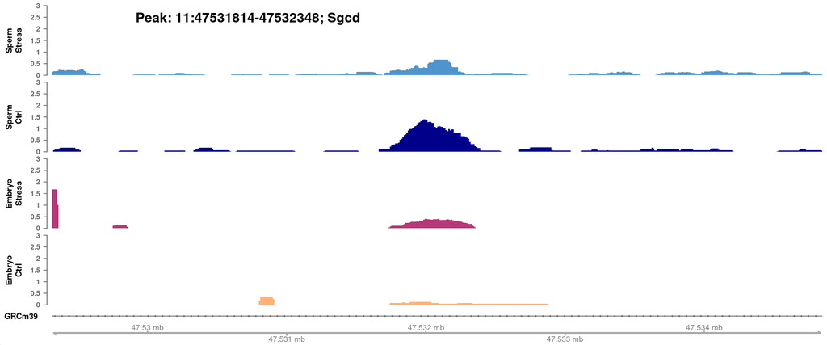

```r
plotSignalTracks(files = bw_groups,overlay.alpha = 75,region = "11:47531814-47532348",aggregation = "mean",colors = c("steelblue3","blue4","#B83779FF","#FEB27AFF"),genomeAxis = T,ensdb = ensdb,extend = c(2500,2500),ylim= c(0,3), fontface.main = 1,cex.main = 1,cex.id=0.9,cex.title = 0.7) # , rotation.title = 0
grid.text(paste0("Peak: 11:47531814-47532348","; ","Sgcd"), x = 0.3, y = 0.95, gp = gpar(fontsize = 14, fontface = "bold"))
```

```r
png(paste0("plots/Fig5E2_Sgcd.png"), width=750, height=512)
plotSignalTracks(files = bw_groups[3:4],overlay.alpha = 75,region = "11:47531814-47532348",aggregation = "mean",colors = c("steelblue3","blue4","#B83779FF","#FEB27AFF")[3:4],genomeAxis = T,ensdb = ensdb,extend = c(2500,2500),ylim= c(0,3), fontface.main = 1.4,cex.main = 0.9,cex.id=0.9,cex.title = 0.9) # , rotation.title = 0
grid.text(paste0("Peak: 11:47531814-47532348","; ","Sgcd"), x = 0.5, y = 0.95, gp = gpar(fontsize = 15, fontface = "bold"))
dev.off()
```

```r
pdf(paste0("plots/Fig5E2_Sgcd.pdf"), width=8, height=7,colormodel = "cymk")
plotSignalTracks(files = bw_groups[3:4],overlay.alpha = 75,region = "11:47531814-47532348",aggregation = "mean",colors = c("steelblue3","blue4","#B83779FF","#FEB27AFF")[3:4],genomeAxis = T,ensdb = ensdb,extend = c(2500,2500),ylim= c(0,3), fontface.main = 1.4,cex.main = 0.9,cex.id=0.9,cex.title = 0.9) # , rotation.title = 0
grid.text(paste0("Peak: 11:47531814-47532348","; ","Sgcd"), x = 0.5, y = 0.95, gp = gpar(fontsize = 15, fontface = "bold"))
dev.off()
```

```r
svg(paste0("plots/Fig5E2_Sgcd.svg"), width=8, height=7)
plotSignalTracks(files = bw_groups[3:4],overlay.alpha = 75,region = "11:47531814-47532348",aggregation = "mean",colors = c("steelblue3","blue4","#B83779FF","#FEB27AFF")[3:4],genomeAxis = T,ensdb = ensdb,extend = c(2500,2500),ylim= c(0,3), fontface.main = 1.4,cex.main = 0.9,cex.id=0.9,cex.title = 0.9) # , rotation.title = 0
grid.text(paste0("Peak: 11:47531814-47532348","; ","Sgcd"), x = 0.5, y = 0.95, gp = gpar(fontsize = 15, fontface = "bold"))
dev.off()
```

# 42 Fig 5F Motif Acitivy with Arche

```r
df <- readRDS("objects/GRChIPArche_Results.DF.rds")
```

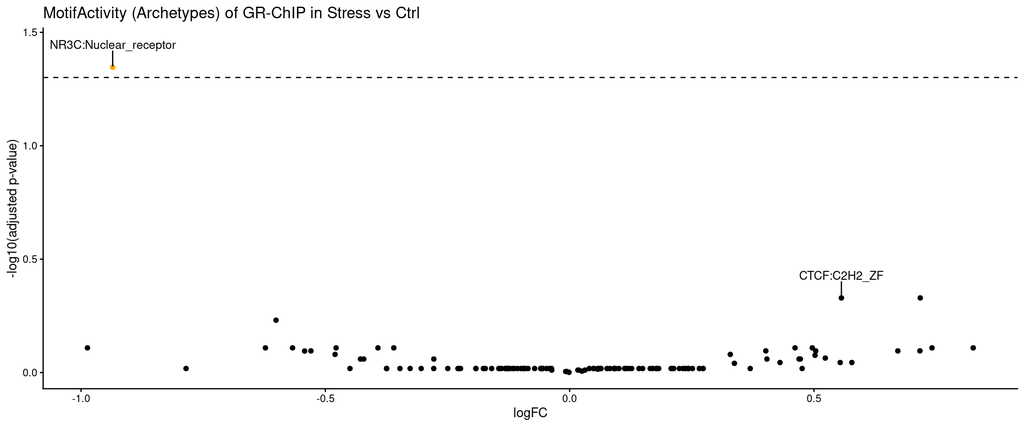

```r
library(scales)


xlim <- c(-7, 7)
ylim <- c(0,6)

# Function to generate volcano plots
generate_volcano_plot <- function(df, title) {
  df$highlight <- df$adj.P.Val < 0.05
  # df$extreme[df$logFC > xlim[2] | df$logFC < xlim[1] | -log10(df$FDR) > ylim[2] | -log10(df$FDR) < ylim[1]] <- "extreme"
  # df$highlight[df$extreme == "extreme"] <- "extreme"
  top_genes <- df[1:2,]
  ggplot(df, aes(x=logFC, y=-log10(adj.P.Val))) +
    geom_point(aes(color = highlight)) +
    scale_color_manual(values = c("TRUE" = "orange", "FALSE" = "black")) +
    geom_text_repel(data = top_genes, aes(label=archetype), size=3.5, min.segment.length = 0, max.overlaps = Inf, nudge_y = 0.1) +
    geom_hline(yintercept=-log10(0.05), linetype="dashed")+
    xlab("logFC") +
    ylab("-log10(adjusted p-value)") +
    theme_classic() +
    theme(legend.position="none") +
    ggtitle(title)
}

# Apply the function to each dataframe in the list
generate_volcano_plot(df, "MotifActivity (Archetypes) of GR-ChIP in Stress vs Ctrl")
```

```r
ggsave("plots/Fig5F_MotifAct_GRChIP_volcano.svg")
ggsave("plots/Fig5F_MotifAct_GRChIP_volcano.pdf")
ggsave("plots/Fig5F_MotifAct_GRChIP_volcano.png")
```

# 43 Fig 5G Signal at GR-CUT&Tag embryo peaks in Sperm-GR and Embryo-H3k4me3

```r
tracks_lit <- c(

  MII_oocyte="extern_data/ATAC_PRJNA480448_MIIOocyte_GSM3262863.bw"
)
length(tracks_lit)
```

```
## [1] 1
```

```r
bw <- list.files(path = "intern_data/ChIP/",pattern = "*.bw$",full.names = T)
names(bw) <- basename(bw)

bw_groups <- list(Stress = bw[c(7:10)], Ctrl = bw[c(1:4)], Input = bw[c(5:6)])



GR_bed <- sapply(names(bw),function(names){
  import.bw(bw[names])
})
GR_bed <- GR_bed[c(-5,-6)] # we remove input




bw <- list.files(path = "intern_data/CUTNTag_GR/",pattern = "*full.bw$",full.names = T)
names(bw) <- basename(bw)

bw_groups <- list(Stress = bw[c(3:4)], Ctrl = bw[c(1:2)])



GR_bed_e2c <- sapply(names(bw),function(names){
  import.bw(bw[names])
})




bw_embryoH3K4me3 <- list.files("intern_data/CUTNTag/",pattern = ".bw$",full.names = T)
names(bw_embryoH3K4me3) <- basename(bw_embryoH3K4me3)



proms <- granges(readRDS("intern_data/CUTNTag_GR/merge_narrow_threshold_0.05.rds"))

proms <- GenomeInfoDb::keepStandardChromosomes((proms),pruning.mode = "coarse")
ah <- AnnotationHub()
ensdb <- ah[["AH89457"]]
ensdb <- GenomeInfoDb::keepStandardChromosomes(transcripts(ensdb),pruning.mode = "coarse")

seqlevels(proms) <- seqlevels(ensdb)
seqinfo(proms) <- seqinfo(ensdb)


  sm_GR <-  signal2Matrix(filepaths = GR_bed,regions = proms,w = 20L,smooth = T, background= 0)
  sm_merge_GR_IFS <- mergeSignalMatrices(epiwraps:::.ese2ml(sm_GR)[c(5:8)])
 # make sure to only take rows were we have the necessary information in 5mC

  sm_merge_GR_Ctrl <- mergeSignalMatrices(epiwraps:::.ese2ml(sm_GR)[c(1:4)])
 # make sure to only take rows were we have the necessary information in 5mC

  # make sure to only take rows were we have the necessary information in 5mC

  sm_GR_e2c <-  signal2Matrix(filepaths = GR_bed_e2c,regions = proms,w = 20L,smooth = T, background= 0) #,smooth = T, background= 0
  sm_merge_GR_IFS_e2c <- mergeSignalMatrices(epiwraps:::.ese2ml(sm_GR_e2c)[c(1:2)])
 # make sure to only take rows were we have the necessary information in 5mC

  sm_merge_GR_Ctrl_e2c <- mergeSignalMatrices(epiwraps:::.ese2ml(sm_GR_e2c)[c(3:4)])




  sm <- signal2Matrix(w = 20L, filepaths = tracks_lit,regions = proms)


  sm_Oocyte <- epiwraps:::.ese2ml(sm)

  sm_embryo <- signal2Matrix(w = 20L, filepaths = bw_embryoH3K4me3,regions = proms)
  sm_merge_embryoCtrl <- mergeSignalMatrices(epiwraps:::.ese2ml(sm_embryo)[1:2])
  sm_merge_embryoIFS <- mergeSignalMatrices(epiwraps:::.ese2ml(sm_embryo)[3:4])



  # order overall
  pOverall <- plotEnrichedHeatmaps(list(GR_Ctrl = sm_merge_GR_Ctrl,GR_IFS = sm_merge_GR_IFS,H3K4me3EmbryoCtrl = sm_merge_embryoCtrl,H3K4me3EmbryoIFS = sm_merge_embryoIFS, GREmbryoCtrl = sm_merge_GR_Ctrl,GREmbryoIFS =sm_merge_GR_IFS),multiScale = T)
  ro_Overall <- pOverall@ht_list[[1]]@row_order


  # plot with order of Overall
  p <- plotEnrichedHeatmaps(scale_rows = F,list(GR_Ctrl = sm_merge_GR_Ctrl,GR_IFS = sm_merge_GR_IFS),use_raster = T,row_title = paste0("GR occupying sites in 2-cell Embryo") ,scale_title = "GR\nsperm\ndesnity",colors = mako(2000),mean_scale_side = "none", trim = c(0.1,0.95),axis_name = c("-2kb","Center","+2kb"),row_order = ro_Overall,heatmap_legend_param = list(legend_direction = "horizontal", legend_width = unit(0.28, "npc"), title=NULL)) +

    plotEnrichedHeatmaps(scale_rows = F,list(GR_Ctrl_e2c = sm_merge_GR_Ctrl_e2c,GR_IFS_e2c = sm_merge_GR_IFS_e2c),use_raster = T,row_title = paste0("GR occupying sites in 2-cell Embryo") ,scale_title = "GR\ne2c\ndesnity",colors = magma(2000),mean_scale_side = "none", trim = c(0.1,0.95),axis_name = c("-2kb","Center","+2kb"),row_order = ro_Overall,heatmap_legend_param = list(legend_direction = "horizontal", legend_width = unit(0.28, "npc"), title=NULL)) +

    plotEnrichedHeatmaps(scale_rows = F,ml = list(H3K4me3EmbryoCtrl = sm_merge_embryoCtrl,H3K4me3EmbryoIFS = sm_merge_embryoIFS),use_raster = T,row_title = paste0("GR occupying sites in 2-cell Embryo") ,scale_title = "Embryo\ndensity",colors = colorRampPalette(c("#000000","#00A97A","#00FF7F"))(2000),mean_scale_side = "none", trim = c(0.1,0.95),axis_name = c("-2kb","Center","+2kb"),row_order = ro_Overall, heatmap_legend_param = list(legend_direction = "horizontal", legend_width = unit(0.28, "npc"), title=NULL))+
    plotEnrichedHeatmaps(scale_rows = F,ml = sm_Oocyte,use_raster = T,row_title = paste0("GR occupying sites in 2-cell Embryo") ,scale_title = "Oocyte\ndensity",colors = colorRampPalette(c("#000000","firebrick1"))(2000),mean_scale_side = "none",axis_name = c("-2kb","Center","+2kb"),row_order = ro_Overall, heatmap_legend_param = list(legend_direction = "horizontal", legend_width = unit(0.28, "npc"), title=NULL))



  print(p)


  png(paste0("plots/","Fig5G_Heatmap_GRCnT",".png"), width=1500, height=768)
  draw(p, heatmap_legend_side="bottom", annotation_legend_side="right",  legend_grouping = "original")
  dev.off()
```

```r
  pdf(paste0("plots/","Fig5G_Heatmap_GRCnT",".pdf"), width=12.5, height=10)
  draw(p, heatmap_legend_side="bottom", annotation_legend_side="right",  legend_grouping = "original")
  dev.off()
```

```r
  svg(paste0("plots/","Fig5G_Heatmap_GRCnT","svg"), width=12.5, height=10)
  draw(p, heatmap_legend_side="bottom", annotation_legend_side="right",  legend_grouping = "original")
  dev.off()
```

# 44 Fig 5H Protac effect on long RNA

```r
se <- readRDS("objects/countMatrix_longRNA_sperm.SE.rds")

se$group <- factor(paste0(se$stress, "_", se$protac))

dge_for_filter <- DGEList(assay(se, "counts"))
dge_for_filter <- calcNormFactors(dge_for_filter)
design_for_filter <- model.matrix(~ 0 + group, data = as.data.frame(colData(se)))
# Filter using the temporary design matrix
keep <- filterByExpr(dge_for_filter, min.count = 20, design = design_for_filter)
se  <- se[keep, ]
# add donor info
colData(se)$donor <- sub("^(C[0-9]+|I[0-9]+)[DK]$", "\\1", colData(se)$sampleid)
colData(se)$donor <- factor(colData(se)$donor)

# voom
dge <- DGEList(assay(se, "counts"))
dge <- calcNormFactors(dge)


assays(se)$logcpm <- log1p(edgeR::cpm(dge))
```

```r
mmu_sig_rip_by_OmicsBridge <- openxlsx::read.xlsx("objects/mmu_rip_gene_name.xlsx", colNames = FALSE)

allGR_se <- se[rownames(se)%in% mmu_sig_rip_by_OmicsBridge$X1, ]

# calculate the logFC manually to avoid anything to do with SVA
allGR_se <- log2FC(allGR_se, fromAssay = "logcpm", controls = allGR_se$protac == "DMSO", by = allGR_se$stress, isLog = TRUE)

# because here we calculate logFC(protac/dmso), and within the stress group. So here we can just use the avg logFC of all the protac samples as the final logFC for this gene
df_allGR_logFC <- rowMeans(assay(allGR_se, "log2FC")[,allGR_se$protac=="PROTAC"])

n_down <- sum(df_allGR_logFC<0)
N <- length(df_allGR_logFC)

binom.test(n_down, N, p = 0.5, alternative = "two.sided")
```

```
##
##  Exact binomial test
##
## data:  n_down and N
## number of successes = 1158, number of trials = 1586, p-value < 2.2e-16
## alternative hypothesis: true probability of success is not equal to 0.5
## 95 percent confidence interval:
##  0.7075648 0.7518574
## sample estimates:
## probability of success
##              0.7301387
```

```r
# to plot the heatmap, use the normalization to donor
allGR_se_for_heatmap <- allGR_se
allGR_se_for_heatmap <- log2FC(allGR_se_for_heatmap, fromAssay = "logcpm", controls = allGR_se_for_heatmap$protac == "DMSO", by = allGR_se_for_heatmap$donor, isLog = TRUE)
```

```r
rowData(allGR_se_for_heatmap)$direction <- ifelse(df_allGR_logFC>0,yes = "up",no = "down")
```

```r
sechm(
  allGR_se_for_heatmap,
  names(df_allGR_logFC),
  assayName = "scaledLFC",
  cluster_rows = F,
  top_annotation = c( "protac"),
  hmcols =colorRampPalette(c("blue", "black", "orange"))(101),
  gaps_at = c("protac"),gaps_row = "direction"
  )
```

```r
sh <-  sechm(
  allGR_se_for_heatmap[,allGR_se_for_heatmap$protac == "PROTAC"],
  names(df_allGR_logFC),
  assayName = "scaledLFC",
  cluster_rows = F,
  top_annotation = c("stress", "protac"),
  hmcols =colorRampPalette(c("blue", "black", "orange"))(101),
  gaps_at = c("protac"),
 gaps_row = "direction",
  column_title = "KH-103 effect on GR binding long RNA", use_raster = TRUE
  )

pdf("plots/Fig5H_longRNA_Heatmap_slim.pdf", width=6, height=8) #, width=14.5, height=10)

print(sh)
dev.off()
```

```r
png("plots/Fig5H_longRNA_Heatmap_slim.png", height=500,width = 300,)

print(sh)
dev.off()
```

```r
svg("plots/Fig5H_longRNA_Heatmap_slim.svg", width=6, height=8) #, width=14.5, height=10)

print(sh)
dev.off()
```

```r
sh <- sechm(
  allGR_se_for_heatmap,
  names(df_allGR_logFC),
  assayName = "scaledLFC",
  cluster_rows = F,
  top_annotation = c("stress", "protac"),
  hmcols =colorRampPalette(c("blue", "black", "orange"))(101),
  gaps_at = c("protac"),
  gaps_row = "direction",
  column_title = "KH-103 effect on GR binding long RNA", use_raster = TRUE
  )
pdf("plots/Fig5H_longRNA_Heatmap_wide.pdf", width=10, height=8) #, width=14.5, height=10)

print(sh)
dev.off()
```

```r
png("plots/Fig5H_longRNA_Heatmap_wide.png", height=500,width = 600,)

print(sh)
dev.off()
```

```r
svg("plots/Fig5H_longRNA_Heatmap_wide.svg", width=10, height=8) #, width=14.5, height=10)

print(sh)
dev.off()
```

# 45 Fig 5I Heatmap of differential expressed genes with a counteraction of KH-103 and Stress

```r
se <- readRDS("objects/IFS_smartSeq_embryo_salmon.SE.rds")
meta <- openxlsx::read.xlsx("objects/IFS_smartSeq_embryo_meta.xlsx",colNames = T)
meta <- meta[order(meta$Sample),]
meta <- meta[meta$Sample %in% colnames(se),]
table(meta$Sample == colnames(se))
```

```
##
## TRUE
##   17
```

```r
se$embryos <- as.factor(meta$embryos)

Group <- factor(paste(se$treatment,se$condition,sep="."))


se$Group <- Group
```

```r
set.seed(123)
se <- SEtools::svacor(se, ~Group+embryos,form0 = ~embryos, n.sv = 3)
```

```
## Number of significant surrogate variables is:  3
## Iteration (out of 5 ):1  2  3  4  5
```

```r
dds <- calcNormFactors(DGEList(assay(se))) # this calculates Normalization factors according to library sequencing depth, this is important since depth can vary greatly between samples

### lets look at the library size
# dds$samples



assays(se)$logcpm <- log1p(edgeR::cpm(dds)) # generates the log of Counts-per-million (CPM), this is a very standardized way to normalize data used then for analysis or visualisation




mm <- model.matrix(~0+Group+SV1+SV2+embryos, data=as.data.frame(colData(se))); mm
```

```
##     GroupDMSO.CTRL GroupDMSO.IFS GroupPROTAC.CTRL GroupPROTAC.IFS         SV1
## CD1              1             0                0               0 -0.18273994
## CD2              1             0                0               0 -0.09108553
## CD3              1             0                0               0 -0.07417272
## CD4              1             0                0               0 -0.13248488
## CK1              0             0                1               0 -0.12277701
## CK2              0             0                1               0  0.32064701
## CK3              0             0                1               0 -0.13230089
## CK4              0             0                1               0 -0.15360579
## CK5              0             0                1               0 -0.12398405
## CK6              0             0                1               0 -0.11302004
## ID2              0             1                0               0  0.77254440
## ID3              0             1                0               0 -0.05730034
## ID4              0             1                0               0 -0.10442061
## IK1              0             0                0               1 -0.12946001
## IK2              0             0                0               1 -0.13040685
## IK4              0             0                0               1  0.23114367
## IK5              0             0                0               1  0.22342356
##             SV2 embryos2 embryos3
## CD1 -0.12339638        0        0
## CD2  0.04765953        0        0
## CD3 -0.04670839        0        0
## CD4 -0.16425067        0        1
## CK1 -0.05133676        0        0
## CK2  0.06102469        0        1
## CK3 -0.11722750        0        0
## CK4 -0.06160861        0        0
## CK5 -0.04255255        0        1
## CK6 -0.06394109        0        0
## ID2 -0.49588056        0        0
## ID3  0.03415039        0        0
## ID4 -0.01417419        0        0
## IK1 -0.08646059        1        0
## IK2 -0.02867972        0        0
## IK4  0.53902656        1        0
## IK5  0.61435585        0        0
## attr(,"assign")
## [1] 1 1 1 1 2 3 4 4
## attr(,"contrasts")
## attr(,"contrasts")$Group
## [1] "contr.treatment"
##
## attr(,"contrasts")$embryos
## [1] "contr.treatment"
```

```r
dds <- dds[filterByExpr(dds, group = Group, min.count=20),] # 20 maybe to stringent for embryo data
dds <- estimateDisp(dds,design = mm)
se <- se[row.names(dds),]

fit <- glmFit(dds, mm, prior.count = 5) # we us prior.count 5 since we are working with low count data
```

Creating contrasts

```r
fit$design
```

```
##     GroupDMSO.CTRL GroupDMSO.IFS GroupPROTAC.CTRL GroupPROTAC.IFS         SV1
## CD1              1             0                0               0 -0.18273994
## CD2              1             0                0               0 -0.09108553
## CD3              1             0                0               0 -0.07417272
## CD4              1             0                0               0 -0.13248488
## CK1              0             0                1               0 -0.12277701
## CK2              0             0                1               0  0.32064701
## CK3              0             0                1               0 -0.13230089
## CK4              0             0                1               0 -0.15360579
## CK5              0             0                1               0 -0.12398405
## CK6              0             0                1               0 -0.11302004
## ID2              0             1                0               0  0.77254440
## ID3              0             1                0               0 -0.05730034
## ID4              0             1                0               0 -0.10442061
## IK1              0             0                0               1 -0.12946001
## IK2              0             0                0               1 -0.13040685
## IK4              0             0                0               1  0.23114367
## IK5              0             0                0               1  0.22342356
##             SV2 embryos2 embryos3
## CD1 -0.12339638        0        0
## CD2  0.04765953        0        0
## CD3 -0.04670839        0        0
## CD4 -0.16425067        0        1
## CK1 -0.05133676        0        0
## CK2  0.06102469        0        1
## CK3 -0.11722750        0        0
## CK4 -0.06160861        0        0
## CK5 -0.04255255        0        1
## CK6 -0.06394109        0        0
## ID2 -0.49588056        0        0
## ID3  0.03415039        0        0
## ID4 -0.01417419        0        0
## IK1 -0.08646059        1        0
## IK2 -0.02867972        0        0
## IK4  0.53902656        1        0
## IK5  0.61435585        0        0
## attr(,"assign")
## [1] 1 1 1 1 2 3 4 4
## attr(,"contrasts")
## attr(,"contrasts")$Group
## [1] "contr.treatment"
##
## attr(,"contrasts")$embryos
## [1] "contr.treatment"
```

```r
my.contrast <- makeContrasts(
  DMSO_IFSvsCTRL = GroupDMSO.IFS - GroupDMSO.CTRL ,
  PROTAC_IFSvsCTRL = GroupPROTAC.IFS - GroupPROTAC.CTRL,
  IFS_PROTACvsDMSO = GroupPROTAC.IFS - GroupDMSO.IFS,
  CTRL_PROTACvsDMSO = GroupPROTAC.CTRL - GroupDMSO.CTRL,
  IFS_PROTAC_int = ((GroupPROTAC.IFS - GroupPROTAC.CTRL) - (GroupDMSO.IFS - GroupDMSO.CTRL)), # interaction term

  Total_IFSvsCTRL = (GroupDMSO.IFS - GroupDMSO.CTRL + GroupPROTAC.IFS - GroupPROTAC.CTRL)/2,
  Total_PROTACvsDMSO =  (GroupPROTAC.IFS - GroupDMSO.IFS + GroupPROTAC.CTRL - GroupDMSO.CTRL)/2,
  levels = mm
)
my.contrast
```

```
##                   Contrasts
## Levels             DMSO_IFSvsCTRL PROTAC_IFSvsCTRL IFS_PROTACvsDMSO
##   GroupDMSO.CTRL               -1                0                0
##   GroupDMSO.IFS                 1                0               -1
##   GroupPROTAC.CTRL              0               -1                0
##   GroupPROTAC.IFS               0                1                1
##   SV1                           0                0                0
##   SV2                           0                0                0
##   embryos2                      0                0                0
##   embryos3                      0                0                0
##                   Contrasts
## Levels             CTRL_PROTACvsDMSO IFS_PROTAC_int Total_IFSvsCTRL
##   GroupDMSO.CTRL                  -1              1            -0.5
##   GroupDMSO.IFS                    0             -1             0.5
##   GroupPROTAC.CTRL                 1             -1            -0.5
##   GroupPROTAC.IFS                  0              1             0.5
##   SV1                              0              0             0.0
##   SV2                              0              0             0.0
##   embryos2                         0              0             0.0
##   embryos3                         0              0             0.0
##                   Contrasts
## Levels             Total_PROTACvsDMSO
##   GroupDMSO.CTRL                 -0.5
##   GroupDMSO.IFS                  -0.5
##   GroupPROTAC.CTRL                0.5
##   GroupPROTAC.IFS                 0.5
##   SV1                             0.0
##   SV2                             0.0
##   embryos2                        0.0
##   embryos3                        0.0
```

```r
Results <- list()

for (con in colnames(my.contrast)){
  Results[[con]] <- as.data.frame(topTags(glmLRT(fit,contrast = my.contrast[,con]),Inf))
  Results[[con]]$ID <- gsub(x = rownames(Results[[con]]),pattern = "ENS(.*)\\.",replacement = "")
  Results[[con]]$DEA <- con
}
# Results
```

```r
# Results$Total_PROTACvsDMSO
RNA_df_Stress_total <- Results$Total_IFSvsCTRL

RNA_df_Stress_Protac <- Results$IFS_PROTAC_int
RNA_df_Stress_Protac <- RNA_df_Stress_Protac[which(RNA_df_Stress_Protac$FDR < 0.05),]

habituation_list <- RNA_df_Stress_total[, c(1, 6)] #get the logFC and ID
colnames(habituation_list)[1] <- "Stress_coef"

habituation_list$StressProtac_coef <- RNA_df_Stress_Protac[rownames(RNA_df_Stress_total[rownames(RNA_df_Stress_total),]),]$logFC
habituation_list1 <- habituation_list[which(habituation_list$StressProtac_coef * habituation_list$Stress_coef < 0),]
```

```r
metadata(se)$anno_colors <- list(condition=c(CTRL="steelblue", IFS ="firebrick3"), treatment =c(PROTAC = "orange", DMSO = "purple4"), Group = c("DMSO.CTRL" = "seashell2","DMSO.IFS" =  "#ffa500ff" , "PROTAC.CTRL" = "seashell4" , "PROTAC.IFS" = "tomato3"))
```

```r
color_palette <- colorRampPalette(c("blue", "black", "orange"))(101)
rownames(se) <- gsub(x = rownames(se),pattern = "^ENS(.*)\\.",replacement = "")



sh <- sechm(se,features = habituation_list1$ID,assayName = "corrected",hmcols = color_palette,do.scale =T,gaps_at = c("treatment"),column_order = colnames(se)[order(colData(se)$condition)],show_rownames = T,name = paste0("Counter.Genes","\nz-score"),top_annotation = c("Group"),use_raster = T,column_title = "Differential gene expression in 2-cell embryos\nupon parternal stress and PROTAC counteraction",column_title_gp = gpar(fontsize = 20))
print(sh)



pdf("plots/Fig5I.counteractingProtacGenes.heatmap.pdf", width=14.5, height=10) #, width=14.5, height=10)

print(sh)
dev.off()
```

```r
png("plots/Fig5I.counteractingProtacGenes.heatmap.png", height=638,width = 872,)

print(sh)
dev.off()
```

```r
svg("plots/Fig5I.counteractingProtacGenes.heatmap.svg") #, width=14.5, height=10)

print(sh)
dev.off()
```

# 46 Fig 5J Differential genes impacted by Stress and KH103 in 2-cell embryo as wel as by Dex in excitatory Neurons in human neural organoids

```r
se <- readRDS("objects/SummarizedExperimentObject_EmbryoFromIFS_Sperm_treatedKH103.SE.rds")
```

```r
df <- as.data.frame(cbind(colData(se),t(assays(se)$corrected)))
```

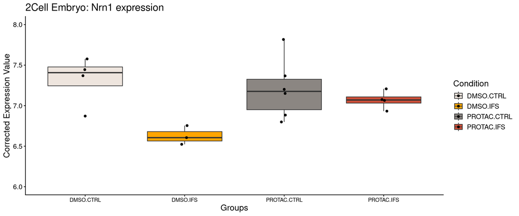

```r
# Calculate range and breaks
y_min <- floor(min(df$ENSMUSG00000039114.Nrn1))
y_max <- ceiling(max(df$ENSMUSG00000039114.Nrn1))
y_breaks <- seq(y_min, y_max, length.out = 5)

# Round to nearest 0.5
round_to_half <- function(x) round(x * 2) / 2
y_breaks <- round_to_half(y_breaks)

# Adjust limits to match rounded breaks
y_lim <- range(y_breaks)



e <- ggplot(df, aes(x = Group, y = df$ENSMUSG00000039114.Nrn1, fill = df$Group))


 e2 <- e + geom_boxplot(width = 0.75,outlier.shape = NA ) +
   geom_jitter(
   position=position_jitterdodge(jitter.width = 0.1, dodge.width = 0.75)
    )+

   ylab("Corrected Expression Value")+
   xlab("Groups")+
   ggtitle("2Cell Embryo: Nrn1 expression")+



scale_y_continuous(breaks = y_breaks, limits = y_lim) +


   scale_fill_manual(values=c( "seashell2","#ffa500ff","seashell4","tomato3"))+
   labs(fill= "Condition")+

 theme(
  axis.text.x = element_text(size = 9),
  text = element_text(size = 14),
)


 print(e2)
```

```r
 ggsave("plots/Fig5J_2CellNrn1.png")
  ggsave("plots/Fig5J_2CellNrn1.pdf")
   ggsave("plots/Fig5J_2CellNrn1.svg")
```

```r
se <- readRDS("objects//Binder_DexOrganoids_ExInh_Neurons.SE.rds")
se <- se[,grep(x = colData(se)$treatment,pattern = "Veh-Veh|Veh-Acu")]
se <- se[,grep(x = colData(se)$celltype,pattern = "Ex.Neurons")]
se <- se[,grep(x = colData(se)$cellline,pattern = "fok4")]

dea <- rowData(se)$DEA.FOK4_Ex.Neurons_Acute_effect_D90
# dea[grep(pattern = "NRN1",x = dea$gene),]
```

```r
df <- as.data.frame(cbind(colData(se),t(assays(se)$logcpm)))
```

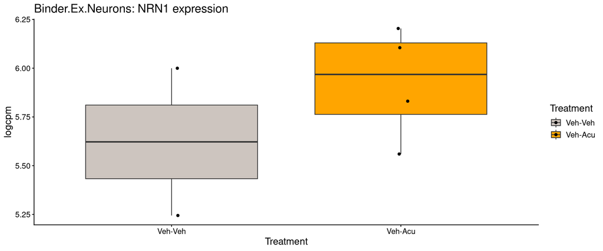

```r
e <- ggplot(df, aes(x = treatment, y = NRN1, fill = treatment))


 e2 <- e + geom_boxplot(width = 0.75,outlier.shape = NA ) +
   geom_jitter(
   position=position_jitterdodge(jitter.width = 0.1, dodge.width = 0.75)
    )+

   ylab("logcpm")+
   xlab("Treatment")+
   ggtitle("Binder.Ex.Neurons: NRN1 expression")+

   scale_fill_manual(values=c( "seashell3","#ffa500ff"))+
   labs(fill= "Treatment")+

 theme(
  axis.text.x = element_text(size = 11),
  text = element_text(size = 14),
)


 print(e2)
```

```r
  ggsave("plots/Fig5J_Nrn1Binder_changedcolor.png")
  ggsave("plots/Fig5J_Nrn1Binder_changedcolor.pdf")
   ggsave("plots/Fig5J_Nrn1Binder_changedcolor.svg")
```

## 46.1 Fig S5A F0 behavior

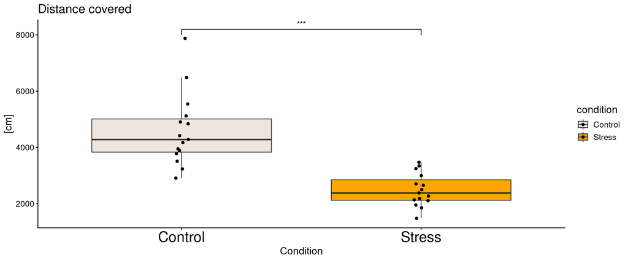

```r
e <- ggplot(report_tracking, aes(x = condition, y = bodycentre.distance.moving, fill=condition))
cols <- c("seashell2", "#ffa500ff")

e2 <- e +
  geom_boxplot(width = 0.75, outlier.shape = NA) +
  geom_jitter(position = position_jitterdodge(jitter.width = 0.1), dodge.width = 0.75) +
  #stat_summary(fun = mean, geom = "point", shape = 4, size = 3, color = "red", fill = "red") +
  geom_signif(comparisons = list(c("Control", "Stress")), map_signif_level = TRUE) +
  scale_fill_manual(values = cols) +
  labs(title = "Distance covered") +
  ylab("[cm]") +
  xlab("Condition") +
  theme_classic() +
  theme(
    axis.text.x = element_text(size = 20),
    text = element_text(size = 14)
  )

print(e2)
```

```r
ggsave("sup_plots/FigS5A.Distance.png")
ggsave("sup_plots/FigS5A.Distance.pdf")
ggsave("sup_plots/FigS5A.Distance.svg")
```

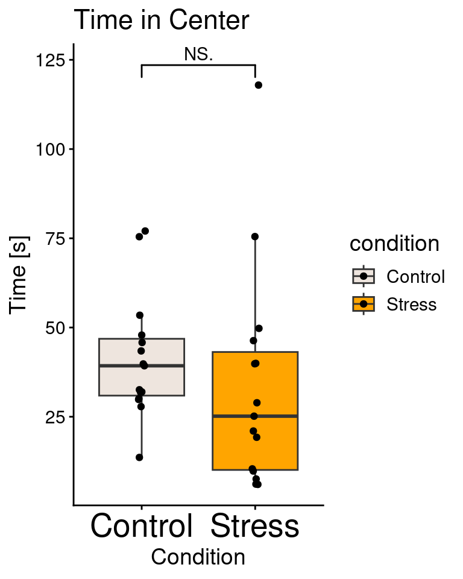

```r
e <- ggplot(report_tracking, aes(x = condition, y = bodycentre.center.total.time, fill=condition))
cols <- c("seashell2", "#ffa500ff")

e2 <- e +
  geom_boxplot(width = 0.75, outlier.shape = NA) +
  geom_jitter(position = position_jitterdodge(jitter.width = 0.1), dodge.width = 0.75) +
  #stat_summary(fun = mean, geom = "point", shape = 4, size = 3, color = "red", fill = "red") +
  geom_signif(comparisons = list(c("Control", "Stress")), map_signif_level = TRUE) +
  scale_fill_manual(values = cols) +
  labs(title = "Time in Center") +
  ylab("Time [s]") +
  xlab("Condition") +
  theme_classic() +
  theme(
    axis.text.x = element_text(size = 20),
    text = element_text(size = 14)
  )

print(e2)
```

```r
ggsave("sup_plots/FigS5A.resized.TIC.png")
ggsave("sup_plots/FigS5A.resized.TIC.pdf")
ggsave("sup_plots/FigS5A.resized.TIC.svg")
```

## 46.2 Fig S5B F0 overall behavior

```r
set.seed(123)
US <- readRDS("objects/US_object_IFS.rds")

US <- TwoGroupAnalysis(US, group = US$meta$Stress)
```

```
## [1] "no label specified, performing analysis for all"
```

```r
US <- TwoGroupAnalysis_Clusters(US, group = US$meta$Stress)
```

```
## [1] "no label specified, performing analysis for all"
```

```r
  x <- Plot2DEmbedding(US, report = US$label_names[2], colorby = "Stress", color = c("seashell3", "#ffa500ff"), plot.sem = T)+ ggtitle(paste0("UMAP of IFS animals"))
```

```
## [1] "including report: kmeans.50"
```

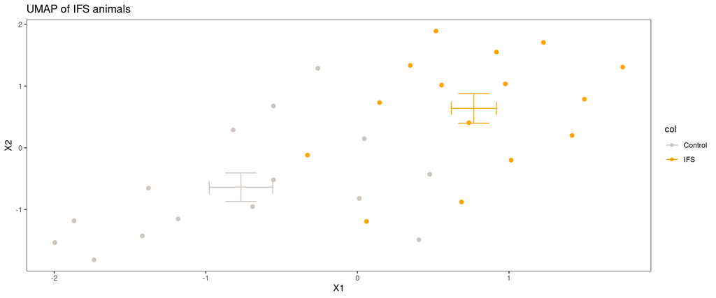

```r
  print(x)
```

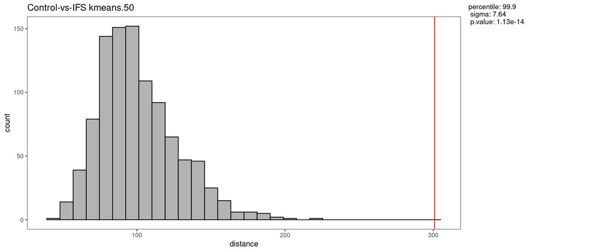

```r
  ggsave("sup_plots/FigS5B_IFS_animals_2D.pdf")
  ggsave("sup_plots/FigS5B_IFS_animals_2D.png")
  ggsave("sup_plots/FigS5B_IFS_animals_2D.svg")


set.seed(123)

  x <- PlotClusterStats(US, labels = US$label_names[2])
  print(x)
```

```r
  ggsave("sup_plots/FigS5B_IFS_animals_UMAP.pdf")
  ggsave("sup_plots/FigS5B_IFS_animals_UMAP.png")
  ggsave("sup_plots/FigS5B_IFS_animals_UMAP.svg")
```

## 46.3 Fig S5C GR peak signal across replicates in embryo

```r
peaks <- readRDS(file = "intern_data/CUTNTag_GR/merge_narrow_threshold_0.05.rds")
peaks <- GenomeInfoDb::keepStandardChromosomes(peaks,pruning.mode = "coarse")
```

list tracks

```r
bw_list <- list.files(path = "intern_data/CUTNTag_GR/",pattern = ".bw$",full.names = T)
names <- gsub(x = basename(bw_list),pattern = "\\.bam|.bw",replacement = "")
names(bw_list) <- names

bw_GR <- bw_list
bw_GR_full <- bw_GR[grepl(x = names(bw_GR),pattern = "full")]
```

```r
sm_embryo <- signal2Matrix(w = 20L, filepaths = bw_GR_full,regions = peaks,smooth = T, background= 0)
colnames(sm_embryo) <- c("Ctrl Rep.1","Ctrl Rep.2","Stress Rep.1","Stress Rep.2")
```

```r
p <- plotEnrichedHeatmaps(ml = sm_embryo,use_raster = T,row_title = paste0("GR") ,scale_title = "Embryo\ndensity",colors = magma(2000),mean_scale_side = "none",axis_name = c("-2kb","Center","+2kb"),trim = c(0.1,0.95), heatmap_legend_param = list(legend_direction = "horizontal", legend_width = unit(0.28, "npc"), title=NULL),scale_rows = FALSE)
p
```

```r
 print(p)
```

[output not shown]

```
## Error:
## ! Found 4 heatmaps with the same name 'Embryo density Ctrl Rep.1'. Please
## give unique names to heatmaps.
```

```r
  png(paste0("sup_plots/","FigS5C_Heatmap_GR",".png"), width=1000, height=768)
  draw(p, heatmap_legend_side="bottom", annotation_legend_side="right",  legend_grouping = "original")
  dev.off()
```

```r
  pdf(paste0("sup_plots/","FigS5C_Heatmap_GR",".pdf"), width=7.5, height=10)
  draw(p, heatmap_legend_side="bottom", annotation_legend_side="right",  legend_grouping = "original")
  dev.off()
```

```r
  svg(paste0("sup_plots/","FigS5C_Heatmap_GR",".svg"), width=7.5, height=10)
  draw(p, heatmap_legend_side="bottom", annotation_legend_side="right",  legend_grouping = "original")
  dev.off()
```

## 46.4 Fig S5D MotifEnrichment GR peaks in 2-cell embryo

motifs

```r
core <- read_meme(file = "objects/HOCOMOCOv11_core_MOUSE_mono_meme_format.meme")
#full <- read_meme(file = "HOCOMOCOv11_full_MOUSE_mono_meme_format.meme")


# original function PL
summary_core <- universalmotif::summarise_motifs(core)
core <- setNames(object = core,nm = summary_core$name)

motifs <- core
modf <- data.frame(row.names=summary_core$name,
                     TF=gsub("_MOUSE.H11MO...+","",summary_core$name),
                     grade=gsub(".+\\.","",summary_core$name),
                     motif_rank = gsub("[^0123]+","",gsub(".*MO.",replacement = "",summary_core$name))) #gsub("[^ro]+", "", str1)
modf <- modf[order(modf$TF,modf$grade,modf$motif_rank),]
modf <- modf[!duplicated(modf$TF),]
modf <- modf[!modf$grade == "D",]
motifs <- setNames(universalmotif::convert_motifs(motifs[row.names(modf)]), modf$TF)
```

arche arche

```r
arche <- read_meme(file = "../../tools/consensus_pwms.meme") ### file is from https://resources.altius.org/~jvierstra/projects/motif-clustering-v2.0beta/consensus_pwms.meme
```

```
## Error in `readLines()`:
## ! cannot open the connection
```

```r
 # convert_motifs(arche,class = "universalmotif-universalmotif")




arche2 <- do.call(what = "PFMatrixList", lapply(arche, class="TFBSTools-PFMatrix", FUN= convert_motifs))


arche2[[1]]@ID
```

```
## [1] "AC0001:DLX/LHX:Homeodomain"
```

```r
names <- sapply(1:length(arche2),function(i){
  names(arche2[i]) <- arche2[[i]]@ID

})

names(arche2) <- names
```

genome

```r
genome <- Rsamtools::FaFile("objects/Mus_musculus.GRCm39.dna_sm.primary_assembly.fa")
```

```r
merge_narrow_threshold_0.05 <- readRDS("intern_data//merge_narrow_threshold_0.05.rds")
```

```
## Error in `gzfile()`:
## ! cannot open the connection
```

```r
merge_narrow_threshold_0.05 <-  resize(merge_narrow_threshold_0.05,width = 200,fix = "center")
```

```
## Error in `h()`:
## ! error in evaluating the argument 'x' in selecting a method for function 'resize': object 'merge_narrow_threshold_0.05' not found
```

```r
gr <- granges(merge_narrow_threshold_0.05)
```

```
## Error in `h()`:
## ! error in evaluating the argument 'x' in selecting a method for function 'granges': object 'merge_narrow_threshold_0.05' not found
```

```r
peak_centers <- gr # appx median of consensus opeaks
peak_centers <- GenomeInfoDb::keepStandardChromosomes(peak_centers,pruning.mode = "coarse")
```

```
## Error in `h()`:
## ! error in evaluating the argument 'x' in selecting a method for function 'seqlevels': unable to find an inherited method for function 'seqinfo' for signature 'x = "tbl_df"'
```

```r
peak_seqs <- memes::get_sequence(GenomeInfoDb::dropSeqlevels(peak_centers,"MT",pruning.mode = "coarse"), genome)# dropping MT due to its absence in  reference genome file
```

```
## Error in `h()`:
## ! error in evaluating the argument 'x' in selecting a method for function 'setdiff': error in evaluating the argument 'x' in selecting a method for function 'seqlevels': unable to find an inherited method for function 'seqinfo' for signature 'x = "tbl_df"'
```

```r
ame_merge_narrow_threshold_0.05<- runAme(peak_seqs , database=convert_motifs(motifs), meme_path="/common/meme/bin/")
```

[output not shown]

```r
ame_merge_narrow_threshold_0.05$motif <- basename(ame_merge_narrow_threshold_0.05$motif_db)
```

```r
# ame_merge_narrow_threshold_0.05[ame_merge_narrow_threshold_0.05$motif_id]
```

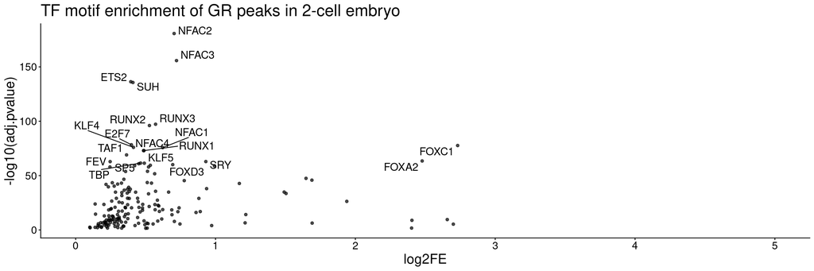

```r
p2 <- ggplot(ame_merge_narrow_threshold_0.05, aes(log2(((tp/pos))/((fp/neg))), -log10(adj.pvalue))) +
  geom_point(alpha=0.7, size =1.5) + geom_text_repel(data=head((ame_merge_narrow_threshold_0.05),20), aes(label=motif),max.overlaps = 20, size = 5)+
  labs(x="log2FE")+ xlim(c(0,5))+theme(text = element_text(size = 13))+ggtitle("TF motif enrichment of GR peaks in 2-cell embryo")+
      geom_text_repel(data=ame_merge_narrow_threshold_0.05[(ame_merge_narrow_threshold_0.05$motif == "GCR"),],colour = "orange", aes(label=motif),max.overlaps = 20, size = 6,nudge_x = 0.3,nudge_y = 6)+
    # geom_text_repel(data=ame_merge_narrow_threshold_0.05[(ame_merge_narrow_threshold_0.05$motif == "ANDR"),], aes(label=motif),max.overlaps = 20, size = 4)+
    # geom_text_repel(data=ame_merge_narrow_threshold_0.05[(ame_merge_narrow_threshold_0.05$motif == "PRGR"),], aes(label=motif),max.overlaps = 20, size = 4)+
  theme_classic() +
  theme(legend.position = "none",axis.text.x = element_text(size=14),
          axis.text.y = element_text(size=14),
          legend.text = element_text(size=12),
          legend.title = element_text(size = 14),
          text = element_text(size = 18)
    )
p2
```

```r
ggsave("sup_plots/FigS5D_motifEnrichemnt_GR_embryo.svg")
ggsave("sup_plots/FigS5D_motifEnrichemnt_GR_embryo.png")
ggsave("sup_plots/FigS5D_motifEnrichemnt_GR_embryo.pdf")
```

## 46.5 Fig S5E GO:BP enrichment of GR-peaks in embryo

```r
poi <- readRDS("intern_data/CUTNTag_GR/merge_narrow_threshold_0.05.rds")
```

```r
ah <- AnnotationHub()
genome <- ah[["AH89457"]]

annGR <- transcripts(genome,
 columns = c("tx_id", "tx_biotype", "gene_id", "gene_name")
)

poi_annotated <- ChIPpeakAnno::annoPeaks(peaks = poi,annoData = annGR,bindingType = "fullRange",select = "bestOne")
```

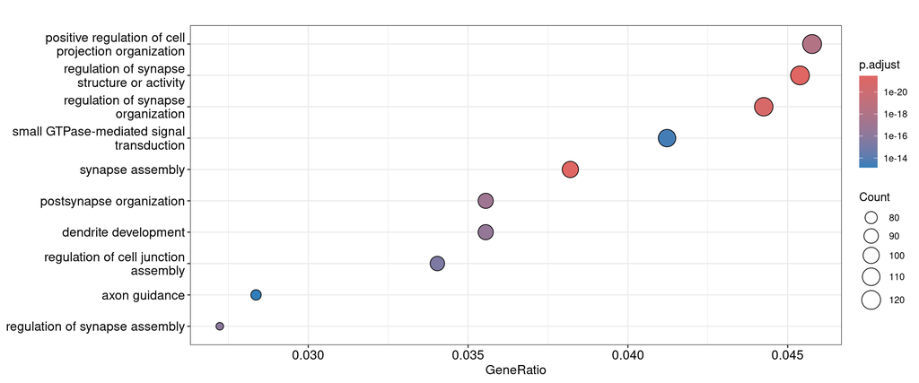

```r
set.seed(123)


  gene_list <- unlist(poi_annotated$gene_name)
  gene_list <- gene_list[!duplicated(gene_list)]

gobp <- enrichGO(gene          = gene_list,
                OrgDb         = org.Mm.eg.db,
                keyType       = "SYMBOL",
                ont           = "BP",  # BP: Biological Process, MF: Molecular Function, CC: Cellular Component
                pAdjustMethod = "BH",
                pvalueCutoff  = 1,
                qvalueCutoff  = 1
)

d <- dotplot(gobp, showCategory=10)
print(d)
```

```r
gobp@result
```

|  | ID | Description | GeneRatio | BgRatio | RichFactor | FoldEnrichment | zScore | pvalue | p.adjust | qvalue | geneID | Count |
| --- | --- | --- | --- | --- | --- | --- | --- | --- | --- | --- | --- | --- |
| GO:0007416 | GO:0007416 | synapse assembly | 101/2644 | 320/25730 | 0.31562500 | 3.0714944 | 12.618980171 | 8.095792e-26 | 3.408899e-22 | 2.403516e-22 | Adgrb3/Erbb4/Dock10/Srgap2/Dnm3/Mark1/Plxnc1/Ntn1/Crk/Asic2/…… | 101 |
| GO:0050803 | GO:0050803 | regulation of synapse structure or activity | 120/2644 | 424/25730 | 0.28301887 | 2.7541889 | 12.325807198 | 1.111114e-25 | 3.408899e-22 | 2.403516e-22 | Adgrb3/Nrp2/Erbb4/Epha4/Dock10/Srgap2/Dnm3/Psen2/Mark1/Fyn/A…… | 120 |
| GO:0050807 | GO:0050807 | regulation of synapse organization | 117/2644 | 415/25730 | 0.28192771 | 2.7435703 | 12.118319271 | 6.552534e-25 | 1.340212e-21 | 9.449444e-22 | Adgrb3/Nrp2/Erbb4/Epha4/Dock10/Srgap2/Dnm3/Psen2/Mark1/Fyn/A…… | 117 |
| GO:0031346 | GO:0031346 | positive regulation of cell projection organization | 121/2644 | 469/25730 | 0.25799574 | 2.5106771 | 11.173793313 | 4.320220e-22 | 6.627217e-19 | 4.672659e-19 | Rp1/Erbb4/Epha4/Hdac4/Dnm3/Adcy10/Ddr2/Fyn/Fig4/Map2k2/Plxnc…… | 121 |
| GO:0099173 | GO:0099173 | postsynapse organization | 94/2644 | 328/25730 | 0.28658537 | 2.7888962 | 11.034583174 | 8.352234e-21 | 1.024986e-17 | 7.226880e-18 | Nrp2/Erbb4/Epha4/Dock10/Dnm3/Nos1ap/Psen2/Mark1/Fyn/Camk2b/C…… | 94 |
| GO:0016358 | GO:0016358 | dendrite development | 94/2644 | 334/25730 | 0.28143713 | 2.7387962 | 10.824481402 | 3.305906e-20 | 3.380840e-17 | 2.383732e-17 | Prex2/Adgrb3/Nck2/Map2/Epha4/Dock10/Srgap2/Dnm3/Mark1/Syne1/…… | 94 |
| GO:0051963 | GO:0051963 | regulation of synapse assembly | 72/2644 | 221/25730 | 0.32579186 | 3.1704328 | 10.966387950 | 1.153218e-19 | 1.010878e-16 | 7.127410e-17 | Adgrb3/Dock10/Srgap2/Mark1/Ntn1/Asic2/Gna13/Pum2/Lrfn5/Mdga2…… | 72 |
| GO:1901888 | GO:1901888 | regulation of cell junction assembly | 90/2644 | 325/25730 | 0.27692308 | 2.6948679 | 10.406046748 | 6.690670e-19 | 5.131744e-16 | 3.618244e-16 | Adgrb3/Dock10/Clasp1/Srgap2/Mark1/Lims1/Rap1b/Wdpcp/Ntn1/Asi…… | 90 |
| GO:0007264 | GO:0007264 | small GTPase-mediated signal transduction | 109/2644 | 461/25730 | 0.23644252 | 2.3009327 | 9.538478033 | 4.996428e-17 | 3.406454e-14 | 2.401792e-14 | Dock10/Rgl1/Cdc42bpa/Itpkb/Tgfb2/Arfgef3/Arhgap18/Kitl/Rap1b…… | 109 |
| GO:0007411 | GO:0007411 | axon guidance | 75/2644 | 264/25730 | 0.28409091 | 2.7646214 | 9.753061914 | 1.196663e-16 | 7.342722e-14 | 5.177141e-14 | Nrp2/Epha4/Cxcr4/Nfasc/Lmx1a/Tgfb2/Lamb3/Ank3/Ntn1/Wnt3/Crpp…… | 75 |

[output cut: 6126 more lines]

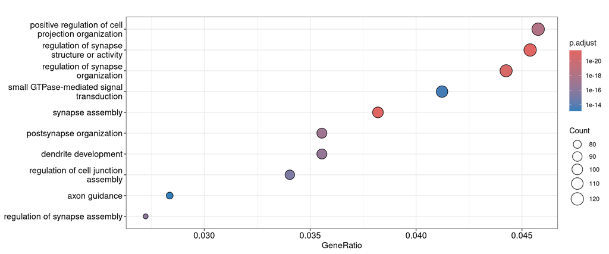

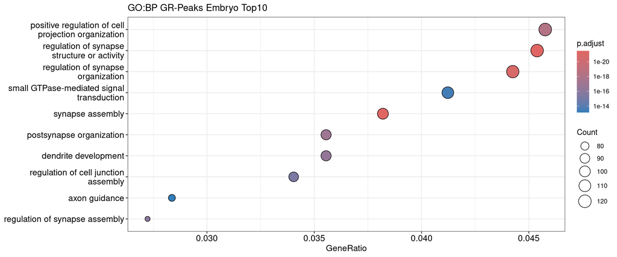

```r
d <- dotplot(gobp, showCategory=10)

print(d)+ggtitle("GO:BP GR-Peaks Embryo Top10")
```

```r
# kegg@result
ggsave("sup_plots/FigS5E_GOBP_e2c_CnT.png")
ggsave("sup_plots/FigS5E_GOBP_e2c_CnT.pdf")
```

## 46.6 Fig S5F GR-Embryo signal at Sgcd locus

```r
bw_list <- list.files(path = "intern_data/CUTNTag_GR/",pattern = ".bw$",full.names = T)
names <- gsub(x = basename(bw_list),pattern = "\\.bam|.bw",replacement = "")
names(bw_list) <- names


bw_GR <- bw_list

bw_GR_full <- bw_GR[grepl(x = names(bw_GR),pattern = "full")]
```

```r
bw_groups <- list("Embryo\nStress" = bw_GR_full[3:4], "Embryo\nCtrl" = bw_GR_full[1:2])
```

```r
plotSignalTracks(files = bw_groups,overlay.alpha = 75,region = "11:47531814-47532348",aggregation = "mean",colors = c("#B83779FF","#FEB27AFF"),genomeAxis = T,ensdb = ensdb,extend = c(2500,2500),ylim= c(0,3), fontface.main = 1,cex.main = 1,cex.id=0.9,cex.title = 0.7) # , rotation.title = 0
```

```
## Error in `plotSignalTracks()`:
## ! is(ensdb, "EnsDb") || is(ensdb, "TxDb") is not TRUE
```

[figure not shown]

```r
grid.text(paste0("Peak: 11:47531814-47532348","; ","Sgcd"), x = 0.3, y = 0.95, gp = gpar(fontsize = 14, fontface = "bold"))
```

```r
png(paste0("sup_plots/Fig5F_Sgcd.png"), width=750, height=512)
plotSignalTracks(files = bw_groups[3:4],overlay.alpha = 75,region = "11:47531814-47532348",aggregation = "mean",colors = c("#B83779FF","#FEB27AFF")[3:4],genomeAxis = T,ensdb = ensdb,extend = c(2500,2500),ylim= c(0,3), fontface.main = 1.4,cex.main = 0.9,cex.id=0.9,cex.title = 0.9) # , rotation.title = 0
```

```
## Error in `plotSignalTracks()`:
## ! is(ensdb, "EnsDb") || is(ensdb, "TxDb") is not TRUE
```

```r
grid.text(paste0("Peak: 11:47531814-47532348","; ","Sgcd"), x = 0.5, y = 0.95, gp = gpar(fontsize = 15, fontface = "bold"))
dev.off()
```

```r
pdf(paste0("sup_plots/Fig5F_Sgcd.pdf"), width=8, height=7,colormodel = "cymk")
plotSignalTracks(files = bw_groups[3:4],overlay.alpha = 75,region = "11:47531814-47532348",aggregation = "mean",colors = c("#B83779FF","#FEB27AFF")[3:4],genomeAxis = T,ensdb = ensdb,extend = c(2500,2500),ylim= c(0,3), fontface.main = 1.4,cex.main = 0.9,cex.id=0.9,cex.title = 0.9) # , rotation.title = 0
```

```
## Error in `plotSignalTracks()`:
## ! is(ensdb, "EnsDb") || is(ensdb, "TxDb") is not TRUE
```

```r
grid.text(paste0("Peak: 11:47531814-47532348","; ","Sgcd"), x = 0.5, y = 0.95, gp = gpar(fontsize = 15, fontface = "bold"))
dev.off()
```

```r
svg(paste0("sup_plots/Fig5F_Sgcd.svg"), width=8, height=7)
plotSignalTracks(files = bw_groups[3:4],overlay.alpha = 75,region = "11:47531814-47532348",aggregation = "mean",colors = c("#B83779FF","#FEB27AFF")[3:4],genomeAxis = T,ensdb = ensdb,extend = c(2500,2500),ylim= c(0,3), fontface.main = 1.4,cex.main = 0.9,cex.id=0.9,cex.title = 0.9) # , rotation.title = 0
```

```
## Error in `plotSignalTracks()`:
## ! is(ensdb, "EnsDb") || is(ensdb, "TxDb") is not TRUE
```

```r
grid.text(paste0("Peak: 11:47531814-47532348","; ","Sgcd"), x = 0.5, y = 0.95, gp = gpar(fontsize = 15, fontface = "bold"))
dev.off()
```

## 46.7 Fig S5G MotifActivity (Archetypes) in GR-Embryo peaks

```r
arche <- read_meme(file = "objects/consensus_pwms.meme") ### file is from https://resources.altius.org/~jvierstra/projects/motif-clustering-v2.0beta/consensus_pwms.meme
 # convert_motifs(arche,class = "universalmotif-universalmotif")

arche2 <- do.call(what = "PFMatrixList", lapply(arche, class="TFBSTools-PFMatrix", FUN= convert_motifs))

# arche2[[1]]@ID

names <- sapply(1:length(arche2),function(i){
  names(arche2[i]) <- arche2[[i]]@ID

})

names(arche2) <- names
```

```r
IC <- lapply(arche,function(x){
  x@icscore
})

arche3 <- names(arche2)
arche3_names <- gsub(pattern = "AC....\\:",replacement = "",x = arche3)

keep <- unlist(IC) == tapply(unlist(IC), arche3_names, max)[arche3_names]

arche2_filtIC <- arche2[keep]
```

we filter for median

```r
arche2_filtmedian <- arche2[unlist(IC)>median(unlist(IC)),]
```

```r
arche2_filterboth <- arche2[unlist(IC)>median(unlist(IC))& keep,]
```

```r
se <- readRDS("intern_data/CUTNTag_GR/countMatrix_broad_resized300bp.SE.rds")


# summary(assay(se)[,1])
se <- se[,-3]

# colData(se) <- DataFrame(meta_R)
se$Group <- as.factor(c("Ctrl","Ctrl","Stress","Stress"))
se$Group <-relevel(se$Group,"Ctrl")
rownames(se) <- as.character(granges(se))

se <- addGCBias(se, genome=genome)
```

```
## Error in `validate_genome_input()`:
## ! genome input must be a BSgenome, DNAStringSet, or FaFileobject or a string recognized by getBSgenome
```

```r
se <- se[rowSums(assay(se))>1,]
```

```r
# compute deviations

set.seed(123)
single_motifs <- do.call(what = "PFMatrixList", lapply(motifs, class="TFBSTools-PFMatrix", FUN= convert_motifs)) #old way and new with mouse hocomocov11 changed to lapply(motifs)
motif_ix <- matchMotifs(single_motifs, se, genome=genome)
```

```
## Error in `matchMotifs()`:
## ! could not find function "matchMotifs"
```

```r
dev <- betterChromVAR::betterChromVAR(object =se, annotations   =motif_ix)
```

```
## Error in `betterChromVAR::betterChromVAR()`:
## ! nrow(object) == nrow(annotations) is not TRUE
```

```r
dev <- dev[!is.na(rowSums2(assays(dev)$z)),]
```

```r
# compute deviations

set.seed(123)
single_motifs <- do.call(what = "PFMatrixList", lapply(arche2_filterboth, class="TFBSTools-PFMatrix", FUN= convert_motifs)) #old way and new with mouse hocomocov11 changed to lapply(motifs)
motif_ix <- matchMotifs(single_motifs, se, genome=genome)
```

```
## Error in `matchMotifs()`:
## ! could not find function "matchMotifs"
```

```r
dev <- betterChromVAR::betterChromVAR(object =se, annotations   =motif_ix)
```

```
## Error in `betterChromVAR::betterChromVAR()`:
## ! nrow(object) == nrow(annotations) is not TRUE
```

```r
dev$Group <- as.factor(dev$Group)
```

```
## Error in `[[<-`:
## ! 0 elements in value to replace 3 elements
```

```r
mm <- model.matrix(~Group, data=as.data.frame(colData(dev))); mm
```

[output not shown]

```r
fit <- limma::lmFit(assays(dev)$z, mm,weights=sqrt(rowData(dev)$N))
```

```
## Error in `limma::lmFit()`:
## ! row dimension of design doesn't match column dimension of data object
```

```r
fit <- eBayes(fit)
```

```
## Error in `.ebayes()`:
## ! No data, or argument is not a valid lmFit object
```

```r
Results <- as.data.frame(topTable(fit = fit,coef = c(2),number = Inf));Results
```

```
## Error in `h()`:
## ! error in evaluating the argument 'x' in selecting a method for function 'as.data.frame': fit must be an MArrayLM object
```

```r
Results$archetype <- gsub(pattern = "AC....\\:",replacement = "",x = rownames(Results))
Results <- Results[!duplicated(Results$archetype),]
```

```
## Error in `Results[!duplicated(Results$archetype), ]`:
## ! incorrect number of dimensions
```

```r
library(scales)


xlim <- c(-7, 7)
ylim <- c(0,6)

# Function to generate volcano plots
generate_volcano_plot <- function(df, title) {
  df$highlight <- df$adj.P.Val < 0.05
  # df$extreme[df$logFC > xlim[2] | df$logFC < xlim[1] | -log10(df$FDR) > ylim[2] | -log10(df$FDR) < ylim[1]] <- "extreme"
  df$highlight[df$extreme == "extreme"] <- "extreme"
  top_genes <- df[df$adj.P.Val < 0.05,]
  ggplot(df, aes(x=logFC, y=-log10(adj.P.Val))) +
    geom_point(aes(color = highlight)) +
    scale_color_manual(values = c("TRUE" = "orange", "FALSE" = "black")) +
    geom_text_repel(data = rbind(subset(top_genes, highlight == TRUE ),df[df$archetype== "CTCF:C2H2_ZF",]), aes(label=archetype), size=3.5, min.segment.length = 0, max.overlaps = Inf, nudge_y = 0.1) +
    geom_hline(yintercept=-log10(0.05), linetype="dashed")+
    xlab("logFC") +
    ylab("-log10(adjusted p-value)") +
    theme_classic() +
    theme(legend.position="none") +
    ggtitle(title)
}

# Apply the function to each dataframe in the list
generate_volcano_plot(res, "MotifActivity (Archetype) of GR embryonal signal in Stress vs Ctrl")
```

[output not shown]

```
## Error in `df[df$adj.P.Val < 0.05, ]`:
## ! incorrect number of dimensions
```

```r
ggsave("sup_plots/FigS5G_Arche_GR_e2c.svg")
ggsave("sup_plots/FigS5G_Arche_GR_e2c.pdf")
ggsave("sup_plots/FigS5G_Arche_GR_e2c.png")
```

## 46.8 Fig S5H H3K4me3 peak signal across replicates

```r
bw_embryoH3K4me3 <- list.files("intern_data/CUTNTag/",pattern = ".bw$",full.names = T)
names(bw_embryoH3K4me3) <- basename(bw_embryoH3K4me3)
```

```r
H3K4me3_narrow <- import(con = "intern_data/CUTNTag/H3K4me3_CutNRun_2cell_embryo.narrowPeak",format = "narrowPeak") ## mm10
```

```r
# liftover

chain <- "intern_data/mm10ToMm39.over.chain"
bfc <- BiocFileCache()
if(nrow(bfcquery(bfc, basename(chain)))==0){bfcadd(bfc, chain)}


    seqlevelsStyle(H3K4me3_narrow) <-"UCSC"
  genome(H3K4me3_narrow) <- "mm10"
  H3K4me3_narrow <- easylift(H3K4me3_narrow, "mm39")
```

```
## Error in `easylift()`:
## ! could not find function "easylift"
```

```r
  seqlevelsStyle(H3K4me3_narrow) <-"Ensembl"

  genome(H3K4me3_narrow) <- "GRCm39"

  H3K4me3_narrow <- GenomicRanges::reduce(H3K4me3_narrow)
```

```r
sm_embryo <- signal2Matrix(w = 20L, filepaths = bw_embryoH3K4me3,regions = H3K4me3_narrow)
```

```
## Error in `.normarg_seqlengths()`:
## ! the names on the supplied 'seqlengths' vector must be identical to the
##   seqnames
```

```r
colnames(sm_embryo) <- c("Ctrl Rep.1","Ctrl Rep.2","Stress Rep.1","Stress Rep.2")
```

```r
p <- plotEnrichedHeatmaps(ml = sm_embryo,use_raster = T,row_title = paste0("H3K4me3") ,scale_title = "Embryo\ndensity",colors = colorRampPalette(c("#000000","#00A97A","#00FF7F"))(2000),mean_scale_side = "none",axis_name = c("-2kb","Center","+2kb"), heatmap_legend_param = list(legend_direction = "horizontal", legend_width = unit(0.28, "npc"), title=NULL),scale_rows = FALSE)
p
```

```r
 print(p)
```

[output not shown]

```
## Error:
## ! Found 4 heatmaps with the same name 'Embryo density Ctrl Rep.1'. Please
## give unique names to heatmaps.
```

```r
  png(paste0("sup_plots/","FigS5H_Heatmap_H3k4me3",".png"), width=1000, height=768)
  draw(p, heatmap_legend_side="bottom", annotation_legend_side="right",  legend_grouping = "original")
  dev.off()
```

```r
  pdf(paste0("sup_plots/","FigS5H_Heatmap_H3k4me3",".pdf"), width=7.5, height=10)
  draw(p, heatmap_legend_side="bottom", annotation_legend_side="right",  legend_grouping = "original")
  dev.off()
```

```r
  svg(paste0("sup_plots/","FigS5H_Heatmap_H3k4me3",".svg"), width=7.5, height=10)
  draw(p, heatmap_legend_side="bottom", annotation_legend_side="right",  legend_grouping = "original")
  dev.off()
```

## 46.9 Fig S5I Archetype in H3K4me3

```r
df <- readRDS("objects/H3K4me3CTArche_Results.DF.rds")
```

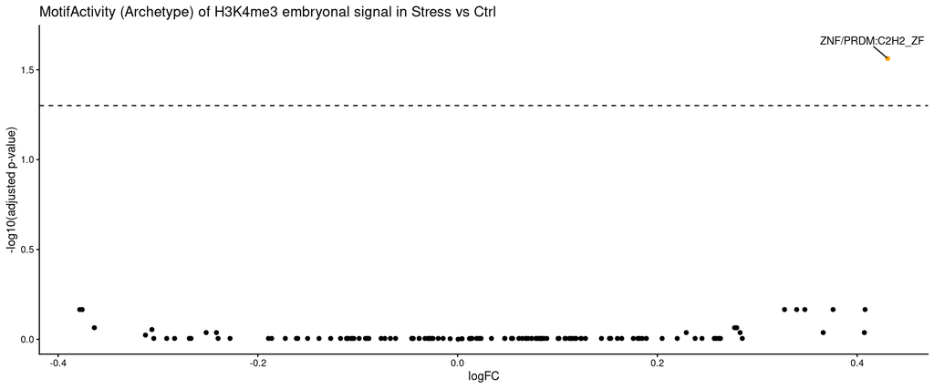

```r
library(scales)


xlim <- c(-7, 7)
ylim <- c(0,6)

# Function to generate volcano plots
generate_volcano_plot <- function(df, title) {
  df$highlight <- df$adj.P.Val < 0.05
  # df$extreme[df$logFC > xlim[2] | df$logFC < xlim[1] | -log10(df$FDR) > ylim[2] | -log10(df$FDR) < ylim[1]] <- "extreme"
  df$highlight[df$extreme == "extreme"] <- "extreme"
  top_genes <- df[df$adj.P.Val < 0.05,]
  ggplot(df, aes(x=logFC, y=-log10(adj.P.Val))) +
    geom_point(aes(color = highlight)) +
    scale_color_manual(values = c("TRUE" = "orange", "FALSE" = "black")) +
    geom_text_repel(data = subset(top_genes, highlight == TRUE ), aes(label=archetype), size=3.5, min.segment.length = 0, max.overlaps = Inf, nudge_y = 0.1) +
    geom_hline(yintercept=-log10(0.05), linetype="dashed")+
    xlab("logFC") +
    ylab("-log10(adjusted p-value)") +
    theme_classic() +
    theme(legend.position="none") +
    ggtitle(title)
}

# Apply the function to each dataframe in the list
generate_volcano_plot(df, "MotifActivity (Archetype) of H3K4me3 embryonal signal in Stress vs Ctrl")
```

```r
ggsave("sup_plots/FigS5I_Arche_H3K4me3_e2c.svg")
ggsave("sup_plots/FigS5I_Arche_H3K4me3_e2c.pdf")
ggsave("sup_plots/FigS5I_Arche_H3K4me3_e2c.png")
```

## 46.10 Fig S5J Mepe tracks

load necessary data

```r
 ensdb <- ah[["AH89457"]]
```

```r
bw <- list.files("intern_data/ChIP/",pattern = "*.bw$",full.names = T)
names(bw) <- basename(bw)
```

```r
bw_embryoH3K4me3 <- list.files("intern_data/CUTNTag/",pattern = ".bw$",full.names = T)
names(bw_embryoH3K4me3) <- basename(bw_embryoH3K4me3)
```

```r
bw_groups <- list("Sperm\nGR-Stress" = bw[c(7:10)],"Sperm\nGR-Ctrl" = bw[c(1:4)],"Embryo\nGR-Stress" =bw_GR_full[3:4], "Embryo\nGR-Ctrl" = bw_GR_full[1:2], "Embryo\nH3K4me3-Stress" = bw_embryoH3K4me3[1:2], "Embryo\nH3K4me3-Ctrl" = bw_embryoH3K4me3[3:4])#RNA = bw_RNA,GR_Input = bw_input
```

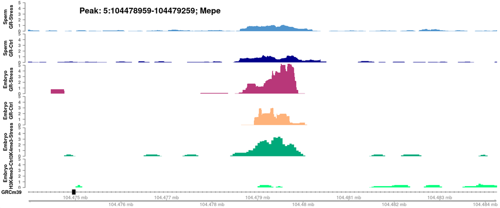

```r
plotSignalTracks(files = bw_groups,overlay.alpha = 75,region = "5:104478959-104479259",aggregation = "mean",colors = c("steelblue3","blue4","#B83779FF","#FEB27AFF","#00A97A","#00FF7F"),genomeAxis = T,ensdb = ensdb,extend = c(5000,5000),ylim= c(0,5), fontface.main = 1,cex.main = 1,cex.id=0.9,cex.title = 0.7) # , rotation.title = 0
grid.text(paste0("Peak: 5:104478959-104479259","; ","Mepe"), x = 0.3, y = 0.95, gp = gpar(fontsize = 14, fontface = "bold"))
```

```r
png(paste0("sup_plots/FigS5J_Mepe.png"), width=750, height=750)
plotSignalTracks(files = bw_groups,overlay.alpha = 75,region = "5:104478959-104479259",aggregation = "mean",colors = c("steelblue3","blue4","#B83779FF","#FEB27AFF","#00A97A","#00FF7F"),genomeAxis = T,ensdb = ensdb,extend = c(5000,5000),ylim= c(0,5), fontface.main = 1.4,cex.main = 0.9,cex.id=0.9,cex.title = 0.9,title.width=1.2) # , rotation.title = 0
grid.text(paste0("Peak: 5:104478959-104479259","; ","Mepe"), x = 0.5, y = 0.95, gp = gpar(fontsize = 15, fontface = "bold"))
dev.off()
```

```r
pdf(paste0("sup_plots/FigS5J_Mepe.pdf"), width=8, height=10,colormodel = "cymk")
plotSignalTracks(files = bw_groups,overlay.alpha = 75,region = "5:104478959-104479259",aggregation = "mean",colors = c("steelblue3","blue4","#B83779FF","#FEB27AFF","#00A97A","#00FF7F"),genomeAxis = T,ensdb = ensdb,extend = c(5000,5000),ylim= c(0,5), fontface.main = 1.4,cex.main = 0.9,cex.id=0.9,cex.title = 0.9) # , rotation.title = 0
grid.text(paste0("Peak: 5:104478959-104479259","; ","Mepe"), x = 0.5, y = 0.95, gp = gpar(fontsize = 15, fontface = "bold"))
dev.off()
```

```r
svg(paste0("sup_plots/FigS5J_Mepe.svg"), width=8, height=10)
plotSignalTracks(files = bw_groups,overlay.alpha = 75,region = "5:104478959-104479259",aggregation = "mean",colors = c("steelblue3","blue4","#B83779FF","#FEB27AFF","#00A97A","#00FF7F"),genomeAxis = T,ensdb = ensdb,extend = c(5000,5000),ylim= c(0,5), fontface.main = 1.4,cex.main = 0.9,cex.id=0.9,cex.title = 0.9) # , rotation.title = 0
grid.text(paste0("Peak: 5:104478959-104479259","; ","Mepe"), x = 0.5, y = 0.95, gp = gpar(fontsize = 15, fontface = "bold"))
dev.off()
```

## 46.11 Fig S5K Circ and small RNA

### 46.11.1 Fig S5K circRNA volcanoPlot

```r
circRNA_bsj <- read.csv("objects/circRNA_bsj.csv")
circRNA_info <- read.csv("objects/circRNA_info.csv")
rownames(circRNA_bsj) <- circRNA_bsj$circ_id
rownames(circRNA_info) <- circRNA_info$circ_id
# circRNA_bsj$gene_name <- circRNA_info[rownames(circRNA_bsj),]$gene_name

circ_counts <- circRNA_bsj[, -1]
se <- SummarizedExperiment(
  assays = list(counts = circ_counts),
  colData = data.frame(sampleid = colnames(circ_counts),
                 stress = ifelse(substr(colnames(circ_counts), 1, 1)=="C", "ctrl", "ifs"),
                 protac = ifelse(substr(colnames(circ_counts), nchar(colnames(circ_counts)), nchar(colnames(circ_counts)))=="D", "DMSO", "PROTAC"))
)
se$group <- factor(paste0(se$stress, "_", se$protac))
```

```r
# add the host gene info to se
rowData(se)$host_gene <- circRNA_info[rownames(se),]$gene_name
rowData(se)$circ_type <- circRNA_info[rownames(se),]$circ_type
rowData(se)$gene_type <- circRNA_info[rownames(se),]$gene_type
rowData(se)$strand <- circRNA_info[rownames(se),]$strand


dge_for_filter <- DGEList(assay(se, "counts"))
dge_for_filter <- calcNormFactors(dge_for_filter)
design_for_filter <- model.matrix(~ 0 + group, data = as.data.frame(colData(se)))
keep <- filterByExpr(dge_for_filter, min.count = 5, design = design_for_filter)  # only use min.count=5 because circRNA has low reads.

se <- se[keep, ] # 4858 circRNAs kept

# voom
dge <- DGEList(assay(se, "counts"))
dge <- calcNormFactors(dge)
design<- model.matrix(~ 0 + group, data = as.data.frame(colData(se)))
assay(se, "logcpm") <- log1p(edgeR::cpm(dge)[rownames(se),])

# add donor info
colData(se)$donor <- sub("^(C[0-9]+|I[0-9]+)[DK]$", "\\1", colData(se)$sampleid)
colData(se)$donor <- factor(colData(se)$donor)

# ── 2. First voom + first duplicateCorrelation pass ───────────────────────────
vobj_for_dupcor <- voom(dge, design, plot = FALSE)
dupcor <- duplicateCorrelation(vobj_for_dupcor, design, block = colData(se)$donor)

# ── 3. Second voom pass, now informed by the donor correlation ─────────────────
vobj <- voom(dge, design, plot = FALSE,
             block       = colData(se)$donor,
             correlation = dupcor$consensus)

# ── 4. Second duplicateCorrelation pass on the better voom weights ─────────────
dupcor <- duplicateCorrelation(vobj, design, block = colData(se)$donor)

# ── 5. Fit the linear model ────────────────────────────────────────────────────
fit <- lmFit(vobj, design, block=colData(se)$donor, correlation = dupcor$consensus)

contrast <- makeContrasts(
  total_stress_vs_ctrl  = (groupifs_DMSO + groupifs_PROTAC)/2 - (groupctrl_DMSO + groupctrl_PROTAC)/2,
  DMSO_stress_vs_ctrl   = groupifs_DMSO - groupctrl_DMSO,
  PROTAC_stress_vs_ctrl = groupifs_PROTAC - groupctrl_PROTAC,
  total_PROTAC_vs_DMSO  = (groupifs_PROTAC + groupctrl_PROTAC)/2 - (groupifs_DMSO + groupctrl_DMSO)/2,
  ctrl_PROTAC_vs_DMSO   = groupctrl_PROTAC - groupctrl_DMSO,
  stress_PROTAC_vs_DMSO = groupifs_PROTAC - groupifs_DMSO,
  interaction           = (groupifs_PROTAC - groupctrl_PROTAC) - (groupifs_DMSO - groupctrl_DMSO),
  levels = design
)

fit2 <- contrasts.fit(fit, contrast)
fit2 <- eBayes(fit2)  # Empirical Bayes smoothing of standard errors


# extract each contrast table
rowData(se)$DEA.voom.total_stress_vs_ctrl <- topTable(fit2, coef = "total_stress_vs_ctrl", n = Inf)[rownames(se),]
rowData(se)$DEA.voom.DMSO_stress_vs_ctrl <- topTable(fit2, coef = "DMSO_stress_vs_ctrl", n = Inf)[rownames(se),]
rowData(se)$DEA.voom.PROTAC_stress_vs_ctrl <- topTable(fit2, coef = "PROTAC_stress_vs_ctrl", n = Inf)[rownames(se),]
rowData(se)$DEA.voom.total_PROTAC_vs_DMSO <- topTable(fit2, coef = "total_PROTAC_vs_DMSO", n = Inf)[rownames(se),]
rowData(se)$DEA.voom.ctrl_PROTAC_vs_DMSO <- topTable(fit2, coef = "ctrl_PROTAC_vs_DMSO", n = Inf)[rownames(se),]
rowData(se)$DEA.voom.stress_PROTAC_vs_DMSO <- topTable(fit2, coef = "stress_PROTAC_vs_DMSO", n = Inf)[rownames(se),]
rowData(se)$DEA.voom.interaction <- topTable(fit2, coef = "interaction", n = Inf)


# table(rowData(se)$DEA.voom.total_stress_vs_ctrl$adj.P.Val<0.05)  # no
# table(rowData(se)$DEA.voom.PROTAC_stress_vs_ctrl$adj.P.Val<0.05)  # no
# table(rowData(se)$DEA.voom.DMSO_stress_vs_ctrl$adj.P.Val<0.05)  # no
# table(rowData(se)$DEA.voom.total_PROTAC_vs_DMSO$adj.P.Val<0.05)  # no
# table(rowData(se)$DEA.voom.ctrl_PROTAC_vs_DMSO$adj.P.Val<0.05)  # no
# table(rowData(se)$DEA.voom.stress_PROTAC_vs_DMSO$adj.P.Val<0.05)  # no
# table(rowData(se)$DEA.voom.interaction$adj.P.Val<0.05)  # no
```

```r
res <- rowData(se)$DEA.voom.total_stress_vs_ctrl
```

```r
res$circ_id <- rownames(res)
# circRNA_info




library(dplyr)

result <- res %>%
  left_join(circRNA_info, by = "circ_id")

rownames(result) <- result$circ_id
result <- result[order(result$P.Value),]

result[grep("Tasp1",result$gene_name),]
```

|  | logFC | AveExpr | t | P.Value | adj.P.Val | B | circ_id | strand | circ_type | gene_id | gene_name | gene_type |
| --- | --- | --- | --- | --- | --- | --- | --- | --- | --- | --- | --- | --- |
| chr2:139819527\|139838077 | 1.787364648 | 6.493576 | 3.47282484 | 0.003844032 | 0.5749468 | -2.151978 | chr2:139819527\|139838077 | - | exon | ENSMUSG00000039033.12 | Tasp1 | protein_coding |
| chr2:139789090\|139827128 | 2.628993774 | 5.989516 | 2.85373138 | 0.012988982 | 0.5749468 | -3.033300 | chr2:139789090\|139827128 | - | exon | ENSMUSG00000039033.12 | Tasp1 | protein_coding |
| chr2:139884014\|139899419 | 0.215642017 | 14.128789 | 2.82062156 | 0.013857530 | 0.5749468 | -3.882438 | chr2:139884014\|139899419 | - | exon | ENSMUSG00000039033.12 | Tasp1 | protein_coding |
| chr2:139789077\|139827128 | 1.625465514 | 7.318647 | 1.87507277 | 0.082271947 | 0.6208094 | -4.126880 | chr2:139789077\|139827128 | - | exon | ENSMUSG00000039033.12 | Tasp1 | protein_coding |
| chr2:139752453\|139793499 | 0.575991948 | 6.726344 | 1.71161639 | 0.109513751 | 0.6591231 | -4.293635 | chr2:139752453\|139793499 | - | exon | ENSMUSG00000039033.12 | Tasp1 | protein_coding |
| chr2:139872521\|139890229 | 0.977484409 | 4.914695 | 1.49009790 | 0.158871819 | 0.7000375 | -4.410062 | chr2:139872521\|139890229 | - | intron | ENSMUSG00000039033.12 | Tasp1 | protein_coding |
| chr2:139872521\|139899419 | 0.295190730 | 8.278725 | 1.35069145 | 0.198696143 | 0.7362547 | -4.987113 | chr2:139872521\|139899419 | - | intron | ENSMUSG00000039033.12 | Tasp1 | protein_coding |
| chr2:139789090\|139819633 | 0.463169431 | 5.410745 | 0.79991674 | 0.437418230 | 0.8560287 | -4.900273 | chr2:139789090\|139819633 | - | exon | ENSMUSG00000039033.12 | Tasp1 | protein_coding |
| chr2:139789090\|139793499 | 0.641087595 | 5.846912 | 0.74518395 | 0.468760254 | 0.8619816 | -5.017221 | chr2:139789090\|139793499 | - | exon | ENSMUSG00000039033.12 | Tasp1 | protein_coding |
| chr2:139861989\|139899419 | -0.319878554 | 5.961428 | -0.73201572 | 0.476503057 | 0.8643618 | -5.063687 | chr2:139861989\|139899419 | - | intron | ENSMUSG00000039033.12 | Tasp1 | protein_coding |

[output cut: 11 more lines]

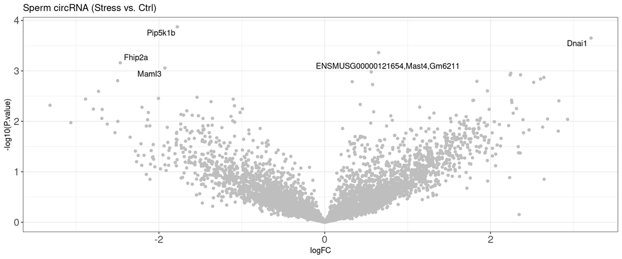

```r
sig_anno <- rep("non", times = nrow(res))
sig_anno[which(res$adj.P.Val < 0.05 & res$logFC > 0)] <- "up" # no ups
sig_anno[which(res$adj.P.Val < 0.05 & res$logFC< 0)] <- "down"  # no downs
result$sig_anno <- sig_anno
library(ggplot2)
library(ggrepel)

p <- ggplot(
  result,
  aes(x = logFC, y = -log10(P.Value), color = sig_anno)
) +
  geom_point() +
  scale_color_manual(
    values = c("up" = "red", "non" = "gray", "down" = "blue")
  ) +
  geom_text_repel(
    data = head(result),
    aes(label = gene_name),
    color = "black"
  ) +
  labs(
    x = "logFC",
    y = "-log10(P.value)",
    title = "Sperm circRNA (Stress vs. Ctrl)"
  ) +
  theme_bw() +
  theme(legend.position = "none",axis.text.x = element_text(size=14),
          axis.text.y = element_text(size=14),
          legend.text = element_text(size=12),
          legend.title = element_text(size = 14)
    )

p
```

```r
#
#
ggsave("sup_plots/FigS5K_CircRNA_totalStress.svg")
ggsave("sup_plots/FigS5K_CircRNA_totalStress.pdf")
ggsave("sup_plots/FigS5K_CircRNA_totalStress.png")
```

### 46.11.2 Fig S5K smallRNA

```r
library(stringr)

se <- readRDS("objects/countMatrix_smallRNA_sperm.SE.rds")


# Now in our data, for tRNA: we have Match_genome and Unmatch_genome for the same tRNA annotation. We collapse them:
counts_df <- as.data.frame(assay(se, "counts"))
counts_df$feature <- rownames(counts_df)
# for nucleus tRNA:
counts_df$merge_key <- ifelse(
  str_detect(counts_df$feature, "GtRNAdb-mature-tRNA") &
    str_detect(counts_df$feature, "(Match|Unmatch)_Genome") &
    !str_detect(counts_df$feature, "(_3_end|_5_end)"),
  str_replace(counts_df$feature, "(Match|Unmatch)_Genome/(.+)", "Combined_Genome/\\2"),
  counts_df$feature
)
# for mitochondrial tRNA: (similar)
counts_df$merge_key <- ifelse(
  str_detect(counts_df$feature, "mitotRNAdb-mature-mt_tRNA") &
    str_detect(counts_df$feature, "(Match|Unmatch)_Genome") &
    !str_detect(counts_df$feature, "(_3_end|_5_end)"),
  str_replace(counts_df$feature, "(Match|Unmatch)_Genome/(.+)", "Combined_Genome/\\2"),
  counts_df$merge_key
)

counts_df$feature <- NULL  # drop before aggregation
counts_merged <- aggregate(. ~ merge_key, data = counts_df, FUN = sum)
rownames(counts_merged) <- counts_merged$merge_key
counts_merged$merge_key <- NULL

se_collapse <- SummarizedExperiment(
  assays = list(counts = as.matrix(counts_merged)),
  colData = colData(se)
)
# se_collapse # 2238 smallRNAs
se_collapse <- se_collapse[,order(se_collapse$stress, se_collapse$protac)]
rm(se)

# add donor info
colData(se_collapse)$donor <- sub("^(C[0-9]+|I[0-9]+)[DK]$", "\\1", colData(se_collapse)$sampleid)
colData(se_collapse)$donor <- factor(colData(se_collapse)$donor)
metadata(se_collapse)$anno_colors <- list(stress = c(stress = "red3", ctrl ="#56B4E9"),
                                          protac = c(PROTAC = "orange2", DMSO = "navy"))
colnames(se_collapse) <- se_collapse$sampleid

dge_tmp <- DGEList(assay(se_collapse, "counts"))
dge_tmp <- calcNormFactors(dge_tmp)
assay(se_collapse, "logcpm") <- log1p(edgeR::cpm(dge_tmp)[rownames(se_collapse),])
```

For now only look at the tRNA and miRNA

```r
se_mirna <- se_collapse[grep("miRNA", rownames(se_collapse)),]  # 970
se_trna <- se_collapse[grep("GtRNAdb", rownames(se_collapse)), ]  # 181 (no mito-tRNA)
se_mito_trna <- se_collapse[grep("mitotRNAdb", rownames(se_collapse)), ]  # 75
```

miRNA:

```r
group <- factor(se_mirna$group)
set.seed(8)
se_mirna <- SEtools::svacor(se_mirna, ~group, n.sv = 1)  # the suggested sv number is 2
```

```
## Number of significant surrogate variables is:  1
## Iteration (out of 5 ):1  2  3  4  5
```

```r
# counts filter
dge_for_filter <- DGEList(assay(se_mirna, "counts"))
dge_for_filter <- calcNormFactors(dge_for_filter)
design_for_filter <- model.matrix(~ 0 + group, data = as.data.frame(colData(se_mirna)))
keep <- filterByExpr(dge_for_filter, min.count = 5, design = design_for_filter)
se_mirna  <- se_mirna[keep, ]  # 942 kept

# voom
dge_mirna <- DGEList(assay(se_mirna, "counts"))
dge_mirna <- calcNormFactors(dge_mirna)
design_mirna <- model.matrix(~ 0 + group + SV1, data = as.data.frame(colData(se_mirna)))
# ── 2. First voom + first duplicateCorrelation pass ───────────────────────────
vobj_for_dupcor_mirna <- voom(dge_mirna, design_mirna, plot = FALSE)
dupcor_mirna <- duplicateCorrelation(vobj_for_dupcor_mirna, design_mirna, block = colData(se_mirna)$donor)

# ── 3. Second voom pass, now informed by the donor correlation ─────────────────
vobj_mirna <- voom(dge_mirna, design_mirna, plot = FALSE, block = colData(se_mirna)$donor,
             correlation = dupcor_mirna$consensus)

# ── 4. Second duplicateCorrelation pass on the better voom weights ─────────────
dupcor_mirna <- duplicateCorrelation(vobj_mirna, design_mirna, block = colData(se_mirna)$donor)

# ── 5. Fit the linear model ────────────────────────────────────────────────────
fit_mirna <- lmFit(vobj_mirna, design_mirna, block=colData(se_mirna)$donor, correlation = dupcor_mirna$consensus)

contrast_mirna <- makeContrasts(
  total_stress_vs_ctrl  = (groupstress_DMSO + groupstress_PROTAC)/2 - (groupctrl_DMSO + groupctrl_PROTAC)/2,
  DMSO_stress_vs_ctrl   = groupstress_DMSO - groupctrl_DMSO,
  PROTAC_stress_vs_ctrl = groupstress_PROTAC - groupctrl_PROTAC,
  total_PROTAC_vs_DMSO  = (groupstress_PROTAC + groupctrl_PROTAC)/2 - (groupstress_DMSO + groupctrl_DMSO)/2,
  ctrl_PROTAC_vs_DMSO   = groupctrl_PROTAC - groupctrl_DMSO,
  stress_PROTAC_vs_DMSO = groupstress_PROTAC - groupstress_DMSO,
  interaction           = (groupstress_PROTAC - groupctrl_PROTAC) - (groupstress_DMSO - groupctrl_DMSO),
  levels = design_mirna
)

fit2_mirna <- contrasts.fit(fit_mirna, contrast_mirna)
fit2_mirna <- eBayes(fit2_mirna)  # Empirical Bayes smoothing of standard errors

# extract each contrast table
rowData(se_mirna)$DEA.voom.total_stress_vs_ctrl <- topTable(fit2_mirna, coef = "total_stress_vs_ctrl", n = Inf)[rownames(se_mirna),]
rowData(se_mirna)$DEA.voom.DMSO_stress_vs_ctrl <- topTable(fit2_mirna, coef = "DMSO_stress_vs_ctrl", n = Inf)[rownames(se_mirna),]
rowData(se_mirna)$DEA.voom.PROTAC_stress_vs_ctrl <- topTable(fit2_mirna, coef = "PROTAC_stress_vs_ctrl", n = Inf)[rownames(se_mirna),]
rowData(se_mirna)$DEA.voom.total_PROTAC_vs_DMSO <- topTable(fit2_mirna, coef = "total_PROTAC_vs_DMSO", n = Inf)[rownames(se_mirna),]
rowData(se_mirna)$DEA.voom.ctrl_PROTAC_vs_DMSO <- topTable(fit2_mirna, coef = "ctrl_PROTAC_vs_DMSO", n = Inf)[rownames(se_mirna),]
rowData(se_mirna)$DEA.voom.stress_PROTAC_vs_DMSO <- topTable(fit2_mirna, coef = "stress_PROTAC_vs_DMSO", n = Inf)[rownames(se_mirna),]
rowData(se_mirna)$DEA.voom.interaction <- topTable(fit2_mirna, coef = "interaction", n = Inf)

# table(rownames(se_mirna)== rownames(vobj_mirna$E))
assay(se_mirna, "voom.val") <- vobj_mirna$E

# table(rowData(se_mirna)$DEA.voom.total_stress_vs_ctrl$adj.P.Val<0.05)  # no
# table(rowData(se_mirna)$DEA.voom.DMSO_stress_vs_ctrl$adj.P.Val<0.05)   # no
# table(rowData(se_mirna)$DEA.voom.PROTAC_stress_vs_ctrl$adj.P.Val<0.05) # no
# table(rowData(se_mirna)$DEA.voom.total_PROTAC_vs_DMSO$adj.P.Val<0.05)  # no
# table(rowData(se_mirna)$DEA.voom.stress_PROTAC_vs_DMSO$adj.P.Val<0.05) # no
# table(rowData(se_mirna)$DEA.voom.ctrl_PROTAC_vs_DMSO$adj.P.Val<0.05)  # no
# table(rowData(se_mirna)$DEA.voom.interaction$adj.P.Val<0.05)  # no
```

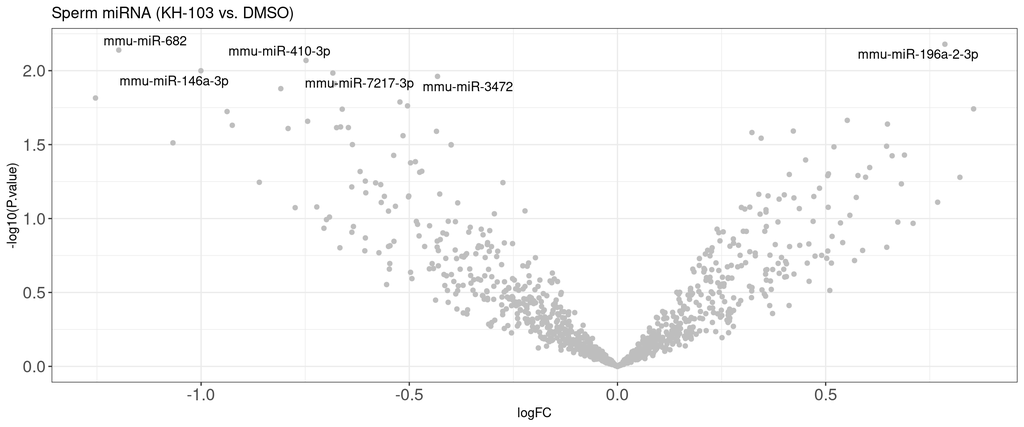

```r
# protac effect
res_mirna <- rowData(se_mirna)$DEA.voom.total_PROTAC_vs_DMSO
sig_anno_mirna <- rep("non", times = nrow(res_mirna))
sig_anno_mirna[which(res_mirna$adj.P.Val < 0.05 & res_mirna$logFC > 0)] <- "up"  # no ups
sig_anno_mirna[which(res_mirna$adj.P.Val < 0.05 & res_mirna$logFC< 0)] <- "down"  # no downs

res_mirna <- res_mirna[order(res_mirna$P.Value),]
res_mirna$miRNA <- basename(rownames(res_mirna))
res_mirna$sig_anno_mirna <- sig_anno_mirna


p_mirna <- ggplot(
  res_mirna,
  aes(x = logFC, y = -log10(P.Value), color = sig_anno_mirna)
) +
  geom_point() +
  scale_color_manual(
    values = c("up" = "red", "non" = "gray", "down" = "blue")
  ) +
  geom_text_repel(
    data = head(res_mirna),
    aes(label = miRNA),
    color = "black"
  ) +
  labs(
    x = "logFC",
    y = "-log10(P.value)",
    title = "Sperm miRNA (KH-103 vs. DMSO)"
  ) +
  theme_bw() +
  theme(legend.position = "none",axis.text.x = element_text(size=14),
          axis.text.y = element_text(size=14),
          legend.text = element_text(size=12),
          legend.title = element_text(size = 14)
    )

p_mirna
```

```r
#
#
ggsave("sup_plots/FigS5K_miRNA_totalPROTAC.svg")
ggsave("sup_plots/FigS5K_miRNA_totalPROTAC.pdf")
ggsave("sup_plots/FigS5K_miRNA_totalPROTAC.png")
```

tRNA:

```r
group <- factor(se_trna$group)
set.seed(8)
se_trna <- SEtools::svacor(se_trna, ~group, n.sv = 1)  # the suggested sv number is 2
```

```
## Number of significant surrogate variables is:  1
## Iteration (out of 5 ):1  2  3  4  5
```

```r
# counts filter
dge_for_filter <- DGEList(assay(se_trna, "counts"))
dge_for_filter <- calcNormFactors(dge_for_filter)
design_for_filter <- model.matrix(~ 0 + group, data = as.data.frame(colData(se_trna)))
keep <- filterByExpr(dge_for_filter, min.count = 5, design = design_for_filter)
se_trna  <- se_trna[keep, ]  # 145 kept

# voom
dge_trna <- DGEList(assay(se_trna, "counts"))
dge_trna <- calcNormFactors(dge_trna)
design_trna <- model.matrix(~ 0 + group + SV1, data = as.data.frame(colData(se_trna)))
# ── 2. First voom + first duplicateCorrelation pass ───────────────────────────
vobj_for_dupcor_trna <- voom(dge_trna, design_trna, plot = FALSE)
dupcor_trna <- duplicateCorrelation(vobj_for_dupcor_trna, design_trna, block = colData(se_trna)$donor)

# ── 3. Second voom pass, now informed by the donor correlation ─────────────────
vobj_trna <- voom(dge_trna, design_trna, plot = FALSE, block = colData(se_trna)$donor,
             correlation = dupcor_trna$consensus)

# ── 4. Second duplicateCorrelation pass on the better voom weights ─────────────
dupcor_trna <- duplicateCorrelation(vobj_trna, design_trna, block = colData(se_trna)$donor)

# ── 5. Fit the linear model ────────────────────────────────────────────────────
fit_trna <- lmFit(vobj_trna, design_trna, block=colData(se_trna)$donor, correlation = dupcor_trna$consensus)

contrast_trna <- makeContrasts(
  total_stress_vs_ctrl  = (groupstress_DMSO + groupstress_PROTAC)/2 - (groupctrl_DMSO + groupctrl_PROTAC)/2,
  DMSO_stress_vs_ctrl   = groupstress_DMSO - groupctrl_DMSO,
  PROTAC_stress_vs_ctrl = groupstress_PROTAC - groupctrl_PROTAC,
  total_PROTAC_vs_DMSO  = (groupstress_PROTAC + groupctrl_PROTAC)/2 - (groupstress_DMSO + groupctrl_DMSO)/2,
  ctrl_PROTAC_vs_DMSO   = groupctrl_PROTAC - groupctrl_DMSO,
  stress_PROTAC_vs_DMSO = groupstress_PROTAC - groupstress_DMSO,
  interaction           = (groupstress_PROTAC - groupctrl_PROTAC) - (groupstress_DMSO - groupctrl_DMSO),
  levels = design_trna
)

fit2_trna <- contrasts.fit(fit_trna, contrast_trna)
fit2_trna <- eBayes(fit2_trna)  # Empirical Bayes smoothing of standard errors

# extract each contrast table
rowData(se_trna)$DEA.voom.total_stress_vs_ctrl <- topTable(fit2_trna, coef = "total_stress_vs_ctrl", n = Inf)[rownames(se_trna),]
rowData(se_trna)$DEA.voom.DMSO_stress_vs_ctrl <- topTable(fit2_trna, coef = "DMSO_stress_vs_ctrl", n = Inf)[rownames(se_trna),]
rowData(se_trna)$DEA.voom.PROTAC_stress_vs_ctrl <- topTable(fit2_trna, coef = "PROTAC_stress_vs_ctrl", n = Inf)[rownames(se_trna),]
rowData(se_trna)$DEA.voom.total_PROTAC_vs_DMSO <- topTable(fit2_trna, coef = "total_PROTAC_vs_DMSO", n = Inf)[rownames(se_trna),]
rowData(se_trna)$DEA.voom.ctrl_PROTAC_vs_DMSO <- topTable(fit2_trna, coef = "ctrl_PROTAC_vs_DMSO", n = Inf)[rownames(se_trna),]
rowData(se_trna)$DEA.voom.stress_PROTAC_vs_DMSO <- topTable(fit2_trna, coef = "stress_PROTAC_vs_DMSO", n = Inf)[rownames(se_trna),]
rowData(se_trna)$DEA.voom.interaction <- topTable(fit2_trna, coef = "interaction", n = Inf)[rownames(se_trna),]

table(rownames(se_trna)== rownames(vobj_trna$E))
```

```
##
## TRUE
##  145
```

```r
assay(se_trna, "voom.val") <- vobj_trna$E

# table(rowData(se_trna)$DEA.voom.total_stress_vs_ctrl$adj.P.Val<0.05)  # no
# table(rowData(se_trna)$DEA.voom.DMSO_stress_vs_ctrl$adj.P.Val<0.05)   # no
# table(rowData(se_trna)$DEA.voom.PROTAC_stress_vs_ctrl$adj.P.Val<0.05) # no
# table(rowData(se_trna)$DEA.voom.total_PROTAC_vs_DMSO$adj.P.Val<0.05)  # no
# table(rowData(se_trna)$DEA.voom.stress_PROTAC_vs_DMSO$adj.P.Val<0.05) # no
# table(rowData(se_trna)$DEA.voom.ctrl_PROTAC_vs_DMSO$adj.P.Val<0.05)  # no
# table(rowData(se_trna)$DEA.voom.interaction$adj.P.Val<0.05)  # no
```

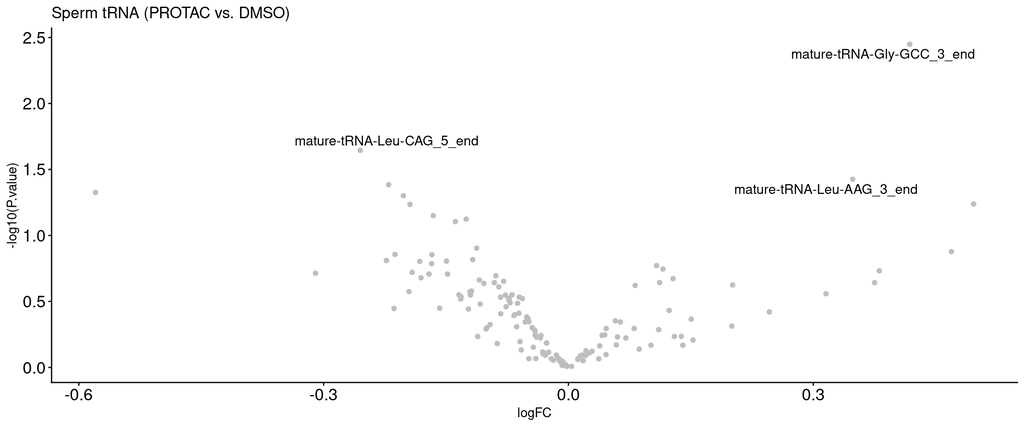

```r
# protac effect
res_trna <- rowData(se_trna)$DEA.voom.total_PROTAC_vs_DMSO
res_trna$tRNA <- basename(rownames(res_trna))
res_trna <- res_trna[order(res_trna$P.Value),]
sig_anno_trna <- rep("non", times = nrow(res_trna))
sig_anno_trna[which(res_trna$adj.P.Val < 0.05 & res_trna$logFC > 0)] <- "up"  # no ups
sig_anno_trna[which(res_trna$adj.P.Val < 0.05 & res_trna$logFC< 0)] <- "down"  # no downs

library(ggplot2)
library(ggrepel)

p_trna <- ggplot(
  res_trna,
  aes(x = logFC, y = -log10(P.Value))
) +
  geom_point(color = "grey") +
  geom_text_repel(
    data = head(res_trna, 3),
    aes(label = tRNA),
    max.overlaps = 20,
    size = 4
  ) +
  xlab("logFC") +
  ylab("-log10(P.value)") +
  labs(
    title = "Sperm tRNA (PROTAC vs. DMSO)"
  )+  theme(legend.position = "none",axis.text.x = element_text(size=14),
          axis.text.y = element_text(size=14),
          legend.text = element_text(size=12),
          legend.title = element_text(size = 14)
    )

p_trna
```

```r
ggsave("sup_plots/FigS5K_tRNA_totalPROTAC.svg")
ggsave("sup_plots/FigS5K_tRNA_totalPROTAC.pdf")
ggsave("sup_plots/FigS5K_tRNA_totalPROTAC.png")
```

small RNA together

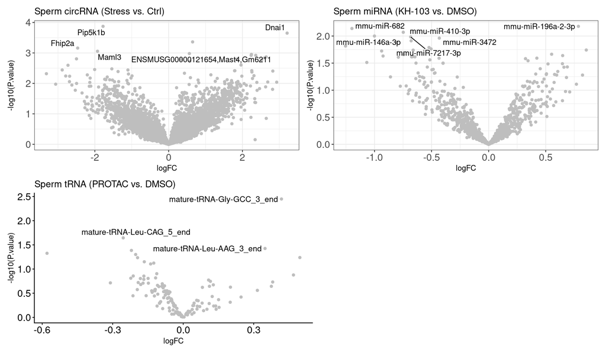

```r
(p+p_mirna)/(p_trna+plot_spacer())
```

```r
ggsave("sup_plots/FigS5K_smallRNA_volcanos.svg")
ggsave("sup_plots/FigS5K_smallRNA_volcanos.pdf")
ggsave("sup_plots/FigS5K_smallRNA_volcanos.png")
```

top3 tRNAs boxplot

```r
res_trna$gene <- sub(".*/", "", rownames(res_trna))

top3_trna_total_PROTAC_vs_DMSO <- res_trna[order(res_trna$P.Value),]$gene[1:3]
# [1] "tRNA-Gly-GCC_3_end" "tRNA-Leu-CAG_5_end" "tRNA-Leu-AAG_3_end"
```

top1: tRNA-Gly-GCC_3_end

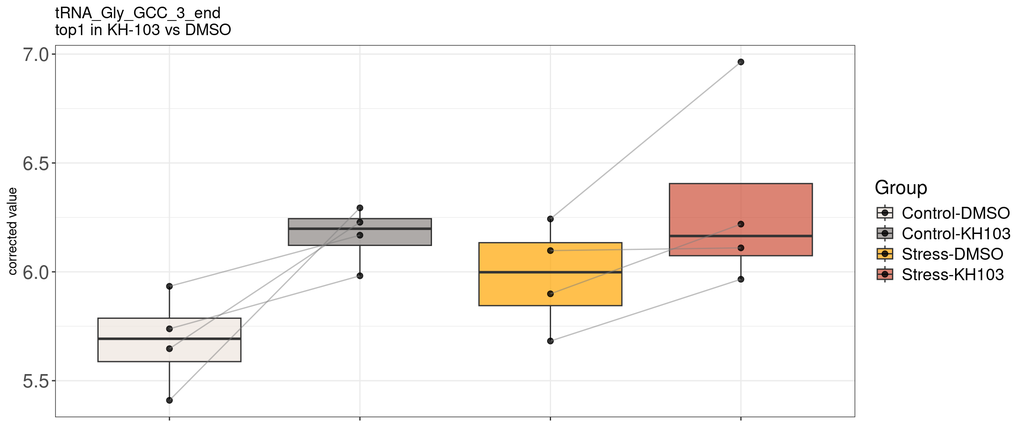

```r
tRNA_Gly_GCC_3_end <- assay(se_trna, "corrected")[which(rownames(se_trna)=="GtRNAdb-mature-tRNA_3_end_Match_Genome/mature-tRNA-Gly-GCC_3_end"),]

df_tRNA_Gly_GCC_3_end <- data.frame(
  sample = names(tRNA_Gly_GCC_3_end),
  stress = ifelse(substr(names(tRNA_Gly_GCC_3_end), 1, 1)=="C", "ctrl", "stress"),
  PROTAC = ifelse(substr(names(tRNA_Gly_GCC_3_end), nchar(names(tRNA_Gly_GCC_3_end)), nchar(names(tRNA_Gly_GCC_3_end)))=="D", "DMSO", "PROTAC"),
  count = tRNA_Gly_GCC_3_end
)
df_tRNA_Gly_GCC_3_end$group <- factor(paste0(df_tRNA_Gly_GCC_3_end$stress, "_", df_tRNA_Gly_GCC_3_end$PROTAC))

df_tRNA_Gly_GCC_3_end$group <- factor(
  df_tRNA_Gly_GCC_3_end$group,
  levels = c("ctrl_DMSO", "ctrl_PROTAC", "stress_DMSO", "stress_PROTAC"),
  labels= c("Control-DMSO","Control-KH103","Stress-DMSO","Stress-KH103")
)



df_tRNA_Gly_GCC_3_end$donor <- gsub("[^0-9]", "", df_tRNA_Gly_GCC_3_end$sample)
box_tRNA_Gly_GCC_3_end <- ggplot(data = df_tRNA_Gly_GCC_3_end, aes(x = group, y = count, fill = group)) + geom_boxplot(outlier.shape = NA, alpha = 0.7)+
  geom_point(width = 0.2, size = 2, alpha = 0.8) +
  geom_line(aes(group = donor), color = "grey50", alpha = 0.5) +
  theme_bw() +
  scale_fill_manual(values=c( "seashell2","seashell4","#ffa500ff","tomato3"))+
  labs(x = NULL, y = "corrected value",  title = "tRNA_Gly_GCC_3_end\ntop1 in KH-103 vs DMSO") +
  labs(fill = "Group")+
  theme(axis.text.x = element_blank(),
        axis.text.y = element_text(size=16),
        legend.text = element_text(size=14),
        legend.title = element_text(size = 16)
  )
box_tRNA_Gly_GCC_3_end
```

top2: tRNA_Leu_CAG_5_end

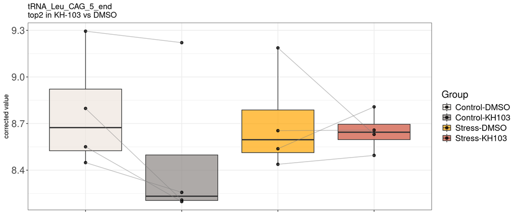

```r
tRNA_Leu_CAG_5_end <- assay(se_trna, "corrected")[which(rownames(se_trna)=="GtRNAdb-mature-tRNA_5_end_Match_Genome/mature-tRNA-Leu-CAG_5_end"),]

df_tRNA_Leu_CAG_5_end <- data.frame(
  sample = names(tRNA_Leu_CAG_5_end),
  stress = ifelse(substr(names(tRNA_Leu_CAG_5_end), 1, 1)=="C", "ctrl", "stress"),
  PROTAC = ifelse(substr(names(tRNA_Leu_CAG_5_end), nchar(names(tRNA_Leu_CAG_5_end)), nchar(names(tRNA_Leu_CAG_5_end)))=="D", "DMSO", "PROTAC"),
  count = tRNA_Leu_CAG_5_end
)
df_tRNA_Leu_CAG_5_end$group <- factor(paste0(df_tRNA_Leu_CAG_5_end$stress, "_", df_tRNA_Leu_CAG_5_end$PROTAC))
df_tRNA_Leu_CAG_5_end$group <- factor(
  df_tRNA_Leu_CAG_5_end$group,
  levels = c("ctrl_DMSO", "ctrl_PROTAC", "stress_DMSO", "stress_PROTAC"),
  labels= c("Control-DMSO","Control-KH103","Stress-DMSO","Stress-KH103")
)



df_tRNA_Leu_CAG_5_end$donor <- gsub("[^0-9]", "", df_tRNA_Leu_CAG_5_end$sample)
box_tRNA_Leu_CAG_5_end <- ggplot(data = df_tRNA_Leu_CAG_5_end, aes(x = group, y = count, fill = group)) + geom_boxplot(outlier.shape = NA, alpha = 0.7)+
  geom_point(width = 0.2, size = 2, alpha = 0.8) +
  geom_line(aes(group = donor), color = "grey50", alpha = 0.5) +
  theme_bw() +
    scale_fill_manual(values=c( "seashell2","seashell4","#ffa500ff","tomato3"))+
  labs(x = NULL, y = "corrected value",  title = "tRNA_Leu_CAG_5_end\ntop2 in KH-103 vs DMSO") +
  labs(fill = "Group")+
  theme(axis.text.x = element_blank(),
        axis.text.y = element_text(size=16),
        legend.text = element_text(size=14),
        legend.title = element_text(size = 16)
  )
box_tRNA_Leu_CAG_5_end
```

top3: tRNA-Leu-AAG_3_end

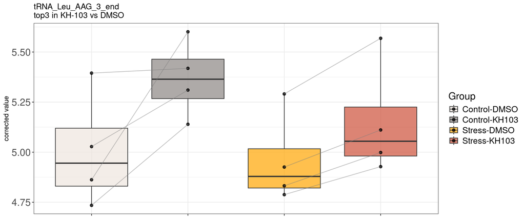

```r
tRNA_Leu_AAG_3_end <- assay(se_trna, "corrected")[which(rownames(se_trna)=="GtRNAdb-mature-tRNA_3_end_Match_Genome/mature-tRNA-Leu-AAG_3_end"),]

df_tRNA_Leu_AAG_3_end <- data.frame(
  sample = names(tRNA_Leu_AAG_3_end),
  stress = ifelse(substr(names(tRNA_Leu_AAG_3_end), 1, 1)=="C", "ctrl", "stress"),
  PROTAC = ifelse(substr(names(tRNA_Leu_AAG_3_end), nchar(names(tRNA_Leu_AAG_3_end)), nchar(names(tRNA_Leu_AAG_3_end)))=="D", "DMSO", "PROTAC"),
  count = tRNA_Leu_AAG_3_end
)
df_tRNA_Leu_AAG_3_end$group <- factor(paste0(df_tRNA_Leu_AAG_3_end$stress, "_", df_tRNA_Leu_AAG_3_end$PROTAC))

df_tRNA_Leu_AAG_3_end$group <- factor(
  df_tRNA_Leu_AAG_3_end$group,
  levels = c("ctrl_DMSO", "ctrl_PROTAC", "stress_DMSO", "stress_PROTAC"),
  labels= c("Control-DMSO","Control-KH103","Stress-DMSO","Stress-KH103")
)

df_tRNA_Leu_AAG_3_end$donor <- gsub("[^0-9]", "", df_tRNA_Leu_AAG_3_end$sample)


box_tRNA_Leu_AAG_3_end <- ggplot(data = df_tRNA_Leu_AAG_3_end, aes(x = group, y = count, fill = group)) + geom_boxplot(outlier.shape = NA, alpha = 0.7)+
  geom_point(width = 0.2, size = 2, alpha = 0.8) +
  geom_line(aes(group = donor), color = "grey50", alpha = 0.5) +
  theme_bw() +
  scale_fill_manual(values=c( "seashell2","seashell4","#ffa500ff","tomato3")
                    )+
  labs(fill = "Group")+
  labs(x = NULL, y = "corrected value",  title = "tRNA_Leu_AAG_3_end\ntop3 in KH-103 vs DMSO") +
  theme(axis.text.x = element_blank(), #size=16, angle = 30, hjust = 1
        axis.text.y = element_text(size=16),
        legend.text = element_text(size=14),
        legend.title = element_text(size = 16)
  )
box_tRNA_Leu_AAG_3_end
```

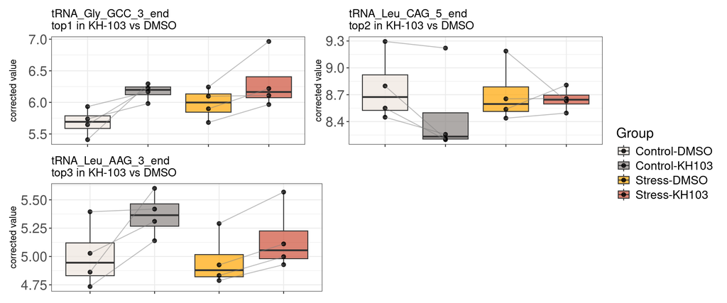

```r
# library(patchwork)

(
  box_tRNA_Gly_GCC_3_end +
  box_tRNA_Leu_CAG_5_end
) /
(
  box_tRNA_Leu_AAG_3_end +
  guide_area()
) +
plot_layout(guides = "collect")
```

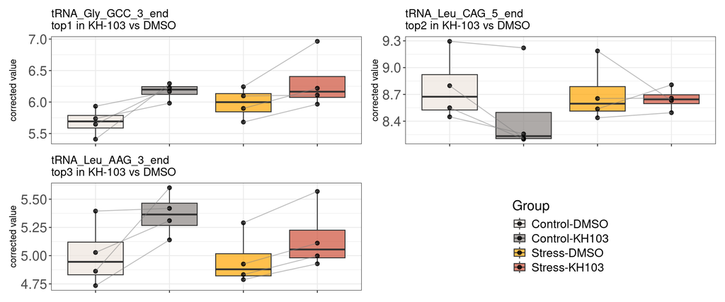

```r
library(patchwork)

(
  box_tRNA_Gly_GCC_3_end +
  box_tRNA_Leu_CAG_5_end +
  box_tRNA_Leu_AAG_3_end +
  guide_area()
) +
plot_layout(
  design = "
  AB
  CD
  ",
  guides = "collect"
) &
theme(legend.position = "right")
```

```r
ggsave("sup_plots/FigS5K_tRNA_top3.svg")
ggsave("sup_plots/FigS5K_tRNA_top3.pdf")
ggsave("sup_plots/FigS5K_tRNA_top3.png")
```

## 46.12 Fig S5L KH-103 effect on stress affected GR binding long RNA (p < 0.01)

```r
se <- readRDS("objects/countMatrix_longRNA_sperm.SE.rds")
metadata(se)$anno_colors <- list(
  stress=c(ctrl="steelblue", ifs ="firebrick3"),
  protac = c(PROTAC = "gray", DMSO = "navy"),
  group = c("ctrl_DMSO" = "seashell2", "ifs_DMSO" =  "#ffa500ff" , "ctrl_PROTAC" = "seashell4" , "ifs_PROTAC" = "tomato3"))

se$group <- factor(paste0(se$stress, "_", se$protac))

dge_for_filter <- DGEList(assay(se, "counts"))
dge_for_filter <- calcNormFactors(dge_for_filter)
design_for_filter <- model.matrix(~ 0 + group, data = as.data.frame(colData(se)))
# Filter using the temporary design matrix
keep <- filterByExpr(dge_for_filter, min.count = 20, design = design_for_filter)
se  <- se[keep, ]
# add donor info
colData(se)$donor <- sub("^(C[0-9]+|I[0-9]+)[DK]$", "\\1", colData(se)$sampleid)
colData(se)$donor <- factor(colData(se)$donor)

# voom
dge <- DGEList(assay(se, "counts"))
dge <- calcNormFactors(dge)
design <- model.matrix(~ 0 + group, data = as.data.frame(colData(se)))

# also calculate logcpm
assay(se, "logcpm") <- log1p(edgeR::cpm(dge)[rownames(se),])
```

```r
# ── 2. First voom + first duplicateCorrelation pass ───────────────────────────
vobj_for_dupcor <- voom(dge, design, plot = FALSE)
dupcor <- duplicateCorrelation(vobj_for_dupcor, design, block = colData(se)$donor)

# ── 3. Second voom pass, now informed by the donor correlation ─────────────────
vobj <- voom(dge, design, plot = FALSE,
             block       = colData(se)$donor,
             correlation = dupcor$consensus)

# ── 4. Second duplicateCorrelation pass on the better voom weights ─────────────
dupcor <- duplicateCorrelation(vobj, design, block = colData(se)$donor)

# ── 5. Fit the linear model ────────────────────────────────────────────────────
fit <- lmFit(vobj, design, block=colData(se)$donor, correlation = dupcor$consensus)

contrast <- makeContrasts(
  total_stress_vs_ctrl  = (groupifs_DMSO + groupifs_PROTAC)/2 - (groupctrl_DMSO + groupctrl_PROTAC)/2,
  DMSO_stress_vs_ctrl   = groupifs_DMSO - groupctrl_DMSO,
  PROTAC_stress_vs_ctrl = groupifs_PROTAC - groupctrl_PROTAC,
  total_PROTAC_vs_DMSO  = (groupifs_PROTAC + groupctrl_PROTAC)/2 - (groupifs_DMSO + groupctrl_DMSO)/2,
  ctrl_PROTAC_vs_DMSO   = groupctrl_PROTAC - groupctrl_DMSO,
  stress_PROTAC_vs_DMSO = groupifs_PROTAC - groupifs_DMSO,
  interaction           = (groupifs_PROTAC - groupctrl_PROTAC) - (groupifs_DMSO - groupctrl_DMSO),
  levels = design
)

fit2 <- contrasts.fit(fit, contrast)
fit2 <- eBayes(fit2)  # Empirical Bayes smoothing of standard errors

# extract each contrast table
rowData(se)$DEA.voom.total_stress_vs_ctrl <- topTable(fit2, coef = "total_stress_vs_ctrl", n = Inf)[rownames(se),]
rowData(se)$DEA.voom.DMSO_stress_vs_ctrl <- topTable(fit2, coef = "DMSO_stress_vs_ctrl", n = Inf)[rownames(se),]
rowData(se)$DEA.voom.PROTAC_stress_vs_ctrl <- topTable(fit2, coef = "PROTAC_stress_vs_ctrl", n = Inf)[rownames(se),]
rowData(se)$DEA.voom.total_PROTAC_vs_DMSO <- topTable(fit2, coef = "total_PROTAC_vs_DMSO", n = Inf)[rownames(se),]
rowData(se)$DEA.voom.ctrl_PROTAC_vs_DMSO <- topTable(fit2, coef = "ctrl_PROTAC_vs_DMSO", n = Inf)[rownames(se),]
rowData(se)$DEA.voom.stress_PROTAC_vs_DMSO <- topTable(fit2, coef = "stress_PROTAC_vs_DMSO", n = Inf)[rownames(se),]
rowData(se)$DEA.voom.interaction <- topTable(fit2, coef = "interaction", n = Inf)[rownames(se),]
```

```r
se_heatmap <- se[, order(se$protac, se$stress)]


semisig <- rowData(se)$DEA.voom.total_stress_vs_ctrl[rowData(se)$DEA.voom.total_stress_vs_ctrl$P.Value<0.01, ]
```

```r
se <- log2FC(se, fromAssay = "logcpm", controls = se$protac == "DMSO", by = se$stress, isLog = TRUE)
cd <- as.data.frame(colData(se))
cd$scaledLFC <- colMeans(assay(se, "scaledLFC"))

mod <- lme4::lmer(scaledLFC ~ 0 + group + (1|donor), data = cd)
mod2 <- emmeans::emmeans(mod, ~ 0 + group)
cont <- makeContrasts(
      total_stress_vs_ctrl  = (ifs_DMSO + ifs_PROTAC)/2 - (ctrl_DMSO + ctrl_PROTAC)/2,
      DMSO_stress_vs_ctrl   = ifs_DMSO - ctrl_DMSO,
      PROTAC_stress_vs_ctrl = ifs_PROTAC - ctrl_PROTAC,
      total_PROTAC_vs_DMSO  = (ifs_PROTAC + ctrl_PROTAC)/2 - (ifs_DMSO + ctrl_DMSO)/2,
      ctrl_PROTAC_vs_DMSO   = ctrl_PROTAC - ctrl_DMSO,
      stress_PROTAC_vs_DMSO = ifs_PROTAC - ifs_DMSO,
      interaction           = (ifs_PROTAC - ctrl_PROTAC) - (ifs_DMSO - ctrl_DMSO),
      levels = levels(cd$group))

# contrast(mod2, as.list(as.data.frame(cont)))

# GR-binders:
mmu_sig_rip_by_OmicsBridge <- openxlsx::read.xlsx("objects/mmu_rip_gene_name.xlsx", colNames = FALSE) # this is the GR binding RNA list
GR_semisig <- intersect(rownames(semisig), mmu_sig_rip_by_OmicsBridge$X1) # 67
se_GR_semisig <- se[GR_semisig, ]
df_se_GR_semisig_logFC <- rowMeans(assay(se_GR_semisig, "log2FC")[,se_GR_semisig$protac=="PROTAC"])
n_down <- sum(df_se_GR_semisig_logFC<0)  # 60
N <- length(df_se_GR_semisig_logFC)  # 67

se_semisig <- se[rownames(semisig),]  # 952 genes
logFC_general <- rowMeans(assay(se_semisig, "log2FC")[,se_semisig$protac=="PROTAC"])
p_general <- sum(logFC_general<0)/length(logFC_general)
binom.test(n_down, N, p = p_general, alternative = "two.sided")
```

```
##
##  Exact binomial test
##
## data:  n_down and N
## number of successes = 60, number of trials = 67, p-value = 0.000163
## alternative hypothesis: true probability of success is not equal to 0.697479
## 95 percent confidence interval:
##  0.7965108 0.9569506
## sample estimates:
## probability of success
##              0.8955224
```

```r
# to plot the heatmap, use the normalization to donor
se_GR_semisig_for_heatmap <- se_GR_semisig
se_GR_semisig_for_heatmap <- log2FC(se_GR_semisig_for_heatmap, fromAssay = "logcpm", controls = se_GR_semisig_for_heatmap$protac == "DMSO", by = se_GR_semisig_for_heatmap$donor, isLog = TRUE)


rowData(se_GR_semisig_for_heatmap)$direction <- ifelse(df_se_GR_semisig_logFC[rownames(se_GR_semisig_for_heatmap)]>0,yes = "up",no = "down")
# ========
sechm(
  se_GR_semisig_for_heatmap,
  names(df_se_GR_semisig_logFC),
  assayName = "scaledLFC",
  cluster_rows = F,
  top_annotation = c("stress", "protac"),
  hmcols =colorRampPalette(c("blue", "black", "orange"))(101),
  gaps_at = c("protac"),gaps_row = "direction"
  )
# ==================
```

[output not shown]

```r
sh <-  sechm(
  se_GR_semisig_for_heatmap[,se_GR_semisig_for_heatmap$protac == "PROTAC"],
   names(se_GR_semisig_for_heatmap),
  show_rownames = T,
  assayName = "scaledLFC",
  cluster_rows = F,
  sortRowsOn = colnames(se_GR_semisig_for_heatmap[,se_GR_semisig_for_heatmap$protac == "PROTAC"]),
  top_annotation = c("protac"),
  hmcols =colorRampPalette(c("blue", "black", "orange"))(101),
  gaps_at = c("protac"),
  gaps_row = "direction",
  column_title = "KH-103 effect on stress affected GR binding long RNA (p < 0.01)", use_raster = TRUE,
 show_row_dend = FALSE,
 row_names_gp = grid::gpar(fontsize = 10)
 # do.sortRows=TRUE
  )

sh

pdf("sup_plots/FigS5L_longRNA_Heatmap_stresseaffected.pdf", width=8.0, height=9.0) #, width=14.5, height=10)

print(sh)
dev.off()
```

[output not shown]

```r
png("sup_plots/FigS5L_longRNA_Heatmap_stresseaffected.png", height=650,width = 500,)

print(sh)
dev.off()
```

```r
svg("sup_plots/FigS5L_longRNA_Heatmap_stresseaffected.svg", width=10, height=8.5) #, width=14.5, height=10)

print(sh)
dev.off()
```

```r
mmu_sig_rip_by_OmicsBridge <- openxlsx::read.xlsx("objects/mmu_rip_gene_name.xlsx", colNames = FALSE) # this is the GR binding RNA list
GRbindingRNA_sig <- intersect(mmu_sig_rip_by_OmicsBridge$X1, rownames(semisig))

GRbindingRNA_sig2 <- intersect(mmu_sig_rip_by_OmicsBridge$X1, rownames(semisig2))

e2c <- readRDS("objects/SummarizedExperimentObject_EmbryoFromIFS_Sperm_treatedKH103.SE.rds")
```

```r
res_e2c_protac <- rowData(e2c)$DEA.Total_PROTACvsDMSO
res_e2c_protac <- res_e2c_protac[!duplicated(sub(".*\\.", "", rownames(res_e2c_protac))),]
rownames(res_e2c_protac) <- sub(".*\\.", "", rownames(res_e2c_protac))

res_sperm_protac <- rowData(se)$DEA.voom.total_PROTAC_vs_DMSO


ov_protac <- GRbindingRNA_sig[GRbindingRNA_sig %in% rownames(res_e2c_protac)]  # 57 of them are expressed in the embryos

cor_protac <- data.frame(
  gene = ov_protac,
  embryo_logFC = res_e2c_protac[ov_protac, ]$logFC,
  sperm_logFC = res_sperm_protac[ov_protac, ]$logFC
)
```

```r
res_e2c_stress <- rowData(e2c)$DEA.Total_IFSvsCTRL
res_e2c_stress <- res_e2c_stress[!duplicated(sub(".*\\.", "", rownames(res_e2c_stress))),]
rownames(res_e2c_stress) <- sub(".*\\.", "", rownames(res_e2c_stress))

res_sperm_stress <- rowData(se)$DEA.voom.total_stress_vs_ctrl


ov_stress <- GRbindingRNA_sig[GRbindingRNA_sig %in% rownames(res_e2c_stress)]

cor_stress <- data.frame(
  gene = ov_stress,
  embryo_logFC = res_e2c_stress[ov_stress, ]$logFC,
  sperm_logFC = res_sperm_stress[ov_stress, ]$logFC
)
```

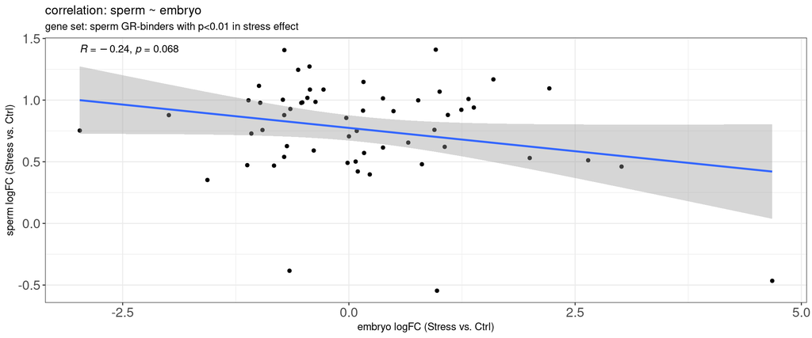

```r
p2 <- ggplot(data = cor_stress, aes(x = embryo_logFC, y = sperm_logFC)) +
    geom_point() +
    geom_smooth(method = "lm") +
    labs(x="embryo logFC (Stress vs. Ctrl)",
         y="sperm logFC (Stress vs. Ctrl)",
         title = "correlation: sperm ~ embryo",
         subtitle = "gene set: sperm GR-binders with p<0.01 in stress effect") +
    stat_cor(method = "pearson",
             label.x = min(cor_stress$embryo_logFC), # position of the label
             label.y = max(cor_stress$sperm_logFC)) +
    theme_bw() +
    theme(axis.text.x = element_text(size=14),
          axis.text.y = element_text(size=14),
          legend.text = element_text(size=12),
          legend.title = element_text(size = 14)
    )
p2
```

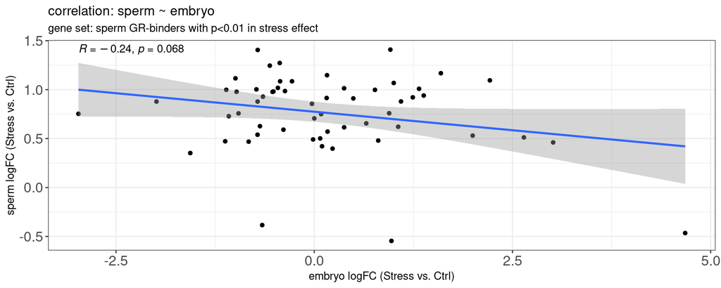

```r
p2
```

```r
ggsave("sup_plots/FigS5H_longRNA_corr.svg")
ggsave("sup_plots/FigS5H_longRNA_corr.pdf")
ggsave("sup_plots/FigS5H_longRNA_corr.png")
```

## 46.14 Fig S5N Heatmap of differential expressed genes in 2-cell embryos by IFS fathers

```r
se <- readRDS("objects/IFS_smartSeq_embryo_salmon.SE.rds")
meta <- openxlsx::read.xlsx("objects/IFS_smartSeq_embryo_meta.xlsx",colNames = T)
meta <- meta[order(meta$Sample),]
meta <- meta[meta$Sample %in% colnames(se),]
table(meta$Sample == colnames(se))
```

```
##
## TRUE
##   17
```

```r
se$embryos <- as.factor(meta$embryos)

Group <- factor(paste(se$treatment,se$condition,sep="."))


se$Group <- Group

set.seed(123)
se$Group2 <- sample(Group,size = 17,replace = F)
# colData(se)
# meta$Sample
```

```r
set.seed(123)
se <- SEtools::svacor(se, ~Group+embryos,form0 = ~embryos, n.sv = 3)
```

```
## Number of significant surrogate variables is:  3
## Iteration (out of 5 ):1  2  3  4  5
```

```r
dds <- calcNormFactors(DGEList(assay(se))) # this calculates Normalization factors according to library sequencing depth, this is important since depth can vary greatly between samples

### lets look at the library size
# dds$samples



assays(se)$logcpm <- log1p(edgeR::cpm(dds)) # generates the log of Counts-per-million (CPM), this is a very standardized way to normalize data used then for analysis or visualisation




mm <- model.matrix(~0+Group+SV1+SV2+embryos, data=as.data.frame(colData(se))); mm
```

```
##     GroupDMSO.CTRL GroupDMSO.IFS GroupPROTAC.CTRL GroupPROTAC.IFS         SV1
## CD1              1             0                0               0 -0.18273994
## CD2              1             0                0               0 -0.09108553
## CD3              1             0                0               0 -0.07417272
## CD4              1             0                0               0 -0.13248488
## CK1              0             0                1               0 -0.12277701
## CK2              0             0                1               0  0.32064701
## CK3              0             0                1               0 -0.13230089
## CK4              0             0                1               0 -0.15360579
## CK5              0             0                1               0 -0.12398405
## CK6              0             0                1               0 -0.11302004
## ID2              0             1                0               0  0.77254440
## ID3              0             1                0               0 -0.05730034
## ID4              0             1                0               0 -0.10442061
## IK1              0             0                0               1 -0.12946001
## IK2              0             0                0               1 -0.13040685
## IK4              0             0                0               1  0.23114367
## IK5              0             0                0               1  0.22342356
##             SV2 embryos2 embryos3
## CD1 -0.12339638        0        0
## CD2  0.04765953        0        0
## CD3 -0.04670839        0        0
## CD4 -0.16425067        0        1
## CK1 -0.05133676        0        0
## CK2  0.06102469        0        1
## CK3 -0.11722750        0        0
## CK4 -0.06160861        0        0
## CK5 -0.04255255        0        1
## CK6 -0.06394109        0        0
## ID2 -0.49588056        0        0
## ID3  0.03415039        0        0
## ID4 -0.01417419        0        0
## IK1 -0.08646059        1        0
## IK2 -0.02867972        0        0
## IK4  0.53902656        1        0
## IK5  0.61435585        0        0
## attr(,"assign")
## [1] 1 1 1 1 2 3 4 4
## attr(,"contrasts")
## attr(,"contrasts")$Group
## [1] "contr.treatment"
##
## attr(,"contrasts")$embryos
## [1] "contr.treatment"
```

```r
dds <- dds[filterByExpr(dds, group = Group, min.count=20),] # 20 maybe to stringent for embryo data
dds <- estimateDisp(dds,design = mm)
se <- se[row.names(dds),]

fit <- glmFit(dds, mm, prior.count = 5) # we us prior.count 5 since we are working with low count data
```

Creating contrasts

```r
fit$design
```

```
##     GroupDMSO.CTRL GroupDMSO.IFS GroupPROTAC.CTRL GroupPROTAC.IFS         SV1
## CD1              1             0                0               0 -0.18273994
## CD2              1             0                0               0 -0.09108553
## CD3              1             0                0               0 -0.07417272
## CD4              1             0                0               0 -0.13248488
## CK1              0             0                1               0 -0.12277701
## CK2              0             0                1               0  0.32064701
## CK3              0             0                1               0 -0.13230089
## CK4              0             0                1               0 -0.15360579
## CK5              0             0                1               0 -0.12398405
## CK6              0             0                1               0 -0.11302004
## ID2              0             1                0               0  0.77254440
## ID3              0             1                0               0 -0.05730034
## ID4              0             1                0               0 -0.10442061
## IK1              0             0                0               1 -0.12946001
## IK2              0             0                0               1 -0.13040685
## IK4              0             0                0               1  0.23114367
## IK5              0             0                0               1  0.22342356
##             SV2 embryos2 embryos3
## CD1 -0.12339638        0        0
## CD2  0.04765953        0        0
## CD3 -0.04670839        0        0
## CD4 -0.16425067        0        1
## CK1 -0.05133676        0        0
## CK2  0.06102469        0        1
## CK3 -0.11722750        0        0
## CK4 -0.06160861        0        0
## CK5 -0.04255255        0        1
## CK6 -0.06394109        0        0
## ID2 -0.49588056        0        0
## ID3  0.03415039        0        0
## ID4 -0.01417419        0        0
## IK1 -0.08646059        1        0
## IK2 -0.02867972        0        0
## IK4  0.53902656        1        0
## IK5  0.61435585        0        0
## attr(,"assign")
## [1] 1 1 1 1 2 3 4 4
## attr(,"contrasts")
## attr(,"contrasts")$Group
## [1] "contr.treatment"
##
## attr(,"contrasts")$embryos
## [1] "contr.treatment"
```

```r
my.contrast <- makeContrasts(
  DMSO_IFSvsCTRL = GroupDMSO.IFS - GroupDMSO.CTRL ,
  PROTAC_IFSvsCTRL = GroupPROTAC.IFS - GroupPROTAC.CTRL,
  IFS_PROTACvsDMSO = GroupPROTAC.IFS - GroupDMSO.IFS,
  CTRL_PROTACvsDMSO = GroupPROTAC.CTRL - GroupDMSO.CTRL,
  IFS_PROTAC_int = ((GroupPROTAC.IFS - GroupPROTAC.CTRL) - (GroupDMSO.IFS - GroupDMSO.CTRL)), # interaction term

  Total_IFSvsCTRL = (GroupDMSO.IFS - GroupDMSO.CTRL + GroupPROTAC.IFS - GroupPROTAC.CTRL)/2,
  Total_PROTACvsDMSO =  (GroupPROTAC.IFS - GroupDMSO.IFS + GroupPROTAC.CTRL - GroupDMSO.CTRL)/2,
  levels = mm
)
my.contrast
```

```
##                   Contrasts
## Levels             DMSO_IFSvsCTRL PROTAC_IFSvsCTRL IFS_PROTACvsDMSO
##   GroupDMSO.CTRL               -1                0                0
##   GroupDMSO.IFS                 1                0               -1
##   GroupPROTAC.CTRL              0               -1                0
##   GroupPROTAC.IFS               0                1                1
##   SV1                           0                0                0
##   SV2                           0                0                0
##   embryos2                      0                0                0
##   embryos3                      0                0                0
##                   Contrasts
## Levels             CTRL_PROTACvsDMSO IFS_PROTAC_int Total_IFSvsCTRL
##   GroupDMSO.CTRL                  -1              1            -0.5
##   GroupDMSO.IFS                    0             -1             0.5
##   GroupPROTAC.CTRL                 1             -1            -0.5
##   GroupPROTAC.IFS                  0              1             0.5
##   SV1                              0              0             0.0
##   SV2                              0              0             0.0
##   embryos2                         0              0             0.0
##   embryos3                         0              0             0.0
##                   Contrasts
## Levels             Total_PROTACvsDMSO
##   GroupDMSO.CTRL                 -0.5
##   GroupDMSO.IFS                  -0.5
##   GroupPROTAC.CTRL                0.5
##   GroupPROTAC.IFS                 0.5
##   SV1                             0.0
##   SV2                             0.0
##   embryos2                        0.0
##   embryos3                        0.0
```

```r
Results <- list()

for (con in colnames(my.contrast)){
  Results[[con]] <- as.data.frame(topTags(glmLRT(fit,contrast = my.contrast[,con]),Inf))
  Results[[con]]$ID <- gsub(x = rownames(Results[[con]]),pattern = "ENS(.*)\\.",replacement = "")
  Results[[con]]$DEA <- con
}
# Results
# write.csv(Results$DMSO_IFSvsCTRL$ID[Results$DMSO_IFSvsCTRL$FDR < 0.05],"trial.csv")
```

```r
se <- log2FC(se, fromAssay = "corrected",controls = se$condition == "CTRL",isLog = F,by = se$treatment)#
```

```r
color_palette <- colorRampPalette(c("blue", "black", "orange"))(101)
rownames(se) <- gsub(x = rownames(se),pattern = "^ENS(.*)\\.",replacement = "")



sh <- sechm(se,features = Results$Total_IFSvsCTRL$ID[Results$Total_IFSvsCTRL$FDR <0.05],assayName = "scaledLFC",hmcols = color_palette,do.scale =F,gaps_at = c("treatment"),column_order = colnames(se)[order(colData(se)$condition)],show_rownames = F,name = paste0("StressGenes","\nlog2FC"),top_annotation = c("Group"),use_raster = T,column_title = "Stress effect in 2-cell embryos\nupon parternal stress and sperm treatment",column_title_gp = gpar(fontsize = 20))
print(sh)



pdf("sup_plots/FigS5N.StressGenes.heatmap.pdf", width=14.5, height=10) #, width=14.5, height=10)

print(sh)
dev.off()
```

[output not shown]

```r
png("sup_plots/FigS5N.StressGenes.heatmap.png", height=516,width = 758,)

print(sh)
dev.off()
```

```r
svg("sup_plots/FigS5N.StressGenes.heatmap.svg") #, width=14.5, height=10)

print(sh)
dev.off()
```

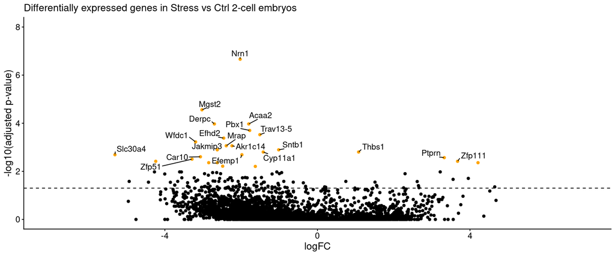

```r
library(scales)
dea <- Results$Total_IFSvsCTRL


xlim <- c(-7, 7)
ylim <- c(0,8)

# Function to generate volcano plots
generate_volcano_plot <- function(df, title) {
  df$highlight <- df$FDR < 0.01
  df$extreme[df$logFC > xlim[2] | df$logFC < xlim[1] | -log10(df$FDR) > ylim[2] | -log10(df$FDR) < ylim[1]] <- "extreme"
  df$highlight[df$extreme == "extreme"] <- "extreme"
  top_genes <- df[order(df$FDR), ][1:20, ]
  ggplot(df, aes(x=logFC, y=-log10(FDR))) +
    geom_point(aes(color = highlight)) +
    scale_color_manual(values = c("TRUE" = "orange", "FALSE" = "black", "extreme" = "firebrick3")) +
    geom_text_repel(data = subset(top_genes, highlight == TRUE | highlight == "extreme"), aes(label=ID), size=4, min.segment.length = 0, max.overlaps = Inf, nudge_y = 0.1) +
    geom_hline(yintercept=-log10(0.05), linetype="dashed")+
    xlab("logFC") +
    ylab("-log10(adjusted p-value)") +
    # theme_classic() +

    scale_x_continuous(limits = xlim, oob = squish) +
    scale_y_continuous(limits = ylim, oob = squish) +
    ggtitle(title)+
    theme(
  text       = element_text(size = 12),
  axis.text  = element_text(size = 12),
  axis.title = element_text(size = 14),
  plot.title = element_text(size = 14),
  legend.position = "none"
)
}

# Apply the function to each dataframe in the list
generate_volcano_plot(dea, "Differentially expressed genes in Stress vs Ctrl 2-cell embryos")
```

```r
ggsave("sup_plots/FigS5N_DEGs_TotalStressVsCtrl.svg")
ggsave("sup_plots/FigS5N_DEGs_TotalStressVsCtrl.pdf")
ggsave("sup_plots/FigS5N_DEGs_TotalStressVsCtrl.png")
```

## 46.15 Fig S5O signal tracks Sntb1

```r
region <- "15:55547263-55548085"
name <-"Sntb1"
```

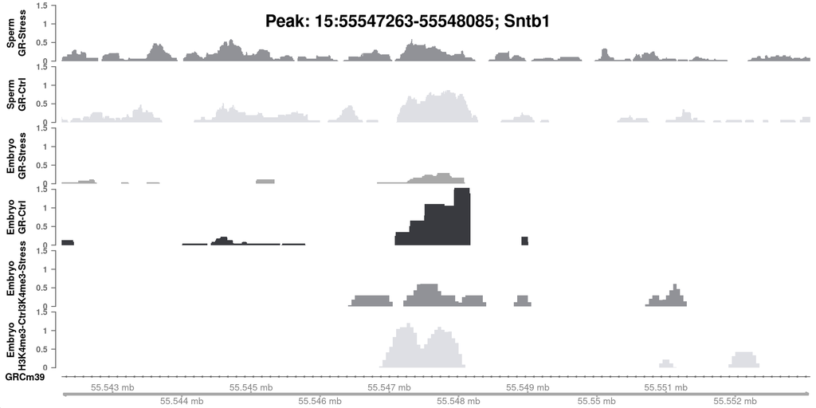

```r
plotSignalTracks(files = bw_groups,overlay.alpha = 75,region = region,aggregation = "mean",colors = colors ,genomeAxis = T,ensdb = ensdb,extend = c(5000,5000),ylim= c(0,1.5), fontface.main = 1,cex.main = 1,cex.id=0.9,cex.title = 0.7) # , rotation.title = 0
grid.text(paste0("Peak: ",region,"; ",name), x = 0.5, y = 0.95, gp = gpar(fontsize = 15, fontface = "bold"))
```

```r
png(paste0("sup_plots/FigS5O_Sntb1.png"), width=750, height=750)
plotSignalTracks(files = bw_groups,overlay.alpha = 75,region = region,aggregation = "mean",colors = colors ,genomeAxis = T,ensdb = ensdb,extend = c(5000,5000),ylim= c(0,1.5),fontface.main = 1.4,cex.main = 0.9,cex.id=0.9,cex.title = 0.9) # , rotation.title = 0
grid.text(paste0("Peak: ",region,"; ",name), x = 0.5, y = 0.95, gp = gpar(fontsize = 15, fontface = "bold"))
dev.off()
```

```r
pdf(paste0("sup_plots/FigS5O_Sntb1.pdf"), width=8, height=8,colormodel = "cymk")
plotSignalTracks(files = bw_groups,overlay.alpha = 75,region = region,aggregation = "mean",colors = colors ,genomeAxis = T,ensdb = ensdb,extend = c(5000,5000),ylim= c(0,1.5),, fontface.main = 1.4,cex.main = 0.9,cex.id=0.9,cex.title = 0.9) # , rotation.title = 0
grid.text(paste0("Peak: ",region,"; ",name), x = 0.5, y = 0.95, gp = gpar(fontsize = 15, fontface = "bold"))
dev.off()
```

```r
svg(paste0("sup_plots/FigS5O_Sntb1.svg"), width=8, height=8)
plotSignalTracks(files = bw_groups,overlay.alpha = 75,region = region,aggregation = "mean",colors = colors ,genomeAxis = T,ensdb = ensdb,extend = c(5000,5000),ylim= c(0,1.5), fontface.main = 1.4,cex.main = 0.9,cex.id=0.9,cex.title = 0.9) # , rotation.title = 0
grid.text(paste0("Peak: ",region,"; ",name), x = 0.5, y = 0.95, gp = gpar(fontsize = 15, fontface = "bold"))
dev.off()
```

## 46.16 Fig S5P GO:BP 2-cell embryos of paternal stress

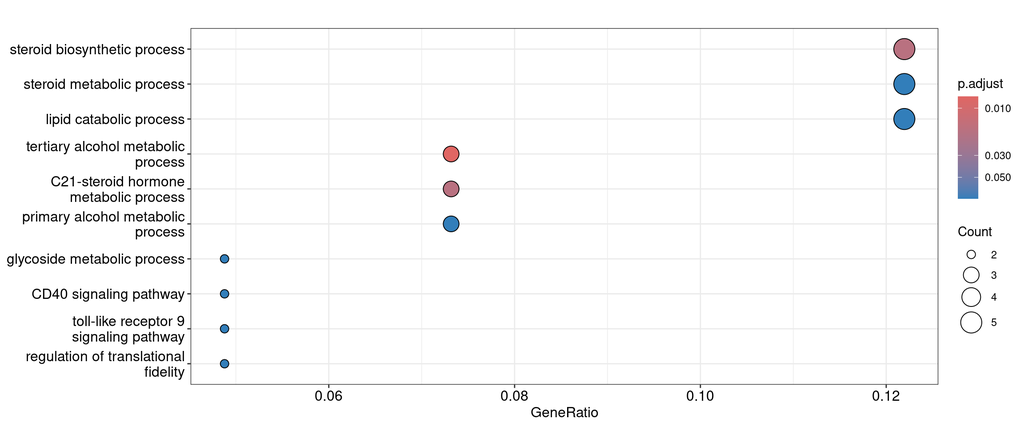

```r
set.seed(312)
Results_geo_uni <- list()

for (i in 1:length(colnames(my.contrast)[1])){
  dea <- Results[[i]]
  gene_list <- dea[dea$FDR <= 0.05,]$ID # this get us all significantly differential expressed genes
kegg <- enrichGO(gene          = gene_list,
                OrgDb         = org.Mm.eg.db,
                keyType       = "SYMBOL",
                ont           = "BP",  # BP: Biological Process, MF: Molecular Function, CC: Cellular Component
                pAdjustMethod = "BH",
                pvalueCutoff  = 1,
                qvalueCutoff  = 1,
                 universe = dea$ID
                    )




  d <- dotplot(kegg, showCategory=10)

}
print(d)
```

```r
ggsave("sup_plots/FigS5P.2cellGOBPDMSOvsIFS.svg")
ggsave("sup_plots/FigS5P.2cellGOBPDMSOvsIFS.pdf")#, width = 6, height = 4)
ggsave("sup_plots/FigS5P.2cellGOBPDMSOvsIFS.png")
```

## 46.17 Fig S5Q GO:BP in excitatory neurons (of a human neural organoid) acutely treated with Dexamethason

```r
se <- readRDS("objects/Binder_DexOrganoids_ExInh_Neurons.SE.rds")
gene_lists <- metadata(se)$feature.lists
```

```r
deas <- as.list(rowData(se)[,grepl(x = names(as.list(rowData(se))),pattern = "FOK4_Ex")])
deas <- lapply(deas,function(x){
  na.omit(x)
})
```

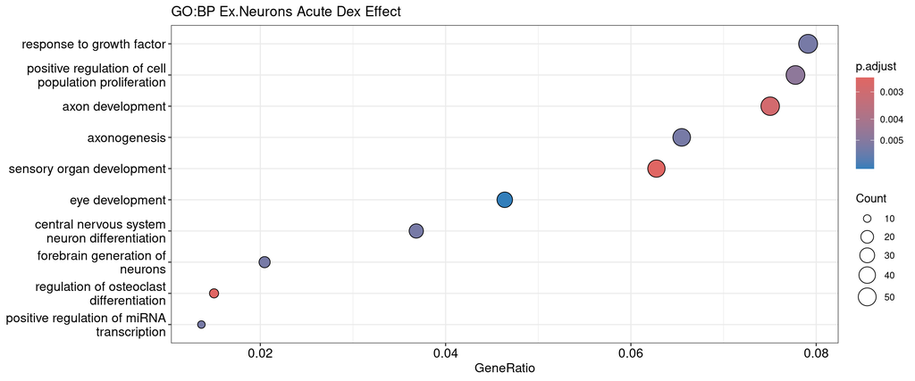

```r
library(clusterProfiler)




  dea <- deas[[1]]
  gene_list <- dea[dea$FDR <= 0.05,]$gene # this get us all significantly differential expressed genes
kegg <- enrichGO(gene          = gene_list,
                OrgDb         = org.Hs.eg.db,
                keyType       = "SYMBOL",
                ont           = "BP",  # BP: Biological Process, MF: Molecular Function, CC: Cellular Component
                pAdjustMethod = "BH",
                pvalueCutoff  = 1,
                qvalueCutoff  = 1,
                universe = dea$gene
                    )




d <- dotplot(kegg, showCategory=10)+ggtitle("GO:BP Ex.Neurons Acute Dex Effect")
print(d)
```

```r
ggsave(paste0("sup_plots/FigS5Q.FOK4.Ex.Neurons.GOBP.Acute90d.png"))

ggsave(paste0("sup_plots/FigS5Q.FOK4.Ex.Neurons.GOBP.Acute90d.pdf"))

ggsave(paste0("sup_plots/FigS5Q.FOK4.Ex.Neurons.GOBP.Acute90d.svg"))
```

# 47 Fig 6B Heatmaps Sex:Stress Interaction HPP offspring

load se object with results

```r
se <- readRDS("objects/se_HPP_offspring_with_DEA_result.rds")
results_DMSO_stressSex_int <-rowData(se)$DEA.DMSO_interaction_between_sex_n_stress
table(results_DMSO_stressSex_int$FDR < 0.05)
```

```
##
## FALSE  TRUE
## 14156   693
```

```r
sig_results_DMSO_stressSex_int <- results_DMSO_stressSex_int[results_DMSO_stressSex_int$FDR < 0.05,]


colData(se)
```

```
## DataFrame with 32 rows and 9 columns
##             sampleid     condition   stress   protac      sex     batch
##          <character>   <character> <factor> <factor> <factor> <integer>
## X4_II_33          33     ctrl_DMSO     ctrl     DMSO        m         1
## X4_II_38          38     ctrl_DMSO     ctrl     DMSO        m         1
## X4_II_47          47     ctrl_DMSO     ctrl     DMSO        m         1
## X4_II_52          52     ctrl_DMSO     ctrl     DMSO        m         1
## X4_II_12          12     ctrl_DMSO     ctrl     DMSO        f         1
## ...              ...           ...      ...      ...      ...       ...
## X4_II_64          64 stress_PROTAC   stress   PROTAC        m         1
## X4_II_22          22 stress_PROTAC   stress   PROTAC        f         1
## X4_II_27          27 stress_PROTAC   stress   PROTAC        f         1
## X4_II_8            8 stress_PROTAC   stress   PROTAC        f         1
## X4_II_9            9 stress_PROTAC   stress   PROTAC        f         1
##                    group        SV1         SV2
##              <character>  <numeric>   <numeric>
## X4_II_33     ctrl_DMSO_m -0.1614934   -0.153235
## X4_II_38     ctrl_DMSO_m -0.3597868   -0.184180
## X4_II_47     ctrl_DMSO_m  0.0250974    0.352011
## X4_II_52     ctrl_DMSO_m -0.0478053    0.185053
## X4_II_12     ctrl_DMSO_f  0.0343915    0.275703
## ...                  ...        ...         ...
## X4_II_64 stress_PROTAC_m   0.230630  0.00184214
## X4_II_22 stress_PROTAC_f  -0.258073  0.24685219
## X4_II_27 stress_PROTAC_f  -0.241367  0.07191661
## X4_II_8  stress_PROTAC_f  -0.275418 -0.17264980
## X4_II_9  stress_PROTAC_f   0.216241 -0.08283331
```

```r
dea <- getDEA(se)
for (i in 1:length(dea)){
  dea[[i]]$DEA <- names(dea)[i]
  dea[[i]]$Gene <- rownames(dea[[i]])
}
dea.combined <- dplyr::bind_rows(dea,.id = "DEA")
dea.combined <- dea.combined[,c(1:7)]

dea.Nrn1 <- dea.combined[grep(pattern = "Nrn1",x = dea.combined$Gene),]

openxlsx::write.xlsx(dea.Nrn1,file = "dea.Nrn1.xlsx")


dea.Fkbp5 <- dea.combined[grep(pattern = "Fkbp5",x = dea.combined$Gene),]

openxlsx::write.xlsx(dea.Fkbp5,file = "dea.Fkbp5.xlsx")
```

```r
metadata(se)$anno_colors <- list(stress=c(CTRL="steelblue", IFS ="firebrick3"), sex =c(m = "forestgreen", f = "purple4"), condition = c("ctrl_DMSO" = "seashell2","stress_DMSO" =  "#ffa500ff" , "ctrl_PROTAC" = "seashell4" , "stress_PROTAC" = "tomato3"))
```

```r
color_palette <- colorRampPalette(c("blue", "black", "orange"))(101)
rownames(se) <- gsub(x = rownames(se),pattern = "^ENS(.*)\\.",replacement = "")



sh <- sechm(se,features = rownames(sig_results_DMSO_stressSex_int),assayName = "corrected",hmcols = color_palette,do.scale =T,gaps_at = c("protac"),column_order = colnames(se)[order(colData(se)$sex)],show_rownames = F,name = paste0("Counter.Genes","\nz-score"),top_annotation = c("sex","condition"),use_raster = T,column_title_gp = gpar(fontsize = 20),,column_title = "Significant genes with Stress and Sex interaction")
print(sh) #
```

[output not shown]

```r
pdf("plots/Fig6B_SexStressInt.pdf", width=14.5, height=10) #, width=14.5, height=10)

print(sh)
dev.off()
```

```r
png("plots/Fig6B_SexStressInt.png", height=638,width = 872,)

print(sh)
dev.off()
```

```r
svg("plots/Fig6B_SexStressInt.svg") #, width=14.5, height=10)

print(sh)
dev.off()
```

# 48 Fig 6C Nrn1 in offspring HPP

```r
df <- as.data.frame(cbind(colData(se),t(assays(se)$logcpm)))
colnames(df) <- gsub(pattern = "^ENSMUS(.*)\\.",replacement = "",x = colnames(df))
df <- df[,!duplicated(colnames(df))]
df$condition <- as.character(df$condition)
df$condition <- factor(df$condition, levels = c("ctrl_DMSO","stress_DMSO","ctrl_PROTAC","stress_PROTAC"))
df$sex <- factor(df$sex, levels = c("f","m"))
```

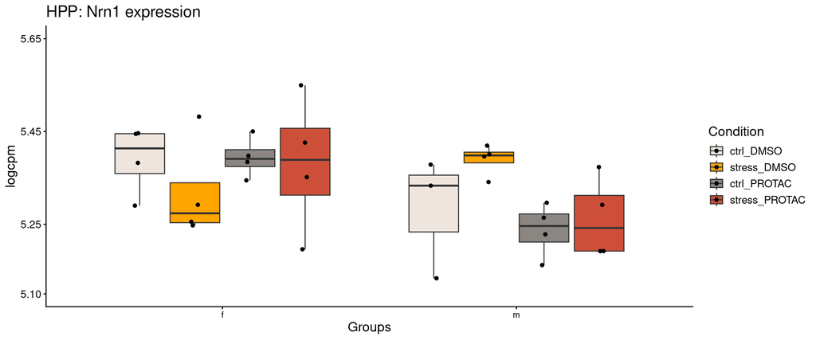

```r
gene <- "Nrn1"
  # Calculate range and breaks
  y_min <- (min(df[[gene]]))
  y_max <- (max(df[[gene]]))
  y_breaks <- seq(y_min, y_max+0.1, length.out = 4)

  # Round to nearest 0.5
  round_to_half <- function(x) round(x * 2,digits = 1) / 2
  y_breaks <- round_to_half(y_breaks)

  # Adjust limits to match rounded breaks
  y_lim <- range(y_breaks)



  e <- ggplot(df, aes(x = sex, y = df[[gene]], fill = condition))


   e2 <- e + geom_boxplot(width = 0.75,outlier.shape = NA ) +
     geom_jitter(
     position=position_jitterdodge(jitter.width = 0.1, dodge.width = 0.75)
      )+

     ylab("logcpm")+
     xlab("Groups")+
     ggtitle(paste0("HPP: ",gene," expression"))+



  scale_y_continuous(breaks = y_breaks, limits = y_lim) +


     scale_fill_manual(values=c( "seashell2","#ffa500ff","seashell4","tomato3"))+
     labs(fill= "Condition")+

   theme(
    axis.text.x = element_text(size = 9),
    text = element_text(size = 14),
  )


   print(e2)
```

```r
ggsave("plots/Fig6C_Nrn1_offspring.svg")
ggsave("plots/Fig6C_Nrn1_offspring.pdf")#, width = 6, height = 4)
ggsave("plots/Fig6C_Nrn1_offspring.png")
```

# 49 Fig 6D Fkbp5

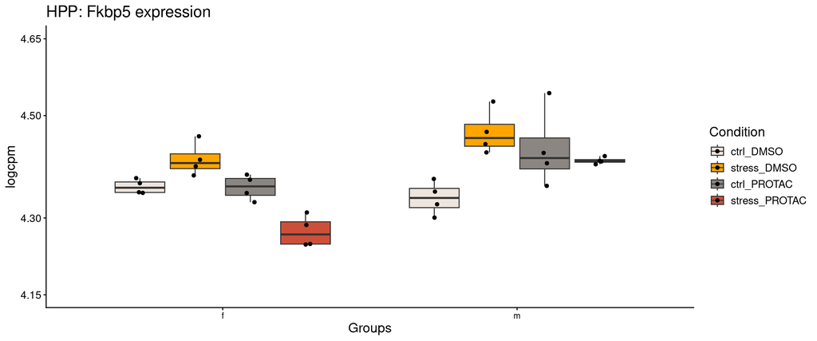

```r
gene <- "Fkbp5"
  # Calculate range and breaks
  y_min <- (min(df[[gene]]))
  y_max <- (max(df[[gene]]))
  y_breaks <- seq(y_min-0.1, y_max+0.1, length.out = 4)

  # Round to nearest 0.5
  round_to_half <- function(x) round(x * 2,digits = 1) / 2
  y_breaks <- round_to_half(y_breaks)

  # Adjust limits to match rounded breaks
  y_lim <- range(y_breaks)



  e <- ggplot(df, aes(x = sex, y = df[[gene]], fill = condition))


   e2 <- e + geom_boxplot(width = 0.75,outlier.shape = NA ) +
     geom_jitter(
     position=position_jitterdodge(jitter.width = 0.1, dodge.width = 0.75)
      )+

     ylab("logcpm")+
     xlab("Groups")+
     ggtitle(paste0("HPP: ",gene," expression"))+



  scale_y_continuous(breaks = y_breaks, limits = y_lim) +


     scale_fill_manual(values=c( "seashell2","#ffa500ff","seashell4","tomato3"))+
     labs(fill= "Condition")+

   theme(
    axis.text.x = element_text(size = 9),
    text = element_text(size = 14),
  )


   print(e2)
```

```r
ggsave("plots/Fig6D_Fkbp5_offspring.svg")
ggsave("plots/Fig6D_Fkbp5_offspring.pdf")#, width = 6, height = 4)
ggsave("plots/Fig6D_Fkbp5_offspring.png")
```

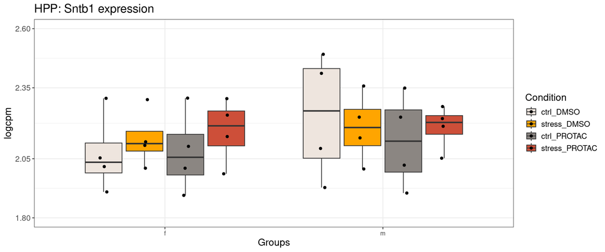

```r
gene <- "Sntb1"
  # Calculate range and breaks
  y_min <- (min(df[[gene]]))
  y_max <- (max(df[[gene]]))
  y_breaks <- seq(y_min-0.1, y_max+0.1, length.out = 4)

  # Round to nearest 0.5
  round_to_half <- function(x) round(x * 2,digits = 1) / 2
  y_breaks <- round_to_half(y_breaks)

  # Adjust limits to match rounded breaks
  y_lim <- range(y_breaks)



  e <- ggplot(df, aes(x = sex, y = df[[gene]], fill = condition))


   e2 <- e + geom_boxplot(width = 0.75,outlier.shape = NA ) +
     geom_jitter(
     position=position_jitterdodge(jitter.width = 0.1, dodge.width = 0.75)
      )+

     ylab("logcpm")+
     xlab("Groups")+
     ggtitle(paste0("HPP: ",gene," expression"))+



  scale_y_continuous(breaks = y_breaks, limits = y_lim) +


     scale_fill_manual(values=c( "seashell2","#ffa500ff","seashell4","tomato3"))+
     labs(fill= "Condition")+
  theme_bw()+
   theme(
    axis.text.x = element_text(size = 9),
    text = element_text(size = 14),
  )


   print(e2)
```

# 50 Fig 6E CortResponse Offspring

load data

```r
df <- read.csv("objects/CortOffspring.csv")
```

```r
df$plate <- as.factor(df$plate)
df$sex <- as.factor(df$sex)
df$stress <- as.factor(df$stress)
df$animal_id <- as.factor(df$animal_id)
df$time_min <- as.factor(df$time_min) # potentially need to be used as factor since it is not complitly linear
```

```r
fit <- lmer(data = df,formula = corticosterone ~ stress*treatment+time_min+sex  +(1|animal_id)+(1|plate))
summary(fit)
```

```
## Linear mixed model fit by REML ['lmerMod']
## Formula:
## corticosterone ~ stress * treatment + time_min + sex + (1 | animal_id) +
##     (1 | plate)
##    Data: df
##
## REML criterion at convergence: 2107.4
##
## Scaled residuals:
##     Min      1Q  Median      3Q     Max
## -3.0320 -0.6064 -0.0650  0.5608  3.4030
##
## Random effects:
##  Groups    Name        Variance Std.Dev.
##  animal_id (Intercept) 269.1    16.41
##  plate     (Intercept) 123.3    11.11
##  Residual              451.3    21.24
## Number of obs: 232, groups:  animal_id, 58; plate, 6
##
## Fixed effects:
##                                Estimate Std. Error t value
## (Intercept)                      43.584     10.599   4.112
## stressstressed                   13.733      7.153   1.920
## treatmentPROTAC                   5.751      7.743   0.743
## time_min15                       59.113     10.750   5.499
## time_min30                      111.302     10.412  10.690
## time_min180                     113.211     10.756  10.525
## sexMales                         -9.420      7.730  -1.219
## stressstressed:treatmentPROTAC  -24.520     10.380  -2.362
##
## Correlation of Fixed Effects:
##             (Intr) strsss tPROTA tm_m15 tm_m30 tm_180 sexMls
## strssstrssd -0.361
## trtmnPROTAC -0.307  0.493
## time_min15  -0.609  0.000  0.010
## time_min30  -0.641  0.000  0.000  0.900
## time_min180 -0.621  0.000 -0.009  0.803  0.893
## sexMales    -0.394  0.003 -0.070 -0.003  0.028  0.031
## strs:PROTAC  0.229 -0.689 -0.746 -0.009 -0.001  0.009  0.053
```

```r
anova(fit, type = 3)
```

|  | npar | Sum Sq | Mean Sq | F value |
| --- | --- | --- | --- | --- |
| stress | 1 | 25.36308 | 25.36308 | 0.05620316 |
| treatment | 1 | 1031.92035 | 1031.92035 | 2.28667728 |
| time_min | 3 | 95592.31351 | 31864.10450 | 70.60905794 |
| sex | 1 | 541.64341 | 541.64341 | 1.20025123 |
| stress:treatment | 1 | 2518.03490 | 2518.03490 | 5.57982329 |

```r
df$Group <- interaction(df$stress,df$treatment)
df$Group <- as.factor(gsub(x = df$Group,pattern = "-",replacement = "."))
# table(df$Group)
```

```r
design <- model.matrix(~0 + Group +time_min, data = df)
```

```r
my.contrasts <- makeContrasts(

Stress_DMSO_all =

    Groupstressed.DMSO   -Groupnon.stressed.DMSO
,


Stress_PROTAC_all =

    Groupstressed.PROTAC  - Groupnon.stressed.PROTAC
,




Treatment_nonstressed_all =

    Groupnon.stressed.PROTAC  - Groupnon.stressed.DMSO
,


Treatment_stressed_all =

    Groupstressed.PROTAC  - Groupstressed.DMSO
,



levels = design
)
```

```r
df$Group <- gsub(x = df$Group,pattern = "-",replacement = ".")
df$Group <- as.factor(df$Group)
contrast_names <- rownames(t(my.contrast))


results <- lapply(contrast_names, function(x) data.frame())
names(results) <- contrast_names
results_cov <- list()

    fit <- lmer(data = df,formula = corticosterone ~ 0+Group  +time_min+(1|animal_id)+(1|plate))

    glht_result <- glht(fit,linfct = t(my.contrasts))
    summary_glht <- summary(glht_result,test = adjusted("holm"))
```

```r
df$Group3 <- interaction(df$stress,df$treatment) # for plotting
```

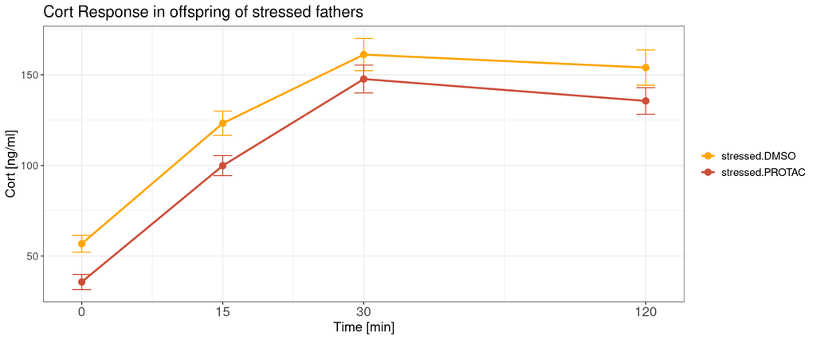

```r
df2 <- df[df$stress == "stressed",]

df2$x_pos <- as.numeric(as.character(df2$time))

df2$x_pos[df2$time == "180"] <- 60


library(ggplot2)

gg <- ggplot(df2, aes(x = x_pos,
               y = corticosterone,
               color = Group3,
               group = Group3)) +

  # mean line
  stat_summary(fun = mean,
               geom = "line",
               size = 1) +

  # points at each timepoint (mean)
  stat_summary(fun = mean,
               geom = "point",
               size = 3) +

  # error bars: mean ± SEM
  stat_summary(
    fun.data = mean_se,   # mean ± standard error
    geom = "errorbar",
    width = 2,
    # linewidth = 0.8
  ) +
    scale_color_manual(values=c("#ffa500ff","tomato3"))+ #  scale_color_manual(values=c( "seashell2","#ffa500ff","seashell4","tomato3"))+

 scale_x_continuous(
    breaks = c(0, 15, 30, 60),
    labels = c("0", "15", "30", "120")
  ) +

 labs(color= NULL)+
  theme_bw() +
   theme(
  axis.text.x = element_text(size = 14),
  text = element_text(size = 14),
)+

  labs(
    x = "Time [min]",
    y = "Cort [ng/ml]",
    title = "Cort Response in offspring of stressed fathers"
   )

print(gg)
```

```r
ggsave("plots/Fig6ECortResponse.svg")
ggsave("plots/Fig6ECortResponse.pdf")#, width = 6, height = 4)
ggsave("plots/Fig6ECortResponse.png")
```

# 51 Fig 6F SPT

```r
suppressPackageStartupMessages({
  library(dplyr)
  library(glmmTMB)
  library(tidyr)
  library(multcomp)
  library(ggplot2)
})
theme_set(theme_classic())
# setSechmOption("hmcols", value=colorspace::diverging_hcl(101,"Blue-Red 3"))
set.seed(123)
```

load spt file

```r
df <- read.csv("objects/SPT_meta.csv",header = T,sep = ",")
df$Group <- as.factor(gsub(pattern = " ",replacement = ".",x = df$Group))
df$CageBatch <- interaction(df$Cage,df$Batch)
df$Sex <- as.factor(df$Sex)
df$HomeCageID <- as.factor(df$HomeCageID)
df$Batch <- as.factor(df$Batch)
df$TimePoint <- as.factor(df$TimePoint)

colnames(df)[8] <- "Sac.Consum.Per"

library(tidyr)

df <- df %>%
  separate(Group, into = c("Condition", "Treatment"), sep = "\\.", remove = FALSE,extra = "merge")


df$Group2 <- interaction(df$Condition,df$Treatment,df$Sex)
df$Group2 <- gsub(pattern = "-",replacement = ".",x = df$Group2)
df$Group2 <- gsub(pattern = "females",replacement = "f",x = df$Group2)
df$Group2 <- gsub(pattern = "males",replacement = "m",x = df$Group2)
```

```r
dt_tp13<-  df[df$TimePoint %in% c("1", "3"),]
dt_tp13$TimePoint <- as.factor(as.integer(dt_tp13$TimePoint))
```

```r
dt_tp13.1 <- dt_tp13[dt_tp13$Size != "1",]
```

```r
             #, Extract condition labels as factor
design <- model.matrix( ~ 0+ Group2 + Size + Batch ,data = dt_tp13.1)  #+ (1|CageBatch)  +TimePoint    #, Create design matrix without intercept (each group is a separate column)

colnames(design) <- gsub(x = colnames(design), pattern = "Group2",replacement = "" )          #, Name columns using condition labels [-length(colnames(design))]
                 #, Set row names to match sample IDs
                           #, Display design matrix for inspection


my.contrast <- limma::makeContrasts(
                                 m_stressVSnon_stressed_DMSO          = stressed.DMSO.m - non.stressed.DMSO.m,
                                 m_stressVSnon_stressed_PROTAC          = stressed.PROTAC.m - non.stressed.PROTAC.m,
                                 m_stressVSnon_stressed_total          = (stressed.DMSO.m - non.stressed.DMSO.m + stressed.PROTAC.m - non.stressed.PROTAC.m)/2,
                                 m_PROTACvsDMSO_stressed = stressed.PROTAC.m - stressed.DMSO.m,
                                 m_PROTACvsDMSO_non_stressed = non.stressed.PROTAC.m - non.stressed.DMSO.m,
                                 m_PROTACvsDMSO_total = (stressed.PROTAC.m - stressed.DMSO.m + non.stressed.PROTAC.m - non.stressed.DMSO.m)/2,

                                 #female
                                 f_stressVSnon_stressed_DMSO          = stressed.DMSO.f - non.stressed.DMSO.f,
                                 f_stressVSnon_stressed_PROTAC          = stressed.PROTAC.f - non.stressed.PROTAC.f,
                                 f_stressVSnon_stressed_total          = (stressed.DMSO.f - non.stressed.DMSO.f + stressed.PROTAC.f - non.stressed.PROTAC.f)/2,
                                 f_PROTACvsDMSO_stressed = stressed.PROTAC.f - stressed.DMSO.f,
                                 f_PROTACvsDMSO_non_stressed = non.stressed.PROTAC.f - non.stressed.DMSO.f,
                                 f_PROTACvsDMSO_total = (stressed.PROTAC.f - stressed.DMSO.f + non.stressed.PROTAC.f - non.stressed.DMSO.f)/2,

                                 # sex effect - only total

                                mVSf_total = (
  (stressed.DMSO.m + non.stressed.DMSO.m + stressed.PROTAC.m + non.stressed.PROTAC.m) -
  (stressed.DMSO.f + non.stressed.DMSO.f + stressed.PROTAC.f + non.stressed.PROTAC.f)
) / 4
,

                                 mf_stressVSnon_stressed_DMSO          = (stressed.DMSO.m - non.stressed.DMSO.m +stressed.DMSO.f - non.stressed.DMSO.f)/2,
                                 mf_stressVSnon_stressed_PROTAC          = (stressed.PROTAC.m - non.stressed.PROTAC.m + stressed.PROTAC.f - non.stressed.PROTAC.f)/2,
                                 mf_stressVSnon_stressed_total          = (stressed.DMSO.m - non.stressed.DMSO.m + stressed.PROTAC.m - non.stressed.PROTAC.m + stressed.DMSO.f - non.stressed.DMSO.f + stressed.PROTAC.f - non.stressed.PROTAC.f)/4,
                                 mf_PROTACvsDMSO_stressed = (stressed.PROTAC.m - stressed.DMSO.m+stressed.PROTAC.f - stressed.DMSO.f)/2 ,
                                 mf_PROTACvsDMSO_non_stressed = (non.stressed.PROTAC.m - non.stressed.DMSO.m + non.stressed.PROTAC.f - non.stressed.DMSO.f)/2,
                                 mf_PROTACvsDMSO_total = (stressed.PROTAC.m - stressed.DMSO.m + non.stressed.PROTAC.m - non.stressed.DMSO.m + stressed.PROTAC.f - stressed.DMSO.f + non.stressed.PROTAC.f - non.stressed.DMSO.f)/4,


                                 # Interaction
                                 ## 3way
                                 Int_Stress_Protac_Sex = ((stressed.PROTAC.m - stressed.DMSO.m) - (non.stressed.PROTAC.m - non.stressed.DMSO.m)) -((stressed.PROTAC.f - stressed.DMSO.f) - (non.stressed.PROTAC.f - non.stressed.DMSO.f)),

                                 ##2way
                                 m_Int_Stress_Protac = (stressed.PROTAC.m - stressed.DMSO.m) - (non.stressed.PROTAC.m - non.stressed.DMSO.m),
                                 f_Int_Stress_Protac = (stressed.PROTAC.f - stressed.DMSO.f) - (non.stressed.PROTAC.f - non.stressed.DMSO.f),
                                 mf_Int_Stress_Protac = (((stressed.PROTAC.m - stressed.DMSO.m) - (non.stressed.PROTAC.m - non.stressed.DMSO.m)) + ((stressed.PROTAC.f - stressed.DMSO.f) - (non.stressed.PROTAC.f - non.stressed.DMSO.f)))/2,
                                 PROTAC_Int_Stress_Sex =(stressed.PROTAC.m - stressed.PROTAC.f) - (non.stressed.PROTAC.m - non.stressed.PROTAC.f),
                                 DMSO_Int_Stress_Sex =(stressed.PROTAC.m - stressed.DMSO.m) - (non.stressed.PROTAC.m - non.stressed.DMSO.m),
                                 Total_Int_Stress_Sex =(((stressed.PROTAC.m - stressed.PROTAC.f) - (non.stressed.PROTAC.m - non.stressed.PROTAC.f))+((stressed.PROTAC.m - stressed.DMSO.m) - (non.stressed.PROTAC.m - non.stressed.DMSO.m)))/2,
                                 Stress_Int_Protac_Sex =(stressed.PROTAC.m - stressed.PROTAC.f) - (stressed.DMSO.m - stressed.DMSO.f),
                                 NonStress_Int_Protac_Sex =(non.stressed.PROTAC.m - non.stressed.PROTAC.f) - (non.stressed.DMSO.m - non.stressed.DMSO.f),
                                 Total_Int_Protac_Sex =(((stressed.PROTAC.m - stressed.PROTAC.f) - (stressed.DMSO.m - stressed.DMSO.f))+((non.stressed.PROTAC.m - non.stressed.PROTAC.f) - (non.stressed.DMSO.m - non.stressed.DMSO.f)))/2,

                                 levels = design)
 # CRS_Sex_int = ((Group_Conditionf.CRS - Group_Conditionf.Ctrl) - (Group_Conditionm.CRS  - Group_Conditionm.Ctrl)), # interaction term
```

```r
contrast_names <- rownames(t(my.contrast))


results <- lapply(contrast_names, function(x) data.frame())
names(results) <- contrast_names
results_cov <- list()

    nbFit <- glmmTMB(Sac.Consum.Per/100 ~ 0+  Group2 + Size + Batch +(1|TimePoint) +(1|CageBatch),family = beta_family(),data = dt_tp13.1)
# summary(nbFit)
# car::Anova(nbFit,type = "III")
    glht_result <- glht(nbFit,linfct = t(my.contrast))
    summary_glht <- summary(glht_result,test = adjusted("none"))
```

```r
    nbFit <- glmmTMB(Sac.Consum.Per/100 ~   Condition*Treatment*Sex+ Size + Batch + (1|TimePoint) +(1|CageBatch),family = beta_family(),data = dt_tp13.1)
    # nbFit2 <- glmmTMB(Sac.Consum.Per/100 ~   Condition*Treatment+Sex+ Size + Batch +TimePoint +(1|CageBatch),data = dt_tp13.1)

# car::Anova(nbFit,type = 3)
```

```r
library(dplyr)
dt_tp13.1
```

|  | X | Cage | Sex | Size | Group | Condition | Treatment | HomeCageID | TimePoint | Sac.Consum.Per | Batch | CageBatch | Group2 |
| --- | --- | --- | --- | --- | --- | --- | --- | --- | --- | --- | --- | --- | --- |
| 1 | 1 | C1 | females | 3 | stressed.PROTAC | stressed | PROTAC | 580949 | 1 | 82.66069 | 1 | C1.1 | stressed.PROTAC.f |
| 3 | 3 | C1 | females | 3 | stressed.PROTAC | stressed | PROTAC | 580949 | 3 | 92.91228 | 1 | C1.1 | stressed.PROTAC.f |
| 5 | 5 | C2 | females | 3 | non-stressed.DMSO | non-stressed | DMSO | 579768 | 1 | 83.63211 | 1 | C2.1 | non.stressed.DMSO.f |
| 7 | 7 | C2 | females | 3 | non-stressed.DMSO | non-stressed | DMSO | 579768 | 3 | 86.27157 | 1 | C2.1 | non.stressed.DMSO.f |
| 9 | 9 | C3 | females | 3 | non-stressed.DMSO | non-stressed | DMSO | 580444 | 1 | 87.41204 | 1 | C3.1 | non.stressed.DMSO.f |
| 11 | 11 | C3 | females | 3 | non-stressed.DMSO | non-stressed | DMSO | 580444 | 3 | 90.60181 | 1 | C3.1 | non.stressed.DMSO.f |
| 13 | 13 | C4 | females | 2 | stressed.DMSO | stressed | DMSO | 580945 | 1 | 72.53219 | 1 | C4.1 | stressed.DMSO.f |
| 15 | 15 | C4 | females | 2 | stressed.DMSO | stressed | DMSO | 580945 | 3 | 78.62745 | 1 | C4.1 | stressed.DMSO.f |
| 17 | 17 | C5 | females | 2 | stressed.DMSO | stressed | DMSO | 580945 | 1 | 71.44351 | 1 | C5.1 | stressed.DMSO.f |
| 19 | 19 | C5 | females | 2 | stressed.DMSO | stressed | DMSO | 580945 | 3 | 81.73168 | 1 | C5.1 | stressed.DMSO.f |

[output cut: 79 more lines]

```r
by_cagebatch <- dt_tp13.1 %>%
  group_by(CageBatch) %>%
  summarise(
    mean_SacConsum = mean(Sac.Consum.Per, na.rm = TRUE),
    sd_SacConsum   = sd(Sac.Consum.Per, na.rm = TRUE),
    n              = sum(!is.na(Sac.Consum.Per)),
    se_SacConsum   = sd_SacConsum / sqrt(n),
    # Keep constant columns (if they truly don't vary within a batch)
    Sex            = dplyr::first(Sex),
    Size           = dplyr::first(Size),
    Group          = dplyr::first(Group),
    Condition      = dplyr::first(Condition),
    Treatment      = dplyr::first(Treatment),
    HomeCageID     = dplyr::first(HomeCageID),
    Batch          = dplyr::first(Batch),
    Group2         = dplyr::first(Group2),
    .groups = "drop"
  )


by_cagebatch$Group <- factor(x = as.character(by_cagebatch$Group),levels = c("non-stressed.DMSO","stressed.DMSO","non-stressed.PROTAC","stressed.PROTAC"))
```

```r
# Male symbol
male <- "\u2642"
print(paste("Male:", male))
```

```
## [1] "Male: ♂"
```

```r
# Female symbol
female <- "\u2640"
print(paste("Female:", female))
```

```
## [1] "Female: ♀"
```

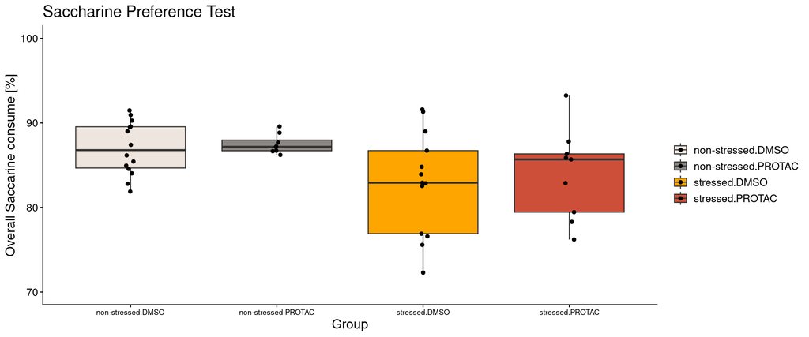

```r
by_cagebatch$Group <- factor(x = by_cagebatch$Group,levels = c("non-stressed.DMSO","non-stressed.PROTAC","stressed.DMSO","stressed.PROTAC"))

y <- 37.5
e <- ggplot(by_cagebatch, aes(x = Group, y = mean_SacConsum, fill = Group))


 e2 <- e + geom_boxplot(width = 0.75,outlier.shape = NA ) +
   geom_jitter(
   position=position_jitterdodge(jitter.width = 0.1, dodge.width = 0.75)
    )+

   ylab("Overall Saccarine consume [%]")+
   # xlab("Sex")+
   ggtitle("Saccharine Preference Test")+
   ylim(c(70,100))+

  scale_fill_manual(values=c( "seashell2","seashell4","#ffa500ff","tomato3"))+

   labs(fill= "")+
   scale_x_discrete(labels=c("f"=paste(female), "m"=paste( male)))+

 theme(
  axis.text.x = element_text(size = 8),
  text = element_text(size = 14),
)


 print(e2)
```

```r
ggsave("plots/Fig6FSPT_activePhase.svg")
ggsave("plots/Fig6FSPT_activePhase.pdf")#, width = 6, height = 4)
ggsave("plots/Fig6FSPT_activePhase.png")
```

# 52 Fig 6G Distance Covered

read in behavior data

```r
df <- readRDS("objects/OFT_readout.rds")
# df$tic1
```

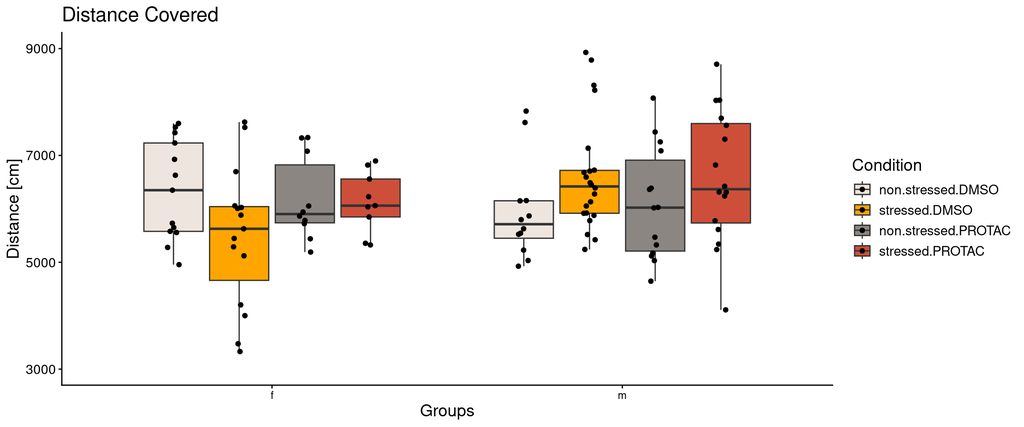

```r
behavior <- "bodycentre.distance.moving"
  # Calculate range and breaks
  y_min <- (min(df[[behavior]]))
  y_max <- (max(df[[behavior]]))
  y_breaks <- seq(3000, 9000, length.out = 4)

  # Round to nearest 0.5
  # round_to_half <- function(x) round(x * 2,digits = 1) / 2
  # y_breaks <- round_to_half(y_breaks)
  #
  # Adjust limits to match rounded breaks
  y_lim <- range(y_breaks)



  e <- ggplot(df, aes(x = sex, y = df[[behavior]], fill = condition))


   e2 <- e + geom_boxplot(width = 0.75,outlier.shape = NA ) +
     geom_jitter(
     position=position_jitterdodge(jitter.width = 0.1, dodge.width = 0.75)
      )+

     ylab("Distance [cm]")+
     xlab("Groups")+
     ggtitle(paste0("Distance Covered"))+



  scale_y_continuous(breaks = y_breaks, limits = y_lim) +


     scale_fill_manual(values=c( "seashell2","#ffa500ff","seashell4","tomato3"))+
     labs(fill= "Condition")+

   theme(
    axis.text.x = element_text(size = 9),
    text = element_text(size = 14),
  )


   print(e2)
```

```r
ggsave("plots/Fig6G_DistanceCovered_offspring.svg")
ggsave("plots/Fig6G_DistanceCovered_offspring.pdf")#, width = 6, height = 4)
ggsave("plots/Fig6G_DistanceCovered_offspring.png")
```

# 53 Fig 6H TIC

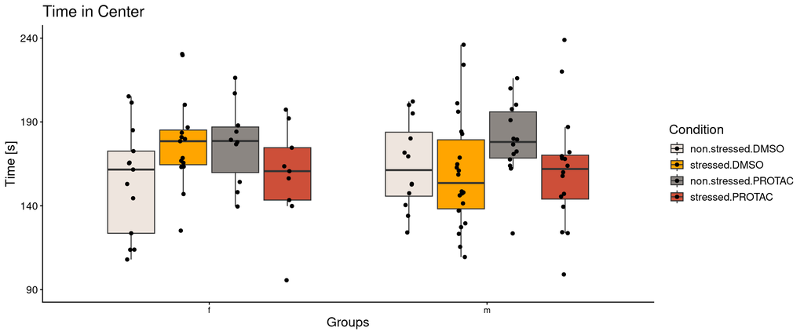

```r
behavior <- "tic1"
  # Calculate range and breaks
  y_min <- (min(df[[behavior]]))
  y_max <- (max(df[[behavior]]))
  y_breaks <- seq(90, 240, length.out = 4)

  # Round to nearest 0.5
  # round_to_half <- function(x) round(x * 2,digits = 1) / 2
  # y_breaks <- round_to_half(y_breaks)
  #
  # Adjust limits to match rounded breaks
  y_lim <- range(y_breaks)



  e <- ggplot(df, aes(x = sex, y = df[[behavior]], fill = condition))


   e2 <- e + geom_boxplot(width = 0.75,outlier.shape = NA ) +
     geom_jitter(
     position=position_jitterdodge(jitter.width = 0.1, dodge.width = 0.75)
      )+

     ylab("Time [s]")+
     xlab("Groups")+
     ggtitle(paste0("Time in Center"))+



  scale_y_continuous(breaks = y_breaks, limits = y_lim) +


     scale_fill_manual(values=c( "seashell2","#ffa500ff","seashell4","tomato3"))+
     labs(fill= "Condition")+

   theme(
    axis.text.x = element_text(size = 9),
    text = element_text(size = 14),
  )


   print(e2)
```

```r
ggsave("plots/Fig6H_TIC_offspring.svg")
ggsave("plots/Fig6H_TIC_offspring.pdf")#, width = 6, height = 4)
ggsave("plots/Fig6H_TIC_offspring.png")
```

# 54 Fig 6I UMAP female offspring transitions

```r
#read in US oject
US <- readRDS("objects/US_OFT_batch12.rds")

#relabel the conditions
US$meta$condition[US$meta$condition == "non stressed PROTAC"] <- "CTRL PROTAC"
US$meta$condition[US$meta$condition == "non-stressed PROTAC"] <- "CTRL PROTAC"
US$meta$condition[US$meta$condition == "non stressed DMSO"] <- "CTRL DMSO"
US$meta$condition[US$meta$condition == "non-stressed DMSO"] <- "CTRL DMSO"
US$meta$condition[US$meta$condition == "stressed PROTAC"] <- "IFS PROTAC"
US$meta$condition[US$meta$condition == "stressed DMSO"] <- "IFS DMSO"

# table(US$meta$condition)


# US$meta <- US$meta %>%
#   tidyr::separate(condition, into = c("Stress", "Treatment"), sep = " ")
# US$meta
```

split US data in objects of interest

```r
# females
US_f <- SplitUSData(US, omit = US$file_names[US$meta$sex =="m"])



# males
US_m <- SplitUSData(US, omit = US$file_names[US$meta$sex =="f"])
```

```r
  x <- Plot2DEmbedding(
    US_f,
    seed = 61,
    transitionmatrices  = "kmeans.50",
    colorby = "condition",
    color = c("seashell3", "#ffa500ff", "seashell4", "tomato3"),
    plot.sem = TRUE,
  ) + ggtitle(paste0("UMAP:Transitions female offspring" ))
```

```
## [1] "including transitionmatrix: kmeans.50"
```

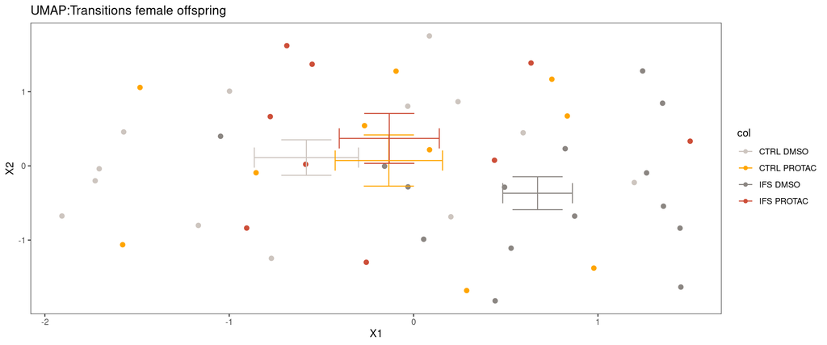

```r
 print(x)
```

```r
 ggsave("plots/Fig6I_UMAP_Trans_Females.png")
  ggsave("plots/Fig6I_UMAP_Trans_Females.svg")
   ggsave("plots/Fig6I_UMAP_Trans_Females.pdf")
```

# 55 Fig 6J Perm_Trans_Females_SvsCinDMSO

```r
plotTransVF <- function(us, analysis = NULL, labels = NULL, title = NULL){
  require(ggplot2)
  require(cowplot)
  if(is.null(analysis)){
    analysis <- names(us$Results)
  }
  if(is.null(labels)){
    for(i in analysis){
      labels <- unique(c(labels, names(us$Results[[i]]$TransitionStats)))
    }
  }

  ps <- list()
  for(i in analysis){
    for(j in labels[labels %in% names(us$Results[[i]]$TransitionStats)]){
      bdat <- data.frame(distance = us$Results[[i]]$TransitionStats[[j]]$bootstraps)
      dis <- us$Results[[i]]$TransitionStats[[j]]$distance
      sigma <- us$Results[[i]]$TransitionStats[[j]]$sigma
      percentile <- us$Results[[i]]$TransitionStats[[j]]$percentile
      p1 <- ggplot(bdat,aes(distance)) +
        geom_histogram(color = "black", fill = "gray70", bins = 30) +
        geom_vline(xintercept = dis, color = "orange") +
        ylab("Frequency")+
        xlab("Manhattan Distance")+
        ggtitle(title)+

annotate("label",
         x = Inf, y = Inf,
         label = paste0("percentile: ", signif(percentile, 4), "\n",
                        "sigma: ", round(sigma, 2), "\n",
                        "p.value: ", signif((1 - pracma::erf(sigma / sqrt(2))) / 2, 3)),
         hjust = 1.05, vjust = 1.1,         # nudges inward from top-right
         size =5,                        # larger text
         label.size = 0.5,                  # thicker border
         fill = "white",                    # background color
         color = "black",                   # text color
         fontface = "plain",                # normal weight
         family = "Helvetica",                  # optional: use serif font
         lineheight = 1.1                   # spacing between lines
)

    ps[[paste(i,j, sep = "-")]] <- cowplot::plot_grid(p1, nrow = 1,rel_widths = c(1))


    }
  }
  cowplot::plot_grid(plotlist = ps, ncol = 1)
}
```

```r
US_list <- readRDS("objects/US_list_OFT_analysed.rds")



US_list <- lapply(US_list,function(us){
  us$meta$Group <- interaction(us$meta$Stress,us$meta$Treatment)
  us
})
```

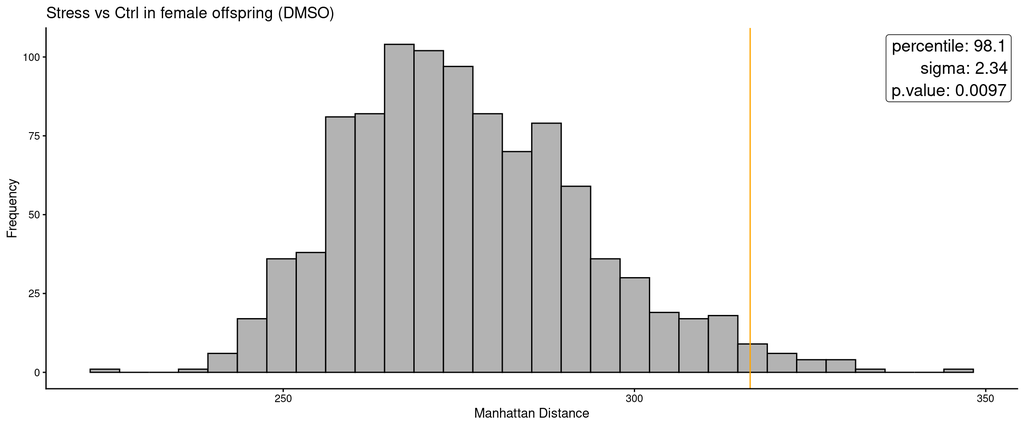

```r
  x <- plotTransVF(US_list$US_f_SvsC_D, labels = "kmeans.50",title = "Stress vs Ctrl in female offspring (DMSO)")
  print(x)
```

```r
ggsave("plots/Fig6J_Perm_Trans_Females_SvsCinDMSO.png")
  ggsave("plots/Fig6J_Perm_Trans_Females_SvsCinDMSO.svg")
   ggsave("plots/Fig6J_Perm_Trans_Females_SvsCinDMSO.pdf")
```

# 56 Fig 6K Perm_Trans_Females_SvsCinKH

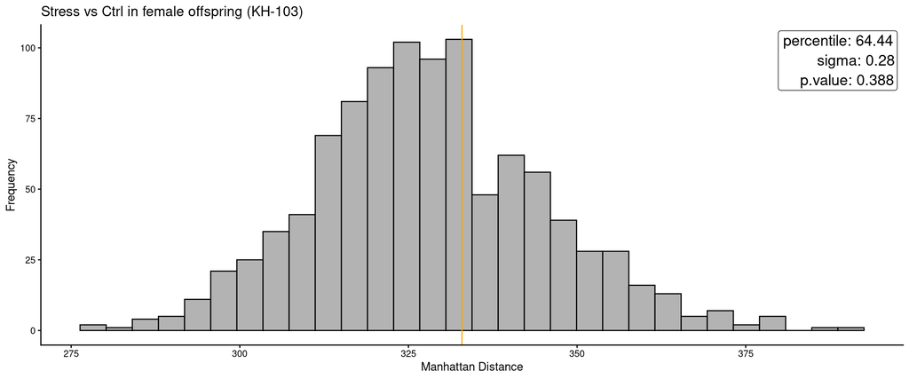

```r
  x <- plotTransVF(US_list$US_f_SvsC_K, labels = "kmeans.50",title = "Stress vs Ctrl in female offspring (KH-103)")
  print(x)
```

```r
ggsave("plots/Fig6K_Perm_Trans_Females_SvsCinKH.png")
  ggsave("plots/Fig6K_Perm_Trans_Females_SvsCinKH.svg")
   ggsave("plots/Fig6K_Perm_Trans_Females_SvsCinKH.pdf")
```

## 56.1 Fig S6A offspring hippocampus transcriptome GSEA

```r
dir_path <- "objects/"
files <- list.files(path = dir_path, pattern = "^fgsea_.*", full.names = TRUE)
```

```r
get_top_table <- function(pattern = NULL, filelist, top_num){
  library(purrr)
  library(dplyr)

    # the pattern should be the the pattern of the pathway names that we want to extract
    # for example "C5:GP:BP"
    # top_num: how many top terms we extract from each contrast
    if (is.null(pattern)){
        top_list <- map_dfr(filelist, function(fpath) {
        df <- readRDS(fpath)
        df <- df[order(df$pval), ]
        df_top <- head(df, top_num)  # now choose top5 otherwise too many terms
        fname <- basename(fpath)
        label <- gsub("^fgsea_", "", fname)
        df_top %>%
            mutate(source_file = fname,
                source = label,
                .before = 1)  # put source in column1
    })
    }
    else {
        top_list <- map_dfr(filelist, function(fpath) {
        df <- readRDS(fpath)
        df <- df[order(df$pval), ]
        df_top <- head(df[grepl(pattern, df$pathway),], top_num)  # extract the terms
        fname <- basename(fpath)
        label <- gsub("^fgsea_", "", fname)
        df_top %>%
            mutate(source_file = fname,
                source = label,
                .before = 1)  # put source at column1
})
    }

    top_path <- unique(top_list$pathway)
    fgsea_combine <- map_dfr(filelist, function(f){
        df <- readRDS(f)
        matched <- df %>% dplyr::filter(pathway %in% top_path)
        matched %>%
            mutate(
                label = gsub("^fgsea_", "", basename(f)),
                .before = 1)
    })

    fgsea_combine$label <- gsub("\\.rds$", "", fgsea_combine$label)

    return(fgsea_combine)
}
```

```r
fgsea_combine_GOBP <- get_top_table(pattern = "C5:GO:BP", filelist = files, top_num = 10)
fgsea_combine_GOBP$label <- factor(fgsea_combine_GOBP$label, levels = c(
        "total_stress_vs_ctrl", "total_PROTAC_vs_DMSO", "DMSO_interaction_between_sex_n_stress", "PROTAC_interaction_between_sex_n_stress"
    ))
```

```r
get_cluster <- function(maxK, fgsea_table){ # the function will decide the cluster number by itself (silhouette)
    # First: create a pathway x label matrix, the values are NES (we do the cluster based on NES)
    mat_df <- fgsea_table %>%
        dplyr::select(label, pathway, NES) %>%
        pivot_wider(names_from = label, values_from = NES)
    mat <- as.matrix(mat_df %>% dplyr::select(-pathway))
    rownames(mat) <- mat_df$pathway

    # Second: compute the distance
    # Pearson correlation distance (1 - correlation): measures similarity in patterns, ignoring magnitude
    # Euclidean distance: measures absolute numeric differneces (magnitude)
    # here we care about the pattern across contrast groups, so we use the pearson correlation
    dist_mat <- as.dist(1 - cor(t(mat)))

    # Third: compute hierarchical clustering
    hc <- hclust(dist_mat, method = "ward.D2")  # ward.D2: join clusters that cause the smallest increase in within-cluster variance. good for forming compact balanced clusters from continuous data

    # Fouth: use silhouette to check how many clusters are the best
    avg_sil <- numeric(maxK)
    for(k in 3:maxK){
        cl <- cutree(hc, k= k)
        sil <- cluster::silhouette(cl, dist_mat)
        avg_sil[k] <- mean(sil[,3])
    }
    best_k_sil <- which.max(avg_sil)

    plot(3:maxK, avg_sil[3:maxK], type="b", xlab="k", ylab="Average silhouette", pch=19)
    cat("Best k by silhouette =", best_k_sil, ", avg silhouette =", avg_sil[best_k_sil], "\n")

    pathway_order <- hc$labels[hc$order]
    clusters <- cutree(hc, k = best_k_sil)
    cluster_df <- tibble(pathway = names(clusters), cluster = as.factor(clusters))

    # Put the cluster result into the original table
    fgsea_clustered <- fgsea_table %>%
        left_join(cluster_df, by = "pathway") %>%
        mutate(pathway = factor(pathway, levels = pathway_order))

    return(fgsea_clustered)
}
```

```r
set.seed(123)
fgsea_combine_GOBP_clustered <- get_cluster(maxK = 5, fgsea_table = fgsea_combine_GOBP)
```

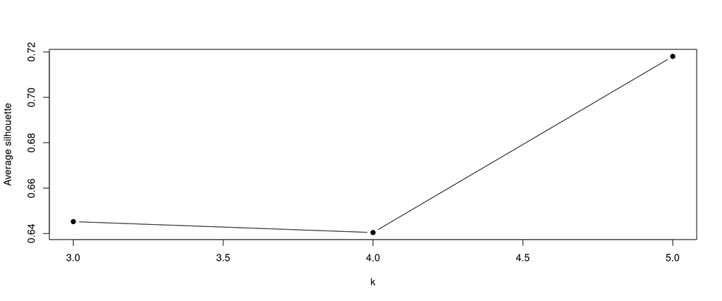

```
## Best k by silhouette = 5 , avg silhouette = 0.7180327
```

```r
cluster_bar_combine_GOBP_clustered <- fgsea_combine_GOBP_clustered %>% distinct(pathway, cluster)
```

```r
fgsea_combine_GOBP_clustered$pathway <- gsub(pattern = "C5:GO:BP:GOBP_",replacement = "",x =fgsea_combine_GOBP_clustered$pathway )
cluster_bar_combine_GOBP_clustered$pathway<- gsub(pattern = "C5:GO:BP:GOBP_",replacement = "",x =cluster_bar_combine_GOBP_clustered$pathway)
```

```r
fgsea_combine_GOBP_clustered$label <- factor(
  fgsea_combine_GOBP_clustered$label,
  levels = c("total_stress_vs_ctrl", "total_PROTAC_vs_DMSO", "DMSO_interaction_between_sex_n_stress", "PROTAC_interaction_between_sex_n_stress"),
  labels= c("Stress vs Ctrl","KH-103 vs DMSO","Ineraction Stress:Sex (DMSO)","Ineraction Stress:Sex (KH-103)")
)
```

[figure not shown]

```r
p_combine_GOBP_clustered_with_shape <- ggplot(fgsea_combine_GOBP_clustered, aes(x = label, y = pathway, color = NES, size = -log10(padj), shape = padj<0.05)) +
    geom_point() +
    theme_minimal() +
    scale_color_gradient2(low = "blue", high = "red", mid="grey") +
    scale_size_continuous(range = c(2, 8)) +
    theme(
        axis.text.x = element_text(angle = 90, vjust = 0.5, hjust = 1, size = 14),
        axis.text.y = element_text(size = 14),
        axis.title.x = element_text(size = 14),
        axis.title.y = element_text(size = 14),
        plot.title = element_text(size = 16, face = "bold")
    ) +
    labs(title = "GSEA of GO:BP in offspring hippocampus transcriptome comparisons")+
    xlab(NULL)+
    # label the clusters
    geom_text(data = fgsea_combine_GOBP_clustered %>% dplyr::filter(!duplicated(pathway)),
        aes(x = -Inf, y = pathway, label = cluster),
        inherit.aes = FALSE, hjust = -0.1, size = 3) +
    coord_cartesian(clip = "off") +
    facet_grid(cluster ~ ., scales = "free_y", space = "free_y") +  # to make a little gap between clusters
    geom_tile(data = cluster_bar_combine_GOBP_clustered,  #REMEMBER TO CHANGE
            aes(x = -0.5, y = pathway, fill = cluster),
            width = 0.3, height = 0.8,
            inherit.aes = FALSE)+
  scale_fill_brewer(palette = "Dark2") +

  theme(
    axis.text.x = element_text(angle = 30, hjust = 1, vjust = 1)
  )

p_combine_GOBP_clustered_with_shape
```

```r
ggsave("sup_plots/FigS6A_GSEA_Offspring_HPP.svg")
ggsave("sup_plots/FigS6A_GSEA_Offspring_HPP.pdf")#, width = 6, height = 4)
ggsave("sup_plots/FigS6A_GSEA_Offspring_HPP.png")
```

## 56.2 Fig S6B Cort offspring all groups

load data

```r
df <- read.csv("objects/CortOffspring.csv")
```

```r
df$plate <- as.factor(df$plate)
df$sex <- as.factor(df$sex)
df$stress <- as.factor(df$stress)
df$animal_id <- as.factor(df$animal_id)
df$time_min <- as.factor(df$time_min) # potentially need to be used as factor since it is not complitly linear
```

```r
fit <- lmer(data = df,formula = corticosterone ~ stress*treatment+time_min+sex  +(1|animal_id)+(1|plate))
summary(fit)
```

```
## Linear mixed model fit by REML ['lmerMod']
## Formula:
## corticosterone ~ stress * treatment + time_min + sex + (1 | animal_id) +
##     (1 | plate)
##    Data: df
##
## REML criterion at convergence: 2107.4
##
## Scaled residuals:
##     Min      1Q  Median      3Q     Max
## -3.0320 -0.6064 -0.0650  0.5608  3.4030
##
## Random effects:
##  Groups    Name        Variance Std.Dev.
##  animal_id (Intercept) 269.1    16.41
##  plate     (Intercept) 123.3    11.11
##  Residual              451.3    21.24
## Number of obs: 232, groups:  animal_id, 58; plate, 6
##
## Fixed effects:
##                                Estimate Std. Error t value
## (Intercept)                      43.584     10.599   4.112
## stressstressed                   13.733      7.153   1.920
## treatmentPROTAC                   5.751      7.743   0.743
## time_min15                       59.113     10.750   5.499
## time_min30                      111.302     10.412  10.690
## time_min180                     113.211     10.756  10.525
## sexMales                         -9.420      7.730  -1.219
## stressstressed:treatmentPROTAC  -24.520     10.380  -2.362
##
## Correlation of Fixed Effects:
##             (Intr) strsss tPROTA tm_m15 tm_m30 tm_180 sexMls
## strssstrssd -0.361
## trtmnPROTAC -0.307  0.493
## time_min15  -0.609  0.000  0.010
## time_min30  -0.641  0.000  0.000  0.900
## time_min180 -0.621  0.000 -0.009  0.803  0.893
## sexMales    -0.394  0.003 -0.070 -0.003  0.028  0.031
## strs:PROTAC  0.229 -0.689 -0.746 -0.009 -0.001  0.009  0.053
```

```r
anova(fit, type = 3)
```

|  | npar | Sum Sq | Mean Sq | F value |
| --- | --- | --- | --- | --- |
| stress | 1 | 25.36308 | 25.36308 | 0.05620316 |
| treatment | 1 | 1031.92035 | 1031.92035 | 2.28667728 |
| time_min | 3 | 95592.31351 | 31864.10450 | 70.60905794 |
| sex | 1 | 541.64341 | 541.64341 | 1.20025123 |
| stress:treatment | 1 | 2518.03490 | 2518.03490 | 5.57982329 |

```r
df$Group <- interaction(df$stress,df$treatment)
df$Group <- as.factor(gsub(x = df$Group,pattern = "-",replacement = "."))
# table(df$Group)
```

```r
design <- model.matrix(~0 + Group +time_min, data = df)
```

```r
my.contrasts <- makeContrasts(

Stress_DMSO_all =

    Groupstressed.DMSO   -Groupnon.stressed.DMSO
,


Stress_PROTAC_all =

    Groupstressed.PROTAC  - Groupnon.stressed.PROTAC
,




Treatment_nonstressed_all =

    Groupnon.stressed.PROTAC  - Groupnon.stressed.DMSO
,


Treatment_stressed_all =

    Groupstressed.PROTAC  - Groupstressed.DMSO
,



levels = design
)
```

```r
library(multcomp)
df$Group <- gsub(x = df$Group,pattern = "-",replacement = ".")
df$Group <- as.factor(df$Group)
contrast_names <- rownames(t(my.contrast))


results <- lapply(contrast_names, function(x) data.frame())
names(results) <- contrast_names
results_cov <- list()

    fit <- lmer(data = df,formula = corticosterone ~ 0+Group  +time_min+(1|animal_id)+(1|plate))

    glht_result <- glht(fit,linfct = t(my.contrasts))
    summary_glht <- summary(glht_result,test = adjusted("holm"))
```

```r
df$Group3 <- interaction(df$stress,df$treatment) # for plotting
```

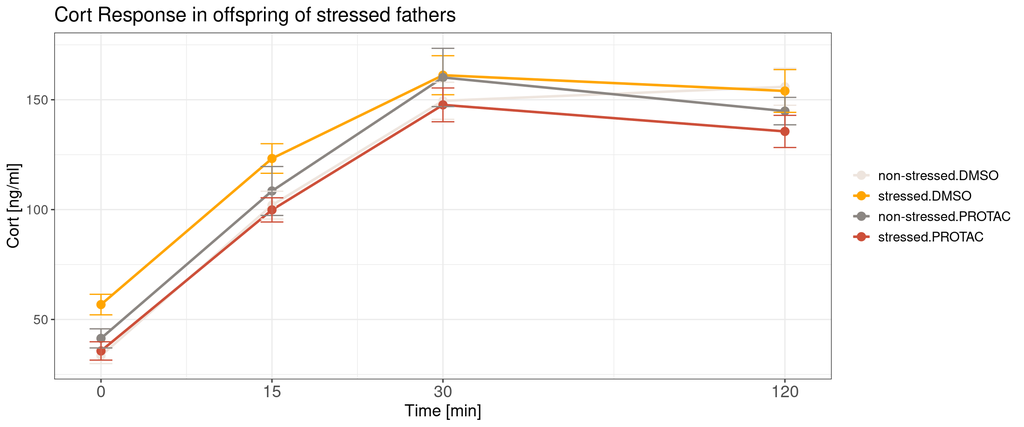

```r
df2 <- df

df2$x_pos <- as.numeric(as.character(df2$time))

df2$x_pos[df2$time == "180"] <- 60


library(ggplot2)

gg <- ggplot(df2, aes(x = x_pos,
               y = corticosterone,
               color = Group3,
               group = Group3)) +

  # mean line
  stat_summary(fun = mean,
               geom = "line",
               size = 1) +

  # points at each timepoint (mean)
  stat_summary(fun = mean,
               geom = "point",
               size = 3) +

  # error bars: mean ± SEM
  stat_summary(
    fun.data = mean_se,   # mean ± standard error
    geom = "errorbar",
    width = 2,
    # linewidth = 0.8
  ) +
    scale_color_manual(values=c("seashell2","#ffa500ff","seashell4","tomato3"))+ #  scale_color_manual(values=c( "seashell2","#ffa500ff","seashell4","tomato3"))+

 scale_x_continuous(
    breaks = c(0, 15, 30, 60),
    labels = c("0", "15", "30", "120")
  ) +

 labs(color= NULL)+
  theme_bw() +
   theme(
  axis.text.x = element_text(size = 14),
  text = element_text(size = 14),
)+

  labs(
    x = "Time [min]",
    y = "Cort [ng/ml]",
    title = "Cort Response in offspring of stressed fathers"
   )

print(gg)
```

```r
ggsave("sup_plots/FigS6BCortResponse.svg")
ggsave("sup_plots/FigS6BCortResponse.pdf")#, width = 6, height = 4)
ggsave("sup_plots/FigS6BCortResponse.png")
```

## 56.3 Fig S6C Spt split by sex

```r
# Male symbol
male <- "\u2642"
print(paste("Male:", male))
```

```
## [1] "Male: ♂"
```

```r
# Female symbol
female <- "\u2640"
print(paste("Female:", female))
```

```
## [1] "Female: ♀"
```

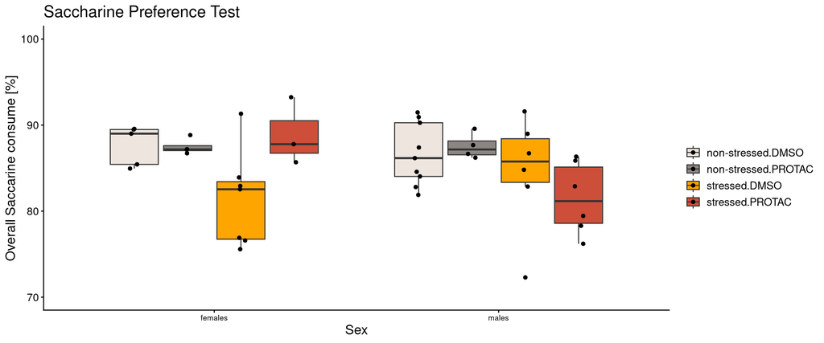

```r
by_cagebatch$Group <- factor(x = by_cagebatch$Group,levels = c("non-stressed.DMSO","non-stressed.PROTAC","stressed.DMSO","stressed.PROTAC"))

y <- 37.5
e <- ggplot(by_cagebatch, aes(x = Sex, y = mean_SacConsum, fill = Group))


 e2 <- e + geom_boxplot(width = 0.75,outlier.shape = NA ) +
   geom_jitter(
   position=position_jitterdodge(jitter.width = 0.1, dodge.width = 0.75)
    )+

   ylab("Overall Saccarine consume [%]")+
   # xlab("Sex")+
   ggtitle("Saccharine Preference Test")+
   ylim(c(70,100))+

  scale_fill_manual(values=c( "seashell2","seashell4","#ffa500ff","tomato3"))+

   labs(fill= "")+
   scale_x_discrete(labels=c("f"=paste(female), "m"=paste( male)))+

 theme(
  axis.text.x = element_text(size = 8),
  text = element_text(size = 14),
)


 print(e2)
```

```r
ggsave("sup_plots/FigS6CSPT_activePhase_sex.svg")
ggsave("sup_plots/FigS6CSPT_activePhase_sex.pdf")#, width = 6, height = 4)
ggsave("sup_plots/FigS6CSPT_activePhase_sex.png")
```

## 56.4 Fig S6D OFT behavior merge

read in behavior data

```r
df <- readRDS("objects/OFT_readout.rds")
```

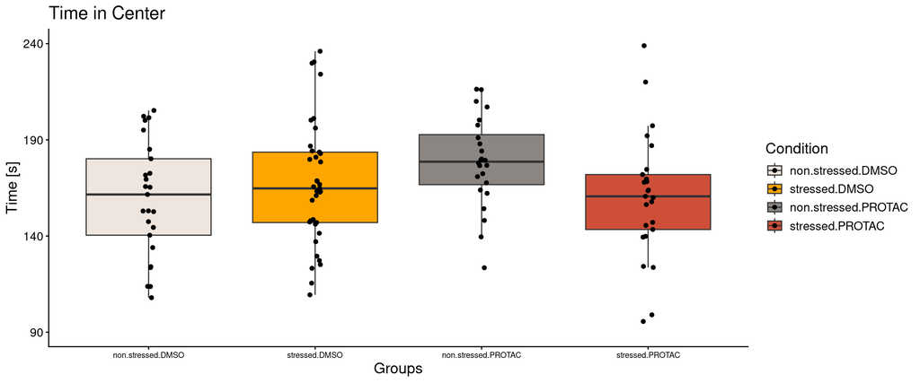

```r
behavior <- "tic1"
  # Calculate range and breaks
  y_min <- (min(df[[behavior]]))
  y_max <- (max(df[[behavior]]))
  y_breaks <- seq(90, 240, length.out = 4)

  # Round to nearest 0.5
  # round_to_half <- function(x) round(x * 2,digits = 1) / 2
  # y_breaks <- round_to_half(y_breaks)
  #
  # Adjust limits to match rounded breaks
  y_lim <- range(y_breaks)



  e <- ggplot(df, aes(x = condition, y = df[[behavior]], fill = condition))


   e2 <- e + geom_boxplot(width = 0.75,outlier.shape = NA ) +
     geom_jitter(
     position=position_jitterdodge(jitter.width = 0.1, dodge.width = 0.75)
      )+

     ylab("Time [s]")+
     xlab("Groups")+
     ggtitle(paste0("Time in Center"))+



  scale_y_continuous(breaks = y_breaks, limits = y_lim) +


     scale_fill_manual(values=c( "seashell2","#ffa500ff","seashell4","tomato3"))+
     labs(fill= "Condition")+

   theme(
    axis.text.x = element_text(size =7.5),
    text = element_text(size = 14),
  )


   print(e2)
```

```r
ggsave("sup_plots/FigS6D_TIC_merge_offspring.svg")
ggsave("sup_plots/FigS6D_TIC_merge_offspring.pdf")#, width = 6, height = 4)
ggsave("sup_plots/FigS6D_TIC_merge_offspring.png")
```

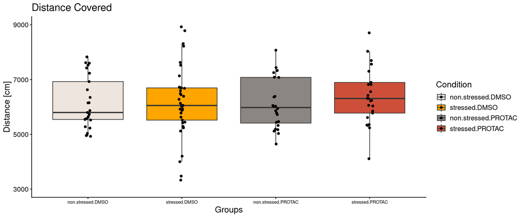

```r
behavior <- "bodycentre.distance.moving"
  # Calculate range and breaks
  y_min <- (min(df[[behavior]]))
  y_max <- (max(df[[behavior]]))
  y_breaks <- seq(3000, 9000, length.out = 4)

  # Round to nearest 0.5
  # round_to_half <- function(x) round(x * 2,digits = 1) / 2
  # y_breaks <- round_to_half(y_breaks)
  #
  # Adjust limits to match rounded breaks
  y_lim <- range(y_breaks)



  e <- ggplot(df, aes(x = condition, y = df[[behavior]], fill = condition))


   e2 <- e + geom_boxplot(width = 0.75,outlier.shape = NA ) +
     geom_jitter(
     position=position_jitterdodge(jitter.width = 0.1, dodge.width = 0.75)
      )+

     ylab("Distance [cm]")+
     xlab("Groups")+
     ggtitle(paste0("Distance Covered"))+



  scale_y_continuous(breaks = y_breaks, limits = y_lim) +


     scale_fill_manual(values=c( "seashell2","#ffa500ff","seashell4","tomato3"))+
     labs(fill= "Condition")+

   theme(
    axis.text.x = element_text(size = 7.5),
    text = element_text(size = 14),
  )


   print(e2)
```

```r
ggsave("sup_plots/FigS6D_DistanceCovered_merge_offspring.svg")
ggsave("sup_plots/FigS6D_DistanceCovered_merge_offspring.pdf")#, width = 6, height = 4)
ggsave("sup_plots/FigS6D_DistanceCovered_merge_offspring.png")
```

## 56.5 Fig S6E OFT extra behavior

supported rear merge read in behavior data

```r
df <- readRDS("objects/OFT_readout.rds")
# df$classifications.SupportedRear.count
```

```r
behavior <- "classifications.SupportedRear.count"
  # Calculate range and breaks
  y_min <- (min(df[[behavior]]));y_min
```

```
## [1] 61
```

```r
  y_max <- (max(df[[behavior]]));y_max
```

```
## [1] 131
```

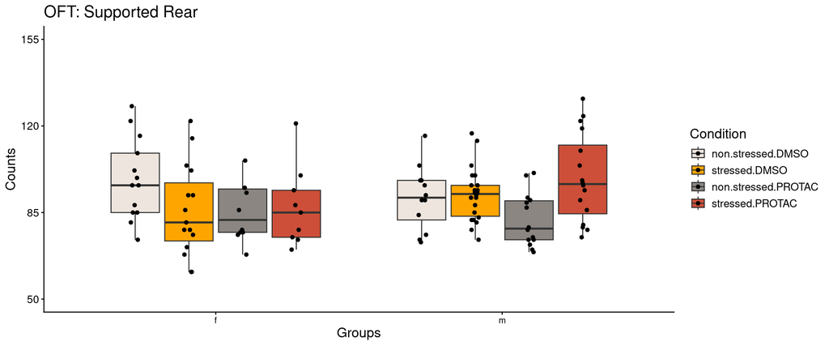

```r
  y_breaks <- seq(50, 155, length.out = 4)

  # Round to nearest 0.5
  # round_to_half <- function(x) round(x * 2,digits = 1) / 2
  # y_breaks <- round_to_half(y_breaks)
  #
  # Adjust limits to match rounded breaks
  y_lim <- range(y_breaks)



  e <- ggplot(df, aes(x = sex, y = round(df[[behavior]]), fill = condition))


   e2 <- e + geom_boxplot(width = 0.75,outlier.shape = NA ) +
     geom_jitter(
     position=position_jitterdodge(jitter.width = 0.1, dodge.width = 0.75)
      )+

     ylab("Counts")+
     xlab("Groups")+
     ggtitle(paste0("OFT: Supported Rear"))+



  scale_y_continuous(breaks = y_breaks, limits = y_lim) +


     scale_fill_manual(values=c( "seashell2","#ffa500ff","seashell4","tomato3"))+
     labs(fill= "Condition")+

   theme(
    axis.text.x = element_text(size = 9),
    text = element_text(size = 14),
  )


   print(e2)
```

```r
ggsave("sup_plots/FigS6E_OFT_SupRear_offspring.svg")
ggsave("sup_plots/FigS6E_OFT_SupRear_offspring.pdf")#, width = 6, height = 4)
ggsave("sup_plots/FigS6E_OFT_SupRear_offspring.png")
```

OFT merge Supported Rear count read in behavior data

```r
df <- readRDS("objects/OFT_readout.rds")
# df$classifications.SupportedRear.count
```

```r
behavior <- "classifications.SupportedRear.count"
  # Calculate range and breaks
  y_min <- (min(df[[behavior]]));y_min
```

```
## [1] 61
```

```r
  y_max <- (max(df[[behavior]]));y_max
```

```
## [1] 131
```

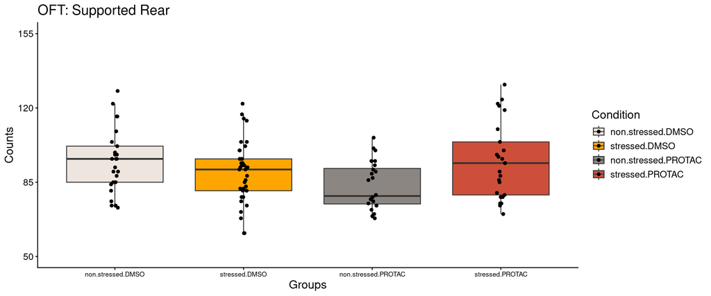

```r
  y_breaks <- seq(50, 155, length.out = 4)

  # Round to nearest 0.5
  # round_to_half <- function(x) round(x * 2,digits = 1) / 2
  # y_breaks <- round_to_half(y_breaks)
  #
  # Adjust limits to match rounded breaks
  y_lim <- range(y_breaks)



  e <- ggplot(df, aes(x = condition, y = round(df[[behavior]]), fill = condition))


   e2 <- e + geom_boxplot(width = 0.75,outlier.shape = NA ) +
     geom_jitter(
     position=position_jitterdodge(jitter.width = 0.1, dodge.width = 0.75)
      )+

     ylab("Counts")+
     xlab("Groups")+
     ggtitle(paste0("OFT: Supported Rear"))+



  scale_y_continuous(breaks = y_breaks, limits = y_lim) +


     scale_fill_manual(values=c( "seashell2","#ffa500ff","seashell4","tomato3"))+
     labs(fill= "Condition")+

   theme(
    axis.text.x = element_text(size = 8),
    text = element_text(size = 14),
  )


   print(e2)
```

```r
ggsave("sup_plots/FigS6E_OFT_SupRear_merge_offspring.svg")
ggsave("sup_plots/FigS6E_OFT_SupRear_merge_offspring.pdf")#, width = 6, height = 4)
ggsave("sup_plots/FigS6E_OFT_SupRear_merge_offspring.png")
```

OFT Grooming count read in behavior data

```r
df <- readRDS("objects/OFT_readout.rds")
# df$classifications.Grooming.count
```

```r
behavior <- "classifications.Grooming.count"
  # Calculate range and breaks
  y_min <- (min(df[[behavior]]));y_min
```

```
## [1] 3
```

```r
  y_max <- (max(df[[behavior]]));y_max
```

```
## [1] 46
```

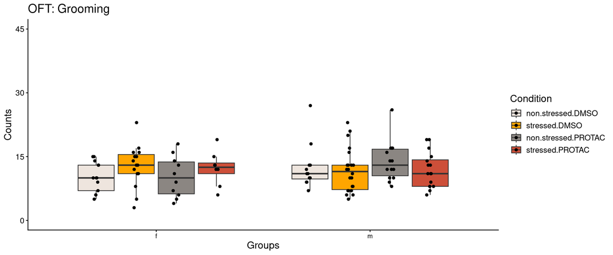

```r
  y_breaks <- seq(0, 45, length.out = 4)

  # Round to nearest 0.5
  # round_to_half <- function(x) round(x * 2,digits = 1) / 2
  # y_breaks <- round_to_half(y_breaks)
  #
  # Adjust limits to match rounded breaks
  y_lim <- range(y_breaks)



  e <- ggplot(df, aes(x = sex, y = round(df[[behavior]]), fill = condition))


   e2 <- e + geom_boxplot(width = 0.75,outlier.shape = NA ) +
     geom_jitter(
     position=position_jitterdodge(jitter.width = 0.1, dodge.width = 0.75)
      )+

     ylab("Counts")+
     xlab("Groups")+
     ggtitle(paste0("OFT: Grooming"))+



  scale_y_continuous(breaks = y_breaks, limits = y_lim) +


     scale_fill_manual(values=c( "seashell2","#ffa500ff","seashell4","tomato3"))+
     labs(fill= "Condition")+

   theme(
    axis.text.x = element_text(size = 9),
    text = element_text(size = 14),
  )


   print(e2)
```

```r
ggsave("sup_plots/FigS6E_OFT_Grooming_offspring.svg")
ggsave("sup_plots/FigS6E_OFT_Grooming_offspring.pdf")#, width = 6, height = 4)
ggsave("sup_plots/FigS6E_OFT_Grooming_offspring.png")
```

OFT merge Grooming count

```r
behavior <- "classifications.Grooming.count"
  # Calculate range and breaks
  y_min <- (min(df[[behavior]]));y_min
```

```
## [1] 3
```

```r
  y_max <- (max(df[[behavior]]));y_max
```

```
## [1] 46
```

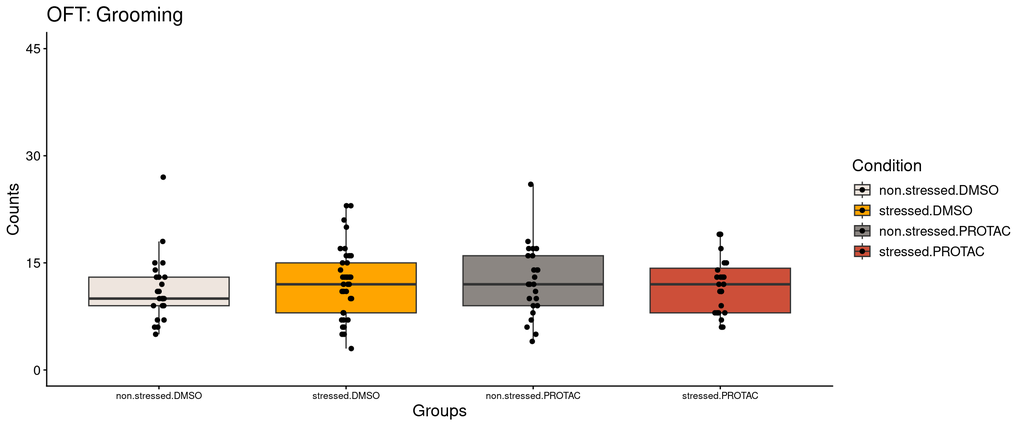

```r
  y_breaks <- seq(0, 45, length.out = 4)

  # Round to nearest 0.5
  # round_to_half <- function(x) round(x * 2,digits = 1) / 2
  # y_breaks <- round_to_half(y_breaks)
  #
  # Adjust limits to match rounded breaks
  y_lim <- range(y_breaks)



  e <- ggplot(df, aes(x = condition, y = round(df[[behavior]]), fill = condition))


   e2 <- e + geom_boxplot(width = 0.75,outlier.shape = NA ) +
     geom_jitter(
     position=position_jitterdodge(jitter.width = 0.1, dodge.width = 0.75)
      )+

     ylab("Counts")+
     xlab("Groups")+
     ggtitle(paste0("OFT: Grooming"))+



  scale_y_continuous(breaks = y_breaks, limits = y_lim) +


     scale_fill_manual(values=c( "seashell2","#ffa500ff","seashell4","tomato3"))+
     labs(fill= "Condition")+

   theme(
    axis.text.x = element_text(size = 8),
    text = element_text(size = 14),
  )


   print(e2)
```

```r
ggsave("sup_plots/FigS6E_OFT_Grooming_merge_offspring.svg")
ggsave("sup_plots/FigS6E_OFT_Grooming_merge_offspring.pdf")#, width = 6, height = 4)
ggsave("sup_plots/FigS6E_OFT_Grooming_merge_offspring.png")
```

## 56.6 Fig S6F overall male behavior

```r
  x <- Plot2DEmbedding(
    US_m,
    seed = 61,
    transitionmatrices  = "kmeans.50",
    colorby = "condition",
    color = c("seashell3", "#ffa500ff", "seashell4", "tomato3"),
    plot.sem = TRUE,
  ) + ggtitle(paste0("UMAP: Overall behavior male offspring" ))
```

```
## [1] "including transitionmatrix: kmeans.50"
```

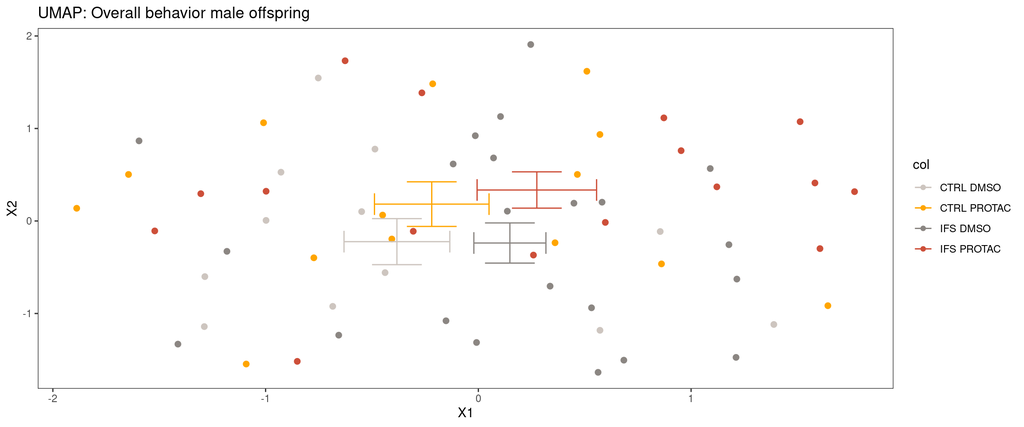

```r
 print(x)
```

```r
 ggsave("sup_plots/FigS6F_UMAP_Trans_male.png")
  ggsave("sup_plots/FigS6F_UMAP_Trans_male.svg")
   ggsave("sup_plots/FigS6F_UMAP_Trans_male.pdf")
```

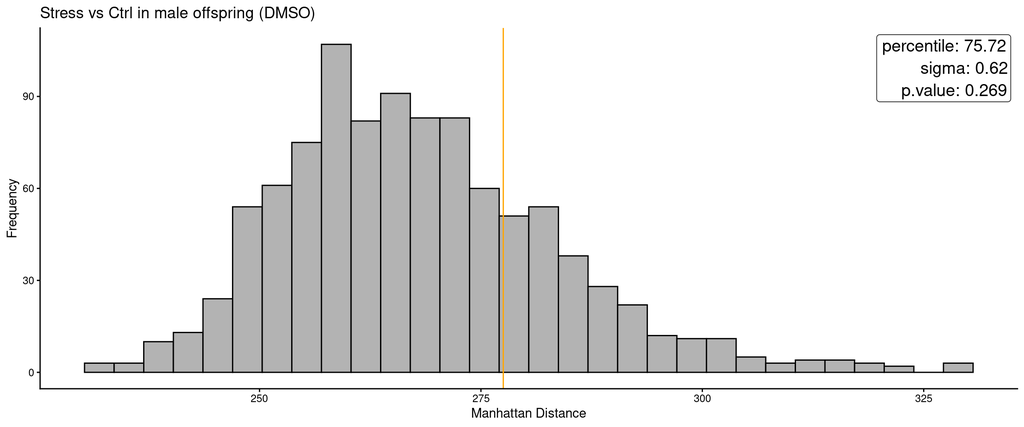

```r
  x <- plotTransVF(US_list$US_m_SvsC_D, labels  = "kmeans.50",title = "Stress vs Ctrl in male offspring (DMSO)")
  print(x)
```

```r
ggsave("sup_plots/FigS6F_Perm_Trans_Males_SvsCinDMSO.png")
  ggsave("sup_plots/FigS6F_Perm_Trans_Males_SvsCinDMSO.svg")
   ggsave("sup_plots/FigS6F_Perm_Trans_Males_SvsCinDMSO.pdf")
```

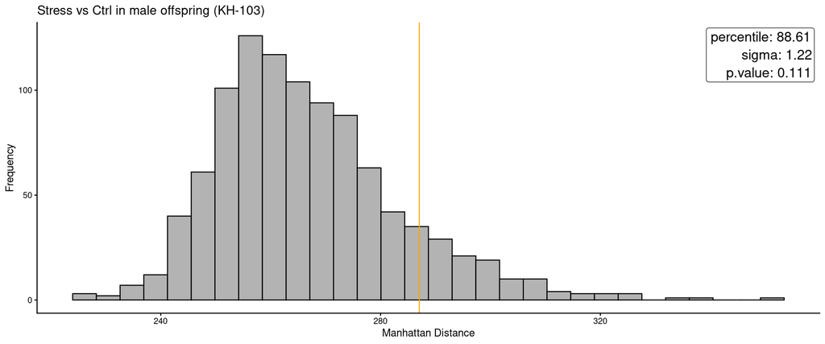

```r
  x <- plotTransVF(US_list$US_m_SvsC_K, labels = "kmeans.50",title = "Stress vs Ctrl in male offspring (KH-103)")
  print(x)
```

```r
ggsave("sup_plots/FigS6F_Perm_Trans_Males_SvsCinKH.png")
  ggsave("sup_plots/FigS6F_Perm_Trans_Males_SvsCinKH.svg")
   ggsave("sup_plots/FigS6F_Perm_Trans_Males_SvsCinKH.pdf")
```

## 56.7 Fig S6G overall offspring behavior

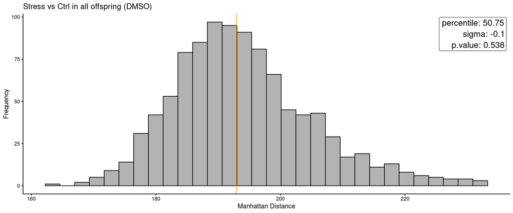

```r
    x <- plotTransVF(US_list$US_SvsC_D, labels = "kmeans.50",title = "Stress vs Ctrl in all offspring (DMSO)")
  print(x)
```

```r
ggsave("sup_plots/FigS6G_Perm_Trans_All_SvsCinDMSO.png")
  ggsave("sup_plots/FigS6G_Perm_Trans_All_SvsCinDMSO.svg")
   ggsave("sup_plots/FigS6G_Perm_Trans_All_SvsCinDMSO.pdf")
```

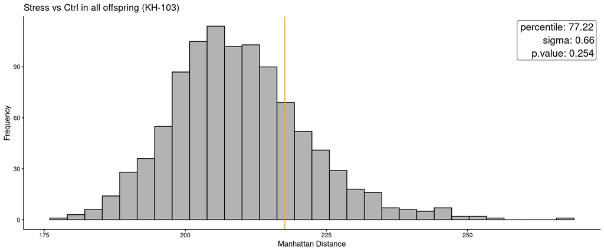

```r
  x <- plotTransVF(US_list$US_SvsC_K, labels = "kmeans.50",title = "Stress vs Ctrl in all offspring (KH-103)")
  print(x)
```

```r
ggsave("sup_plots/FigS6G_Perm_Trans_All_SvsCinKH.png")
  ggsave("sup_plots/FigS6G_Perm_Trans_All_SvsCinKH.svg")
   ggsave("sup_plots/FigS6G_Perm_Trans_All_SvsCinKH.pdf")
```

```r
  x <- Plot2DEmbedding(
    US,
    seed = 61,
    transitionmatrices  = "kmeans.50",
    colorby = "condition",
    color = c("seashell3", "#ffa500ff", "seashell4", "tomato3"),
    plot.sem = TRUE,
  ) + ggtitle(paste0("UMAP: Overall behavior female and male offspring" ))
```

```
## [1] "including transitionmatrix: kmeans.50"
```

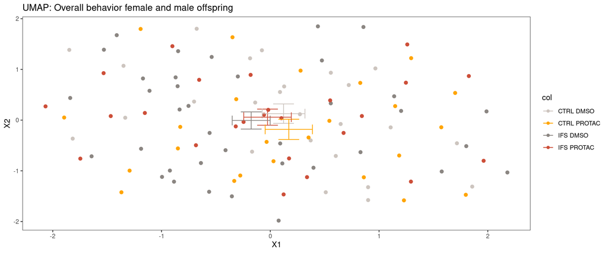

```r
 print(x)
```

```r
 ggsave("sup_plots/FigS6G_UMAP_Trans_All.png")
  ggsave("sup_plots/FigS6G_UMAP_Trans_All.svg")
   ggsave("sup_plots/FigS6G_UMAP_Trans_All.pdf")
```

## 56.8 Fig S6H LDB behavior sex merge

read in behavior data

```r
df <- readRDS("objects/LDB_readout.rds")
```

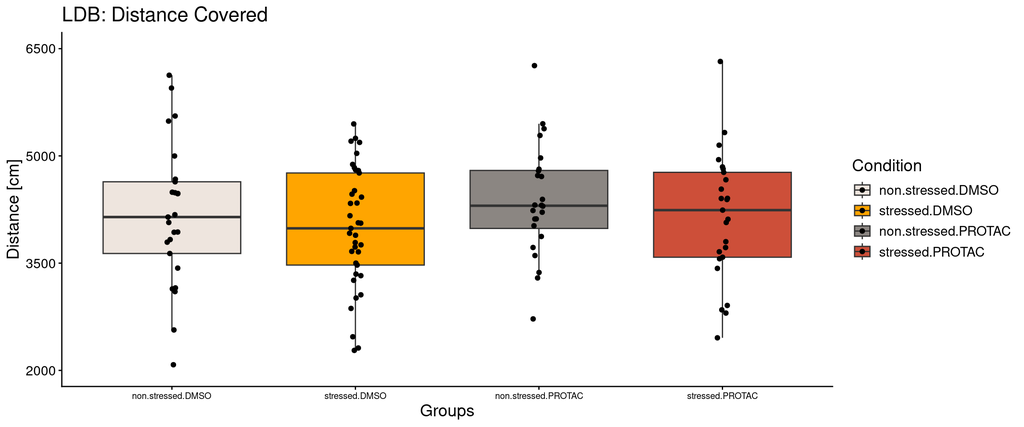

```r
behavior <- "bodycentre.distance.moving"
  # Calculate range and breaks
  y_min <- (min(df[[behavior]]))
  y_max <- (max(df[[behavior]]))
  y_breaks <- seq(2000, 6500, length.out = 4)

  # Round to nearest 0.5
  # round_to_half <- function(x) round(x * 2,digits = 1) / 2
  # y_breaks <- round_to_half(y_breaks)
  #
  # Adjust limits to match rounded breaks
  y_lim <- range(y_breaks)



  e <- ggplot(df, aes(x = condition, y = df[[behavior]], fill = condition))


   e2 <- e + geom_boxplot(width = 0.75,outlier.shape = NA ) +
     geom_jitter(
     position=position_jitterdodge(jitter.width = 0.1, dodge.width = 0.75)
      )+

     ylab("Distance [cm]")+
     xlab("Groups")+
     ggtitle(paste0("LDB: Distance Covered"))+



  scale_y_continuous(breaks = y_breaks, limits = y_lim) +


     scale_fill_manual(values=c( "seashell2","#ffa500ff","seashell4","tomato3"))+
     labs(fill= "Condition")+

   theme(
    axis.text.x = element_text(size = 7.5),
    text = element_text(size = 14),
  )


   print(e2)
```

```r
ggsave("sup_plots/FigS6H_LDB_DistanceCovered_merge_offspring.svg")
ggsave("sup_plots/FigS6H_LDB_DistanceCovered_merge_offspring.pdf")#, width = 6, height = 4)
ggsave("sup_plots/FigS6H_LDB_DistanceCovered_merge_offspring.png")
```

```r
df <- readRDS("objects/LDB_readout.rds")
# df$bodycentre.dark.total.time
```

```r
behavior <- "bodycentre.dark.total.time"
  # Calculate range and breaks
  y_min <- (min(df[[behavior]]));y_min
```

```
## [1] 175.2
```

```r
  y_max <- (max(df[[behavior]]));y_max
```

```
## [1] 467.48
```

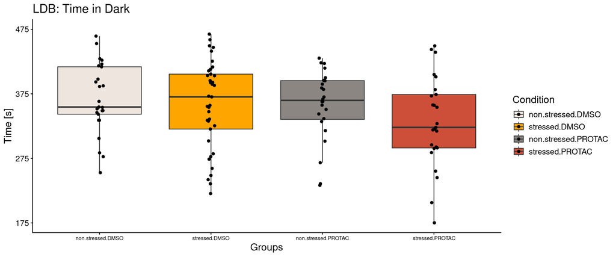

```r
  y_breaks <- seq(175, 475, length.out = 4)

  # Round to nearest 0.5
  # round_to_half <- function(x) round(x * 2,digits = 1) / 2
  # y_breaks <- round_to_half(y_breaks)
  #
  # Adjust limits to match rounded breaks
  y_lim <- range(y_breaks)



  e <- ggplot(df, aes(x = condition, y = df[[behavior]], fill = condition))


   e2 <- e + geom_boxplot(width = 0.75,outlier.shape = NA ) +
     geom_jitter(
     position=position_jitterdodge(jitter.width = 0.1, dodge.width = 0.75)
      )+

     ylab("Time [s]")+
     xlab("Groups")+
     ggtitle(paste0("LDB: Time in Dark"))+



  scale_y_continuous(breaks = y_breaks, limits = y_lim) +


     scale_fill_manual(values=c( "seashell2","#ffa500ff","seashell4","tomato3"))+
     labs(fill= "Condition")+

   theme(
    axis.text.x = element_text(size = 7.5),
    text = element_text(size = 14),
  )


   print(e2)
```

```r
ggsave("sup_plots/FigS6H_LDB_TID_merge_offspring.svg")
ggsave("sup_plots/FigS6H_LDB_TID_merge_offspring.pdf")#, width = 6, height = 4)
ggsave("sup_plots/FigS6H_LDB_TID_merge_offspring.png")
```

```r
behavior <- "bodycentre..transitions.light.to.dark"
  # Calculate range and breaks
  y_min <- (min(df[[behavior]]));y_min
```

```
## [1] 1
```

```r
  y_max <- (max(df[[behavior]]));y_max
```

```
## [1] 56
```

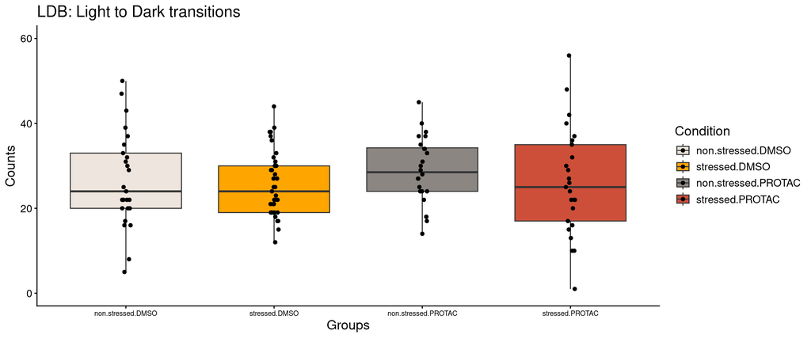

```r
  y_breaks <- seq(0, 60, length.out = 4)

  # Round to nearest 0.5
  # round_to_half <- function(x) round(x * 2,digits = 1) / 2
  # y_breaks <- round_to_half(y_breaks)
  #
  # Adjust limits to match rounded breaks
  y_lim <- range(y_breaks)



  e <- ggplot(df, aes(x = condition, y = df[[behavior]], fill = condition))


   e2 <- e + geom_boxplot(width = 0.75,outlier.shape = NA ) +
     geom_jitter(
     position=position_jitterdodge(jitter.width = 0.1, dodge.width = 0.75)
      )+

     ylab("Counts")+
     xlab("Groups")+
     ggtitle(paste0("LDB: Light to Dark transitions"))+



  scale_y_continuous(breaks = y_breaks, limits = y_lim) +


     scale_fill_manual(values=c( "seashell2","#ffa500ff","seashell4","tomato3"))+
     labs(fill= "Condition")+

   theme(
    axis.text.x = element_text(size = 7.5),
    text = element_text(size = 14),
  )


   print(e2)
```

```r
ggsave("sup_plots/FigS6H_LDB_LtoD_merge_offspring.svg")
ggsave("sup_plots/FigS6H_LDB_LtoD_merge_offspring.pdf")#, width = 6, height = 4)
ggsave("sup_plots/FigS6H_LDB_LtoD_merge_offspring.png")
```

```r
df <- readRDS("objects/LDB_readout.rds")
# df$classifications.SupportedRear.count
```

```r
behavior <- "classifications.SupportedRear.count"
  # Calculate range and breaks
  y_min <- (min(df[[behavior]]));y_min
```

```
## [1] 74.5
```

```r
  y_max <- (max(df[[behavior]]));y_max
```

```
## [1] 170.5
```

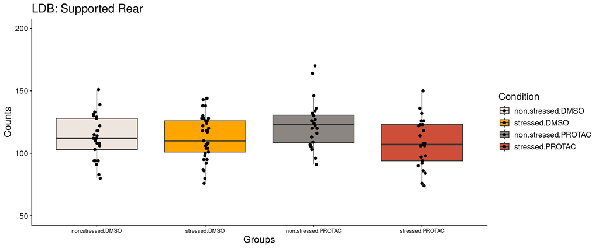

```r
  y_breaks <- seq(50, 200, length.out = 4)

  # Round to nearest 0.5
  # round_to_half <- function(x) round(x * 2,digits = 1) / 2
  # y_breaks <- round_to_half(y_breaks)
  #
  # Adjust limits to match rounded breaks
  y_lim <- range(y_breaks)



  e <- ggplot(df, aes(x = condition, y = round(df[[behavior]]), fill = condition))


   e2 <- e + geom_boxplot(width = 0.75,outlier.shape = NA ) +
     geom_jitter(
     position=position_jitterdodge(jitter.width = 0.1, dodge.width = 0.75)
      )+

     ylab("Counts")+
     xlab("Groups")+
     ggtitle(paste0("LDB: Supported Rear"))+



  scale_y_continuous(breaks = y_breaks, limits = y_lim) +


     scale_fill_manual(values=c( "seashell2","#ffa500ff","seashell4","tomato3"))+
     labs(fill= "Condition")+

   theme(
    axis.text.x = element_text(size = 8),
    text = element_text(size = 14),
  )


   print(e2)
```

```r
ggsave("sup_plots/FigS6H_LDB_SupRear_merge_offspring.svg")
ggsave("sup_plots/FigS6H_LDB_SupRear_merge_offspring.pdf")#, width = 6, height = 4)
ggsave("sup_plots/FigS6H_LDB_SupRear_merge_offspring.png")
```

```r
df <- readRDS("objects/LDB_readout.rds")
# df$classifications.UnsupportedRear.count
```

```r
behavior <- "classifications.UnsupportedRear.count"
  # Calculate range and breaks
  y_min <- (min(df[[behavior]]));y_min
```

```
## [1] 3
```

```r
  y_max <- (max(df[[behavior]]));y_max
```

```
## [1] 39
```

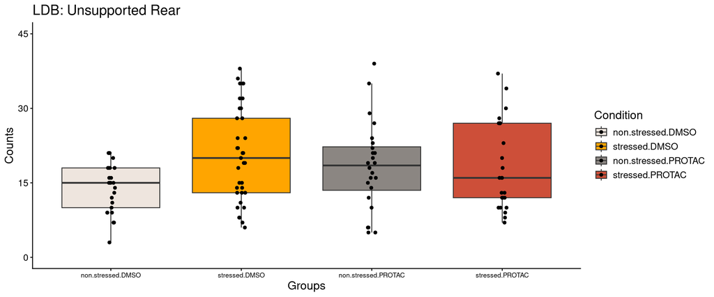

```r
  y_breaks <- seq(0, 45, length.out = 4)

  # Round to nearest 0.5
  # round_to_half <- function(x) round(x * 2,digits = 1) / 2
  # y_breaks <- round_to_half(y_breaks)
  #
  # Adjust limits to match rounded breaks
  y_lim <- range(y_breaks)



  e <- ggplot(df, aes(x = condition, y = round(df[[behavior]]), fill = condition))


   e2 <- e + geom_boxplot(width = 0.75,outlier.shape = NA ) +
     geom_jitter(
     position=position_jitterdodge(jitter.width = 0.1, dodge.width = 0.75)
      )+

     ylab("Counts")+
     xlab("Groups")+
     ggtitle(paste0("LDB: Unsupported Rear"))+



  scale_y_continuous(breaks = y_breaks, limits = y_lim) +


     scale_fill_manual(values=c( "seashell2","#ffa500ff","seashell4","tomato3"))+
     labs(fill= "Condition")+

   theme(
    axis.text.x = element_text(size = 8),
    text = element_text(size = 14),
  )


   print(e2)
```

```r
ggsave("sup_plots/FigS6H_LDB_UnSupRear_merge_offspring.svg")
ggsave("sup_plots/FigS6H_LDB_UnSupRear_merge_offspring.pdf")#, width = 6, height = 4)
ggsave("sup_plots/FigS6H_LDB_UnSupRear_merge_offspring.png")
```